# BT4016_Mid_term_Report_Code

## Note: DataReader on Google Colab starts from 2019-01-03 but Jupyter starts from 2019-01-02

```python
!pip install cvxpy
```

```python
import cvxpy as cvx
import numpy as np
import pandas as pd
from pandas_datareader.data import DataReader
import matplotlib.pyplot as plt
import seaborn as sns
```

```python
from __future__ import division
import numpy as np
import pandas as pd
import statsmodels.api as sm
import matplotlib.pyplot as plt
from functools import reduce
from math import sqrt, exp
from pandas_datareader.data import DataReader
from scipy.stats import norm
%matplotlib inline
```

```python
def get_data_for_multiple_stocks(tickers, start_date, end_date):
    '''
    Obtain stocks information (Date, OHLC, Volume and Adjusted Close).
    Uses Pandas DataReader to make an API Call to Yahoo Finance and download the data directly.
    Computes other values - Log Return and Arithmetic Return.

    Input: List of Stock Tickers
    Output: A dictionary of dataframes for each stock
    '''
    # read in stock data
    s = DataReader(tickers[0], 'yahoo', start_date, end_date)[["Adj Close"]]
    # get log returns
    s[tickers[0]] = np.log(s['Adj Close']/s['Adj Close'].shift(1))
    stocks = s[[tickers[0]]]

    for ticker in tickers[1:]:
      try:
        s = DataReader(ticker, 'yahoo', start_date, end_date)

        s[ticker] = np.log(s['Adj Close']/s['Adj Close'].shift(1)) # log returns
        stocks[ticker] = s[ticker]
      except KeyError:
        pass

    # skip first row that will be na, and fillna by 0 incase there are trading halts on specific days
    return stocks.iloc[1:].fillna(0)
```

```python
tickers = ["AAPL", "MSFT", "ADBE", "CRM", "NVDA", "MA", "PYPL", "V", "MU", "FIS",
           "LRCX", "FB", "AMAT", "QCOM", "TWLO", "WDAY", "AMZN", "INTU", "ADSK", "AMD",
           "HUBS", "UBER", "ESTC", "G", "GDDY", "FLEX", "MDB", "NXPI", "FISV", "MRVL"]
returns_df = get_data_for_multiple_stocks(tickers,
                                          start_date = "2019-01-01", end_date = "2020-01-01")
```

```python
returns_df.head(n=10)
```

| Date | AAPL | MSFT | ADBE | CRM | NVDA | MA | PYPL | V | MU | FIS | LRCX | FB | AMAT | QCOM | TWLO | WDAY | AMZN | INTU | ADSK | AMD | HUBS | UBER | ESTC | G | GDDY | FLEX | MDB | NXPI | FISV | … |
| --- | --- | --- | --- | --- | --- | --- | --- | --- | --- | --- | --- | --- | --- | --- | --- | --- | --- | --- | --- | --- | --- | --- | --- | --- | --- | --- | --- | --- | --- | --- |
| 2019-01-03 | -0.104924 | -0.037482 | -0.040299 | -0.038734 | -0.062319 | -0.046164 | -0.043620 | -0.036702 | -0.054916 | -0.031243 | -0.049430 | -0.029469 | -0.059692 | -0.030064 | -0.068032 | -0.036465 | -0.025566 | -0.031074 | -0.056712 | -0.099301 | -0.052857 | 0.0 | -0.036206 | -0.013529 | -0.042103 | -0.048030 | -0.052116 | -0.041638 | -0.029513 | … |
| 2019-01-04 | 0.041803 | 0.045460 | 0.047487 | 0.056357 | 0.062099 | 0.046269 | 0.049666 | 0.042179 | 0.053388 | 0.034688 | 0.047694 | 0.046061 | 0.066241 | 0.016029 | 0.086037 | 0.058813 | 0.048851 | 0.038911 | 0.051425 | 0.108289 | 0.064602 | 0.0 | 0.057670 | 0.025403 | 0.038595 | 0.037839 | 0.074136 | 0.047221 | 0.043403 | … |
| 2019-01-07 | -0.002228 | 0.001275 | 0.013481 | 0.030411 | 0.051587 | 0.007664 | 0.007621 | 0.017872 | 0.038985 | 0.006268 | 0.008870 | 0.000725 | 0.017648 | -0.002831 | 0.090937 | 0.000918 | 0.033776 | 0.015140 | 0.034026 | 0.079395 | 0.050157 | 0.0 | 0.075119 | 0.007716 | 0.016634 | 0.016508 | 0.047432 | 0.007395 | -0.002051 | … |
| 2019-01-08 | 0.018884 | 0.007224 | 0.014807 | 0.024312 | -0.025210 | 0.007255 | 0.020157 | 0.005424 | -0.007676 | 0.007490 | -0.017088 | 0.031937 | -0.041369 | -0.008720 | 0.006373 | 0.020881 | 0.016476 | 0.023688 | 0.008627 | 0.008713 | 0.026360 | 0.0 | 0.018299 | 0.017057 | -0.008837 | -0.019072 | 0.048846 | 0.005641 | 0.006548 | … |
| 2019-01-09 | 0.016839 | 0.014198 | 0.011750 | 0.001851 | 0.019476 | 0.017988 | 0.009537 | 0.011700 | 0.049157 | -0.004760 | 0.050344 | 0.011857 | 0.041369 | 0.011727 | -0.012268 | -0.004623 | 0.001713 | -0.003104 | 0.021432 | -0.027359 | 0.011408 | 0.0 | 0.033808 | 0.001079 | 0.006478 | 0.029098 | -0.038168 | 0.044770 | -0.003132 | … |
| 2019-01-10 | 0.003191 | -0.006446 | 0.009890 | 0.007166 | 0.018416 | 0.006009 | 0.012760 | 0.001877 | 0.013175 | 0.010943 | 0.003950 | -0.000208 | 0.013322 | 0.003351 | -0.002181 | 0.010654 | -0.001930 | 0.016638 | -0.000439 | -0.022540 | 0.011422 | 0.0 | -0.027915 | -0.004323 | 0.006592 | -0.005000 | -0.141380 | 0.001125 | 0.014354 | … |
| 2019-01-11 | -0.009867 | -0.007752 | -0.000926 | 0.003463 | 0.024486 | -0.005346 | -0.000551 | -0.004409 | 0.002781 | -0.002894 | -0.003187 | -0.002778 | 0.000575 | 0.012249 | 0.006528 | -0.002981 | -0.009500 | 0.000437 | 0.000219 | 0.026495 | 0.000000 | 0.0 | -0.001604 | 0.010415 | -0.013546 | 0.007491 | -0.009621 | -0.006896 | -0.003772 | … |
| 2019-01-14 | -0.015151 | -0.007322 | -0.012667 | -0.010218 | 0.010760 | -0.002402 | -0.002430 | -0.006978 | -0.037922 | 0.001255 | -0.025868 | 0.010996 | -0.026808 | -0.003484 | 0.009559 | -0.024972 | -0.014335 | -0.004863 | -0.014660 | -0.001975 | 0.005982 | 0.0 | -0.047240 | -0.006811 | -0.013089 | -0.010000 | -0.009985 | -0.011007 | -0.002973 | … |
| 2019-01-15 | 0.020260 | 0.028593 | 0.032713 | 0.021272 | -0.003796 | 0.005562 | 0.012855 | 0.001749 | -0.019808 | 0.010078 | -0.003067 | 0.024191 | -0.003254 | -0.027782 | 0.027145 | 0.006955 | 0.034848 | 0.022461 | 0.008351 | 0.007387 | 0.036325 | 0.0 | 0.032555 | 0.018179 | 0.010071 | -0.003776 | 0.061279 | -0.006893 | 0.015579 | … |
| 2019-01-16 | 0.012143 | 0.003517 | -0.001693 | -0.004366 | -0.006896 | 0.006341 | -0.011529 | 0.000000 | -0.012136 | -0.009982 | -0.008969 | -0.009511 | -0.003264 | -0.008288 | -0.004790 | 0.005276 | 0.005491 | 0.000858 | -0.004278 | -0.032414 | -0.007629 | 0.0 | -0.017111 | 0.008442 | 0.008710 | 0.000000 | -0.057083 | 0.003453 | -0.033470 | … |

## Replacing UBER with MELI

We realised UBER only has data from 2019 May and decided to replace UBER with one of the next top holdings in FSPTX. We decided to replace with the MELI as it was the most correlated to UBER.

```python
# with 31-35th stock
tickers_35 = ["AAPL", "MSFT", "ADBE", "CRM", "NVDA", "MA", "PYPL", "V", "MU", "FIS",
           "LRCX", "FB", "AMAT", "QCOM", "TWLO", "WDAY", "AMZN", "INTU", "ADSK", "AMD",
           "HUBS", "UBER", "ESTC", "G", "GDDY", "FLEX", "MDB", "NXPI", "FISV", "MRVL", "NFLX", "IT", "ON", "TMUS", "MELI"]
returns_df_35 = get_data_for_multiple_stocks(tickers_35,
                                          start_date = "2019-01-01", end_date = "2020-01-01")
```

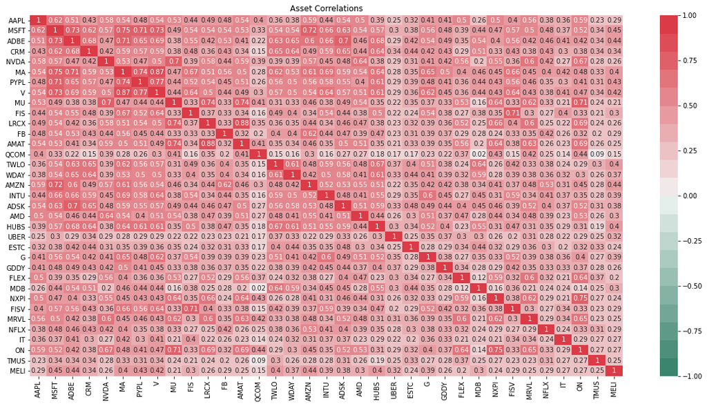

```python
plt.figure(figsize=(20, 10))
sns.heatmap(round(returns_df_35.corr(), 2), cmap=sns.diverging_palette(160, 10, n = 20), annot=True, vmin=-1, vmax=1)
plt.title("Asset Correlations")
```

```python
# drop UBER and replace with next most correlated stock, MELI
# new 30 stocks
tickers_new = ["AAPL", "MSFT", "ADBE", "CRM", "NVDA", "MA", "PYPL", "V", "MU", "FIS",
           "LRCX", "FB", "AMAT", "QCOM", "TWLO", "WDAY", "AMZN", "INTU", "ADSK", "AMD",
           "HUBS", "MELI", "ESTC", "G", "GDDY", "FLEX", "MDB", "NXPI", "FISV", "MRVL"]
returns_df_new = get_data_for_multiple_stocks(tickers_new,
                                          start_date = "2019-01-01", end_date = "2020-01-01")
```

```python
returns_df_new
```

| Date | AAPL | MSFT | ADBE | CRM | NVDA | MA | PYPL | V | MU | FIS | LRCX | FB | AMAT | QCOM | TWLO | WDAY | AMZN | INTU | ADSK | AMD | HUBS | MELI | ESTC | G | GDDY | FLEX | MDB | NXPI | FISV | … |
| --- | --- | --- | --- | --- | --- | --- | --- | --- | --- | --- | --- | --- | --- | --- | --- | --- | --- | --- | --- | --- | --- | --- | --- | --- | --- | --- | --- | --- | --- | --- |
| 2019-01-03 | -0.104924 | -0.037482 | -0.040299 | -0.038734 | -0.062319 | -0.046164 | -0.043620 | -0.036702 | -0.054916 | -0.031243 | -0.049430 | -0.029469 | -0.059692 | -0.030064 | -0.068032 | -0.036465 | -0.025566 | -0.031074 | -0.056712 | -0.099301 | -0.052857 | -0.004776 | -0.036206 | -0.013529 | -0.042103 | -0.048030 | -0.052116 | -0.041638 | -0.029513 | … |
| 2019-01-04 | 0.041803 | 0.045460 | 0.047487 | 0.056357 | 0.062099 | 0.046269 | 0.049666 | 0.042179 | 0.053388 | 0.034688 | 0.047694 | 0.046061 | 0.066241 | 0.016029 | 0.086037 | 0.058813 | 0.048851 | 0.038911 | 0.051425 | 0.108289 | 0.064602 | 0.061269 | 0.057670 | 0.025403 | 0.038595 | 0.037839 | 0.074136 | 0.047221 | 0.043403 | … |
| 2019-01-07 | -0.002228 | 0.001275 | 0.013481 | 0.030411 | 0.051587 | 0.007664 | 0.007621 | 0.017872 | 0.038985 | 0.006268 | 0.008870 | 0.000725 | 0.017648 | -0.002831 | 0.090937 | 0.000918 | 0.033776 | 0.015140 | 0.034026 | 0.079395 | 0.050157 | 0.042256 | 0.075119 | 0.007716 | 0.016634 | 0.016508 | 0.047432 | 0.007395 | -0.002051 | … |
| 2019-01-08 | 0.018884 | 0.007224 | 0.014807 | 0.024312 | -0.025210 | 0.007255 | 0.020157 | 0.005424 | -0.007676 | 0.007490 | -0.017088 | 0.031937 | -0.041369 | -0.008720 | 0.006373 | 0.020881 | 0.016476 | 0.023688 | 0.008627 | 0.008713 | 0.026360 | -0.001369 | 0.018299 | 0.017057 | -0.008837 | -0.019072 | 0.048846 | 0.005641 | 0.006548 | … |
| 2019-01-09 | 0.016839 | 0.014198 | 0.011750 | 0.001851 | 0.019476 | 0.017988 | 0.009537 | 0.011700 | 0.049157 | -0.004760 | 0.050344 | 0.011857 | 0.041369 | 0.011727 | -0.012268 | -0.004623 | 0.001713 | -0.003104 | 0.021432 | -0.027359 | 0.011408 | 0.034322 | 0.033808 | 0.001079 | 0.006478 | 0.029098 | -0.038168 | 0.044770 | -0.003132 | … |
| ... | ... | ... | ... | ... | ... | ... | ... | ... | ... | ... | ... | ... | ... | ... | ... | ... | ... | ... | ... | ... | ... | ... | ... | ... | ... | ... | ... | ... | ... | … |
| 2019-12-24 | 0.000950 | -0.000191 | 0.002095 | -0.002997 | -0.000838 | 0.000706 | 0.000736 | 0.002616 | 0.000361 | -0.002391 | 0.000102 | -0.005154 | 0.006853 | 0.003611 | 0.001593 | 0.003496 | -0.002116 | -0.007350 | 0.005398 | 0.023479 | 0.003938 | 0.000639 | 0.005705 | -0.000944 | -0.000292 | 0.002350 | 0.001434 | 0.009097 | 0.002576 | … |
| 2019-12-26 | 0.019646 | 0.008163 | 0.004721 | 0.007689 | 0.002386 | 0.005765 | 0.009705 | 0.008441 | -0.005609 | 0.005930 | 0.001493 | 0.012933 | -0.003094 | -0.004177 | 0.020280 | -0.005007 | 0.043506 | 0.009563 | 0.001793 | 0.001932 | 0.004743 | 0.004548 | -0.000615 | 0.004945 | 0.008589 | 0.004684 | 0.018463 | -0.004033 | -0.005158 | … |
| 2019-12-27 | -0.000380 | 0.001826 | -0.001239 | 0.002853 | -0.009747 | 0.005134 | -0.003194 | 0.001215 | -0.019792 | 0.007542 | -0.004145 | 0.001491 | -0.002286 | 0.004515 | -0.021474 | 0.002959 | 0.000551 | 0.000712 | 0.006169 | -0.009697 | -0.001579 | 0.003343 | 0.000308 | -0.004237 | -0.001741 | -0.012539 | -0.006613 | -0.003815 | 0.009009 | … |
| 2019-12-30 | 0.005918 | -0.008656 | -0.007434 | -0.015516 | -0.019396 | -0.010093 | -0.013157 | -0.008271 | -0.015293 | -0.008263 | -0.003957 | -0.017891 | -0.003931 | -0.004175 | -0.026639 | -0.012193 | -0.012328 | -0.015928 | -0.011284 | -0.014395 | -0.000063 | -0.026018 | -0.015187 | -0.006390 | -0.019501 | -0.004743 | -0.039540 | -0.005005 | -0.013847 | … |
| 2019-12-31 | 0.007280 | 0.000698 | 0.004467 | 0.001230 | 0.012746 | 0.002918 | 0.001851 | 0.000372 | 0.010655 | 0.003529 | -0.000479 | 0.004101 | 0.001804 | -0.002264 | 0.004998 | 0.003716 | 0.000514 | -0.003468 | 0.000873 | 0.007441 | 0.001642 | -0.020610 | 0.004052 | 0.001186 | 0.005610 | 0.000000 | 0.020573 | -0.002276 | 0.001385 | … |

251 rows × 30 columns

# Optimising portfolio

```python
def get_optimized_portfolio(returns_df, returns_scale, max_holding=0.5):
    """
    Function that takes in the returns series of assets, minimizes the utility function, and returns
    the portfolio weights

    Parameters
    ----------
    returns_df : pd.dataframe
        Dataframe containing log asset return series in each column

    returns_scale : float
        The scaling factor applied to the returns

    Returns
    -------
    x : np.ndarray
        A numpy ndarray containing the weights of the assets in the optimized portfolio
    """

    # number of assets m
    returns = returns_df.T.to_numpy()

    # weights to optimize
    m = returns.shape[0]

    # covariance matrix of returns
    cov = np.cov(returns)

    # creating variable of weights to optimize
    x = cvx.Variable(m)

    # portfolio variance, in quadratic form
    portfolio_variance = cvx.quad_form(x, cov)
    total_return = returns_df.sum().to_numpy()

    # Element wise multiplication, followed up by sum of weights
    portfolio_return = sum(cvx.multiply(total_return, x))

    # objective function
    # We want to maximise returns and minimize variance
    objective = cvx.Maximize(returns_scale * portfolio_return - portfolio_variance)

    # constraints
    # Long only, sum of weights equal to 1, no allocation to a single stock great than 50% of portfolio
    constraints = [x >= 0, sum(x) == 1, x <= max_holding]

    # use cvxpy to solve the objective
    problem = cvx.Problem(objective, constraints)
    # retrieve the weights of the optimized portfolio
    result = problem.solve()

    return x.value
```

```python
optimal_weights = get_optimized_portfolio(returns_df_new, returns_scale = 1)
x = round(pd.Series(optimal_weights, index = returns_df_new.columns), 10)
```

```python
optimal_weights = get_optimized_portfolio(returns_df_new, returns_scale = 0.01)
x = round(pd.Series(optimal_weights, index = returns_df_new.columns), 10)
```

```python
optimal_weights = get_optimized_portfolio(returns_df_new, returns_scale = 0.001)
x = round(pd.Series(optimal_weights, index = returns_df_new.columns), 10)
```

```python
# final
optimal_weights = get_optimized_portfolio(returns_df_new, returns_scale = 0.0001)
x = round(pd.Series(optimal_weights, index = returns_df_new.columns), 10)
x
```

```
AAPL    0.049198
MSFT    0.138569
ADBE    0.000000
CRM    -0.000000
NVDA   -0.000000
MA      0.000000
PYPL    0.000000
V       0.148535
MU     -0.000000
FIS     0.215008
LRCX    0.000000
FB      0.053435
AMAT    0.000000
QCOM    0.050677
TWLO   -0.000000
WDAY   -0.000000
AMZN   -0.000000
INTU   -0.000000
ADSK   -0.000000
AMD    -0.000000
HUBS    0.000000
MELI   -0.000000
ESTC    0.000000
G       0.322045
GDDY    0.000000
FLEX    0.002614
MDB     0.000000
NXPI   -0.000000
FISV    0.019919
MRVL   -0.000000
dtype: float64
```

Our optimisation resulted in only 9 stocks with weights. G had an unusually large weight and we decided to adjust the expected return of G based on analysts' target price to get more stocks in our optimised portfolio.

# Getting 10th stock

```python
def get_data_for_multiple_stocks2(tickers, start_date, end_date):
    stocks = dict()
    # loop through all the tickers
    for ticker in tickers:

        # get the data for the specific ticker
        s = DataReader(ticker, 'yahoo', start_date, end_date)

       ## s.insert(0, "Ticker", ticker)  #insert ticker column so you can reference better later

        s['Prev Close'] = s['Adj Close'].shift(1)
        s['log_return'] = np.log(s['Adj Close']/s['Prev Close'])
        s['perc_return'] = (s['Adj Close']/s['Prev Close'])
        # add it to the dictionary
        stocks[ticker] = s

    # return the dictionary
    return stocks
```

```python
stocks = get_data_for_multiple_stocks2(tickers_new, start_date = "2019-01-01", end_date = "2020-01-01")
```

```python
# renaming columns
for x in tickers_new:
    stocks[x].rename(columns={'log_return':x+'_log_return'}, inplace=True)
    stocks[x].rename(columns={'Adj Close':x+'_Adj Close'}, inplace=True)
    stocks[x].rename(columns={'Prev Close':x+'_Prev Close'}, inplace=True)
```

```python
AAPL = stocks['AAPL']
MSFT = stocks['MSFT']
ADBE = stocks['ADBE']
CRM = stocks['CRM']
NVDA = stocks['NVDA']
MA = stocks['MA']
PYPL = stocks['PYPL']
V = stocks['V']
MU = stocks['MU']
FIS = stocks['FIS']
LRCX = stocks['LRCX']
FB = stocks['FB']
AMAT = stocks['AMAT']
QCOM = stocks['QCOM']
TWLO = stocks['TWLO']
WDAY = stocks['WDAY']
AMZN = stocks['AMZN']
INTU = stocks['INTU']
ADSK = stocks['ADSK']
AMD = stocks['AMD']
HUBS = stocks['HUBS']
MELI = stocks['MELI']
ESTC = stocks['ESTC']
G = stocks['G']
GDDY = stocks['GDDY']
FLEX = stocks['FLEX']
MDB = stocks['MDB']
NXPI = stocks['NXPI']
FISV = stocks['FISV']
MRVL = stocks['MRVL']
```

```python
tickers_new_nostring = [AAPL, MSFT, ADBE, CRM, NVDA, MA, PYPL, V, MU, FIS, LRCX, FB, AMAT, QCOM, TWLO, WDAY, AMZN, INTU, ADSK, AMD, HUBS, MELI, ESTC,G, GDDY, FLEX, MDB, NXPI, FISV, MRVL]
```

```python
tickers_new_nostring2 = []
for i in tickers_new_nostring:
    i = i.reset_index()
    i['Date'] = pd.to_datetime(i['Date'], infer_datetime_format=True)
    tickers_new_nostring2.append(i)
```

```python
Stock_return = reduce(lambda left,right: pd.merge(left,right,on='Date'), tickers_new_nostring2)
```

# Adjusting G

```python
Stock_return["G_arith"] = np.exp(Stock_return["G_log_return"])-1
for i in range(len(Stock_return["G_arith"])):
  if Stock_return.loc[i,"G_arith"]<0:
    Stock_return.loc[i,"G_arith"]=44.11/Stock_return.loc[i,"G_Prev Close"]

Stock_return["G_log_return"] = np.log(Stock_return["G_arith"]+1)

Stock_return["G_arith"] = np.exp(Stock_return["G_log_return"])-1
```

```python
Stock_return.dropna(inplace=True)
```

```python
from copy import deepcopy
returns_df_adjG = deepcopy(returns_df_new)
returns_df_adjG["G"] = Stock_return["G_log_return"].values
```

```python
returns_df_adjG
```

| Date | AAPL | MSFT | ADBE | CRM | NVDA | MA | PYPL | V | MU | FIS | LRCX | FB | AMAT | QCOM | TWLO | WDAY | AMZN | INTU | ADSK | AMD | HUBS | MELI | ESTC | G | GDDY | FLEX | MDB | NXPI | FISV | … |
| --- | --- | --- | --- | --- | --- | --- | --- | --- | --- | --- | --- | --- | --- | --- | --- | --- | --- | --- | --- | --- | --- | --- | --- | --- | --- | --- | --- | --- | --- | --- |
| 2019-01-03 | -0.104924 | -0.037482 | -0.040299 | -0.038734 | -0.062319 | -0.046164 | -0.043620 | -0.036702 | -0.054916 | -0.031243 | -0.049430 | -0.029469 | -0.059692 | -0.030064 | -0.068032 | -0.036465 | -0.025566 | -0.031074 | -0.056712 | -0.099301 | -0.052857 | -0.004776 | -0.036206 | 0.983692 | -0.042103 | -0.048030 | -0.052116 | -0.041638 | -0.029513 | … |
| 2019-01-04 | 0.041803 | 0.045460 | 0.047487 | 0.056357 | 0.062099 | 0.046269 | 0.049666 | 0.042179 | 0.053388 | 0.034688 | 0.047694 | 0.046061 | 0.066241 | 0.016029 | 0.086037 | 0.058813 | 0.048851 | 0.038911 | 0.051425 | 0.108289 | 0.064602 | 0.061269 | 0.057670 | 0.025403 | 0.038595 | 0.037839 | 0.074136 | 0.047221 | 0.043403 | … |
| 2019-01-07 | -0.002228 | 0.001275 | 0.013481 | 0.030411 | 0.051587 | 0.007664 | 0.007621 | 0.017872 | 0.038985 | 0.006268 | 0.008870 | 0.000725 | 0.017648 | -0.002831 | 0.090937 | 0.000918 | 0.033776 | 0.015140 | 0.034026 | 0.079395 | 0.050157 | 0.042256 | 0.075119 | 0.007716 | 0.016634 | 0.016508 | 0.047432 | 0.007395 | -0.002051 | … |
| 2019-01-08 | 0.018884 | 0.007224 | 0.014807 | 0.024312 | -0.025210 | 0.007255 | 0.020157 | 0.005424 | -0.007676 | 0.007490 | -0.017088 | 0.031937 | -0.041369 | -0.008720 | 0.006373 | 0.020881 | 0.016476 | 0.023688 | 0.008627 | 0.008713 | 0.026360 | -0.001369 | 0.018299 | 0.017057 | -0.008837 | -0.019072 | 0.048846 | 0.005641 | 0.006548 | … |
| 2019-01-09 | 0.016839 | 0.014198 | 0.011750 | 0.001851 | 0.019476 | 0.017988 | 0.009537 | 0.011700 | 0.049157 | -0.004760 | 0.050344 | 0.011857 | 0.041369 | 0.011727 | -0.012268 | -0.004623 | 0.001713 | -0.003104 | 0.021432 | -0.027359 | 0.011408 | 0.034322 | 0.033808 | 0.001079 | 0.006478 | 0.029098 | -0.038168 | 0.044770 | -0.003132 | … |
| ... | ... | ... | ... | ... | ... | ... | ... | ... | ... | ... | ... | ... | ... | ... | ... | ... | ... | ... | ... | ... | ... | ... | ... | ... | ... | ... | ... | ... | ... | … |
| 2019-12-24 | 0.000950 | -0.000191 | 0.002095 | -0.002997 | -0.000838 | 0.000706 | 0.000736 | 0.002616 | 0.000361 | -0.002391 | 0.000102 | -0.005154 | 0.006853 | 0.003611 | 0.001593 | 0.003496 | -0.002116 | -0.007350 | 0.005398 | 0.023479 | 0.003938 | 0.000639 | 0.005705 | 0.717046 | -0.000292 | 0.002350 | 0.001434 | 0.009097 | 0.002576 | … |
| 2019-12-26 | 0.019646 | 0.008163 | 0.004721 | 0.007689 | 0.002386 | 0.005765 | 0.009705 | 0.008441 | -0.005609 | 0.005930 | 0.001493 | 0.012933 | -0.003094 | -0.004177 | 0.020280 | -0.005007 | 0.043506 | 0.009563 | 0.001793 | 0.001932 | 0.004743 | 0.004548 | -0.000615 | 0.004945 | 0.008589 | 0.004684 | 0.018463 | -0.004033 | -0.005158 | … |
| 2019-12-27 | -0.000380 | 0.001826 | -0.001239 | 0.002853 | -0.009747 | 0.005134 | -0.003194 | 0.001215 | -0.019792 | 0.007542 | -0.004145 | 0.001491 | -0.002286 | 0.004515 | -0.021474 | 0.002959 | 0.000551 | 0.000712 | 0.006169 | -0.009697 | -0.001579 | 0.003343 | 0.000308 | 0.715000 | -0.001741 | -0.012539 | -0.006613 | -0.003815 | 0.009009 | … |
| 2019-12-30 | 0.005918 | -0.008656 | -0.007434 | -0.015516 | -0.019396 | -0.010093 | -0.013157 | -0.008271 | -0.015293 | -0.008263 | -0.003957 | -0.017891 | -0.003931 | -0.004175 | -0.026639 | -0.012193 | -0.012328 | -0.015928 | -0.011284 | -0.014395 | -0.000063 | -0.026018 | -0.015187 | 0.717167 | -0.019501 | -0.004743 | -0.039540 | -0.005005 | -0.013847 | … |
| 2019-12-31 | 0.007280 | 0.000698 | 0.004467 | 0.001230 | 0.012746 | 0.002918 | 0.001851 | 0.000372 | 0.010655 | 0.003529 | -0.000479 | 0.004101 | 0.001804 | -0.002264 | 0.004998 | 0.003716 | 0.000514 | -0.003468 | 0.000873 | 0.007441 | 0.001642 | -0.020610 | 0.004052 | 0.001186 | 0.005610 | 0.000000 | 0.020573 | -0.002276 | 0.001385 | … |

251 rows × 30 columns

# New optimised weights

```python
optimal_weights_new = get_optimized_portfolio(returns_df_adjG, returns_scale = 0.0001)
x = round(pd.Series(optimal_weights_new, index = returns_df_adjG.columns), 10)
x
```

```
AAPL    0.052990
MSFT    0.092569
ADBE    0.000000
CRM    -0.000000
NVDA   -0.000000
MA      0.156987
PYPL    0.000000
V       0.137560
MU      0.000000
FIS     0.074765
LRCX    0.050595
FB      0.000872
AMAT   -0.000000
QCOM    0.040578
TWLO    0.000000
WDAY   -0.000000
AMZN    0.000000
INTU    0.199530
ADSK    0.000000
AMD     0.045174
HUBS   -0.000000
MELI    0.016148
ESTC    0.000000
G       0.044405
GDDY    0.000000
FLEX   -0.000000
MDB     0.015470
NXPI    0.072358
FISV   -0.000000
MRVL   -0.000000
dtype: float64
```

# Our 14 stocks: AAPL, MSFT, MA, V, FIS, LRCX, FB, QCOM, INTU, AMD, MELI, G, MDB, NXPI

# Our own portfolio

```python
portfolio_1yr = (returns_df_new * optimal_weights_new).sum(axis = 1)
portfolio_1yr
```

```
Date
2019-01-03   -0.042591
2019-01-04    0.044523
2019-01-07    0.013366
2019-01-08    0.009943
2019-01-09    0.010713
                ...
2019-12-24    0.000715
2019-12-26    0.006506
2019-12-27    0.000852
2019-12-30   -0.009719
2019-12-31    0.000629
Length: 251, dtype: float64
```

```python
returns_df_3yr = get_data_for_multiple_stocks(tickers_new,
                                          start_date = "2017-01-01", end_date = "2020-01-01")
```

```python
portfolio_3yr = (returns_df_3yr * optimal_weights_new).sum(axis = 1)
portfolio_3yr
```

```
Date
2017-01-04    0.005028
2017-01-05    0.004026
2017-01-06    0.008346
2017-01-09   -0.000825
2017-01-10   -0.001970
                ...
2019-12-24    0.000715
2019-12-26    0.006506
2019-12-27    0.000852
2019-12-30   -0.009719
2019-12-31    0.000629
Length: 753, dtype: float64
```

```python
returns_df_5yr = get_data_for_multiple_stocks(tickers_new,
                                          start_date = "2015-01-01", end_date = "2020-01-01")
```

```python
portfolio_5yr = (returns_df_5yr * optimal_weights_new).sum(axis = 1)
portfolio_5yr
```

```
Date
2015-01-05   -0.014048
2015-01-06   -0.014178
2015-01-07    0.011340
2015-01-08    0.019543
2015-01-09   -0.006717
                ...
2019-12-24    0.000715
2019-12-26    0.006506
2019-12-27    0.000852
2019-12-30   -0.009719
2019-12-31    0.000629
Length: 1257, dtype: float64
```

```python
result = pd.concat([portfolio_1yr, portfolio_3yr, portfolio_5yr], axis = 1)
result.columns = ["Portfolio_1yr", "Portfolio_3yr", "Portfolio_5yr"]
```

# Q4a Sharpe Ratio

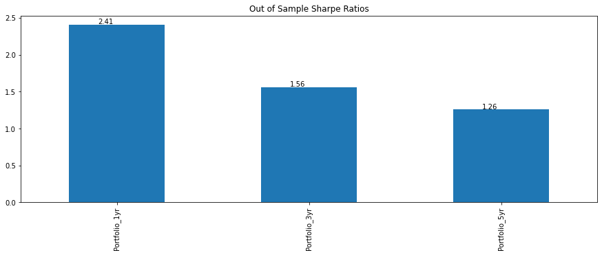

```python
oos_results = result.iloc[1:]
ax = round(oos_results.mean(axis = 0) / oos_results.std(axis = 0) * 252 ** 0.5, 2).plot(kind="bar", figsize = (15, 5))
plt.title("Out of Sample Sharpe Ratios")

for p in ax.patches:
    ax.annotate(str(p.get_height()), (p.get_x() + 0.15, p.get_height() + 0.01))
```

# Q4c Annualized Returns in %

```python
portfolio_1yr_arith = sum(np.exp(portfolio_1yr) - 1)
portfolio_1yr_arith*100
```

```
47.691448776304924
```

```python
portfolio_3yr_arith = np.exp(portfolio_3yr) - 1
sum(portfolio_3yr_arith/3)*100
```

```
30.692259477209756
```

```python
portfolio_5yr_arith = np.exp(portfolio_5yr) - 1
sum(portfolio_5yr_arith/5)*100
```

```
24.728623293830797
```

# Q4d Annualized Standard Deviation in %

We assume 252 trading days every year.

```python
np.std(np.exp(portfolio_1yr) - 1)*np.sqrt(252)*100
```

```
19.013329975906803
```

```python
np.std(np.exp(portfolio_3yr) - 1)*np.sqrt(252)*100
```

```
18.579836684988578
```

```python
np.std(np.exp(portfolio_5yr) - 1)*np.sqrt(252)*100
```

```
18.511787741627693
```

# Q5 - VaR

## Best Portfolio (FSTPX) - 5% VaR Using HS

```python
fstpx_returns = Stock_return[['Date','AAPL_Adj Close','MSFT_Adj Close','ADBE_Adj Close', 'CRM_Adj Close','NVDA_Adj Close',
                           'MA_Adj Close', 'PYPL_Adj Close','V_Adj Close','MU_Adj Close', 'FIS_Adj Close', 'LRCX_Adj Close',
                           'FB_Adj Close','AMAT_Adj Close', 'QCOM_Adj Close', 'TWLO_Adj Close','WDAY_Adj Close', 'AMZN_Adj Close',
                           'INTU_Adj Close', 'ADSK_Adj Close','AMD_Adj Close', 'HUBS_Adj Close', 'MELI_Adj Close', 'ESTC_Adj Close',
                           'G_Adj Close', 'GDDY_Adj Close', 'FLEX_Adj Close','MDB_Adj Close', 'NXPI_Adj Close', 'FISV_Adj Close',
                           'MRVL_Adj Close']]
fstpx_returns
```

|  | Date | AAPL_Adj Close | MSFT_Adj Close | ADBE_Adj Close | CRM_Adj Close | NVDA_Adj Close | MA_Adj Close | PYPL_Adj Close | V_Adj Close | MU_Adj Close | FIS_Adj Close | LRCX_Adj Close | FB_Adj Close | AMAT_Adj Close | QCOM_Adj Close | TWLO_Adj Close | WDAY_Adj Close | AMZN_Adj Close | INTU_Adj Close | ADSK_Adj Close | AMD_Adj Close | HUBS_Adj Close | MELI_Adj Close | ESTC_Adj Close | G_Adj Close | GDDY_Adj Close | FLEX_Adj Close | MDB_Adj Close | NXPI_Adj Close | … |
| --- | --- | --- | --- | --- | --- | --- | --- | --- | --- | --- | --- | --- | --- | --- | --- | --- | --- | --- | --- | --- | --- | --- | --- | --- | --- | --- | --- | --- | --- | --- |
| 1 | 2019-01-03 | 34.781353 | 95.223351 | 215.699997 | 130.399994 | 127.319656 | 179.211197 | 82.089996 | 126.724884 | 31.000000 | 96.470459 | 127.101006 | 131.740005 | 30.650827 | 52.599842 | 81.250000 | 154.020004 | 1500.280029 | 185.628830 | 121.849998 | 17.049999 | 118.830002 | 296.589996 | 64.010002 | 25.991114 | 60.230000 | 7.52 | 75.889999 | 70.363708 | … |
| 2 | 2019-01-04 | 36.266144 | 99.652115 | 226.190002 | 137.960007 | 135.476715 | 187.697968 | 86.269997 | 132.184341 | 32.700001 | 99.875542 | 133.309784 | 137.949997 | 32.749928 | 53.449738 | 88.550003 | 163.350006 | 1575.390015 | 192.994125 | 128.279999 | 19.000000 | 126.760002 | 315.329987 | 67.809998 | 26.659824 | 62.599998 | 7.81 | 81.730003 | 73.766022 | … |
| 3 | 2019-01-07 | 36.185429 | 99.779205 | 229.259995 | 142.220001 | 142.648941 | 189.142090 | 86.930000 | 134.567917 | 34.000000 | 100.503555 | 134.497452 | 138.050003 | 33.333015 | 53.298649 | 96.980003 | 163.500000 | 1629.510010 | 195.938248 | 132.720001 | 20.570000 | 133.279999 | 328.940002 | 73.099998 | 26.866333 | 63.650002 | 7.94 | 85.699997 | 74.313522 | … |
| 4 | 2019-01-08 | 36.875229 | 100.502670 | 232.679993 | 145.720001 | 139.097656 | 190.519348 | 88.699997 | 135.299805 | 33.740002 | 101.259148 | 132.218643 | 142.529999 | 31.982201 | 52.835922 | 97.599998 | 166.949997 | 1656.579956 | 200.635086 | 133.869995 | 20.750000 | 136.839996 | 328.489990 | 74.449997 | 27.328531 | 63.090000 | 7.79 | 89.989998 | 74.733925 | … |
| 5 | 2019-01-09 | 37.501434 | 101.939812 | 235.429993 | 145.990005 | 141.833252 | 193.977417 | 89.550003 | 136.892136 | 35.439999 | 100.778313 | 139.045395 | 144.229996 | 33.333015 | 53.459187 | 96.410004 | 166.179993 | 1659.420044 | 200.013336 | 136.770004 | 20.190001 | 138.410004 | 339.959991 | 77.010002 | 27.358034 | 63.500000 | 8.02 | 86.620003 | 78.155815 | … |
| ... | ... | ... | ... | ... | ... | ... | ... | ... | ... | ... | ... | ... | ... | ... | ... | ... | ... | ... | ... | ... | ... | ... | ... | ... | ... | ... | ... | ... | ... | … |
| 247 | 2019-12-24 | 70.580566 | 156.137955 | 329.640015 | 163.250000 | 238.297287 | 295.884796 | 108.690002 | 186.703415 | 55.419998 | 136.852921 | 290.441681 | 205.119995 | 60.861431 | 86.927422 | 100.550003 | 166.190002 | 1789.209961 | 262.335571 | 183.910004 | 46.540001 | 157.750000 | 594.530029 | 65.040001 | 42.035030 | 68.400002 | 12.78 | 132.550003 | 127.816917 | … |
| 248 | 2019-12-26 | 71.980911 | 157.417786 | 331.200012 | 164.509995 | 238.866516 | 297.595612 | 109.750000 | 188.286041 | 55.110001 | 137.666809 | 290.875641 | 207.789993 | 60.673405 | 86.565109 | 102.610001 | 165.360001 | 1868.770020 | 264.856415 | 184.240005 | 46.630001 | 158.500000 | 597.239990 | 65.000000 | 42.243416 | 68.989998 | 12.84 | 135.020004 | 127.302475 | … |
| 249 | 2019-12-27 | 71.953598 | 157.705505 | 330.790009 | 164.979996 | 236.549637 | 299.127319 | 109.400002 | 188.514984 | 54.029999 | 138.708969 | 289.672363 | 208.100006 | 60.534855 | 86.956810 | 100.430000 | 165.850006 | 1869.800049 | 265.045013 | 185.380005 | 46.180000 | 158.250000 | 599.239990 | 65.019997 | 42.064796 | 68.870003 | 12.68 | 134.130005 | 126.817734 | … |
| 250 | 2019-12-30 | 72.380653 | 156.346298 | 328.339996 | 162.440002 | 232.005798 | 296.123474 | 107.970001 | 186.962204 | 53.209999 | 137.567566 | 288.528290 | 204.410004 | 60.297352 | 86.594490 | 97.790001 | 163.839996 | 1846.890015 | 260.856781 | 183.300003 | 45.520000 | 158.240005 | 583.849976 | 64.040001 | 41.796864 | 67.540001 | 12.62 | 128.929993 | 126.184578 | … |
| 251 | 2019-12-31 | 72.909500 | 156.455429 | 329.809998 | 162.639999 | 234.981781 | 296.988831 | 108.169998 | 187.031860 | 53.779999 | 138.053894 | 288.390167 | 205.250000 | 60.406212 | 86.398636 | 98.279999 | 164.449997 | 1847.839966 | 259.953674 | 183.460007 | 45.860001 | 158.500000 | 571.940002 | 64.300003 | 41.846481 | 67.919998 | 12.62 | 131.610001 | 125.897690 | … |

251 rows × 31 columns

```python
dollarValueOfStock = [2051836821, 1624363933, 329525040, 291785537, 238343597, 219364830, 212343810, 186230240, 185088374, 179336117, 165346944, 162171231, 161982940, 145298238, 121981574, 119200951,116143756, 112774797, 108946944,108161967, 105879493, 99706579, 98161895, 88818510, 83373164, 76143081, 74428092, 69989115, 66668202, 61789443]
arrOfStocks = ['AAPL_Adj Close','MSFT_Adj Close','ADBE_Adj Close', 'CRM_Adj Close','NVDA_Adj Close',
               'MA_Adj Close', 'PYPL_Adj Close','V_Adj Close','MU_Adj Close', 'FIS_Adj Close', 'LRCX_Adj Close',
               'FB_Adj Close','AMAT_Adj Close', 'QCOM_Adj Close', 'TWLO_Adj Close','WDAY_Adj Close', 'AMZN_Adj Close',
               'INTU_Adj Close', 'ADSK_Adj Close','AMD_Adj Close', 'HUBS_Adj Close', 'MELI_Adj Close', 'ESTC_Adj Close',
               'G_Adj Close', 'GDDY_Adj Close', 'FLEX_Adj Close','MDB_Adj Close', 'NXPI_Adj Close', 'FISV_Adj Close',
               'MRVL_Adj Close']
stock_adj_close = [106.06875610351562,204.51560974121094, 444.32000732421875,194.85000610351562,424.4630126953125,308.171142578125,196.07000732421875,
 190.1125946044922,50.060001373291016,145.9651641845703,375.7033996582031,253.6699981689453,64.11695861816406,105.04737091064453,
 277.4200134277344,180.9199981689453,3164.679931640625,305.83026123046875,236.42999267578125,77.43000030517578,234.61000061035156,1124.6199951171875,
 96.19000244140625,39.71950149536133,70.27999877929688,11.489999771118164,229.0800018310547,117.17669677734375,
 99.79000091552734,36.41865921020508]


currPortValue = 0
for i in range(len(dollarValueOfStock)):
    shares = dollarValueOfStock[i]/stock_adj_close[i]
    currPortValue += float(shares)*fstpx_returns[arrOfStocks[i]]
```

```python
fstpx_returns['port_value'] = currPortValue
fstpx_returns['log_return'] = np.log(fstpx_returns['port_value']/fstpx_returns['port_value'].shift(1))
fstpx_returns.dropna(inplace = True)
```

```python
VaR_log = fstpx_returns['log_return'].quantile(0.05)
VaR_log
```

```
-0.018616341379774488
```

## Best Portfolio (FSPTX) - 5% ES Using HS

```python
import math

significance = 0.05 # Significance level
confidence = 0.95 # Confidence level

log_returns = fstpx_returns['log_return']
log_returns_sorted = sorted(log_returns.dropna())
length = len(log_returns_sorted)
cutoff_rt1_index = math.floor(length*significance +1) - 1

sum_rt1 = sum(log_returns_sorted[:cutoff_rt1_index])

ES_95_log = sum_rt1/len(log_returns_sorted[:cutoff_rt1_index])
ES_95_log
```

```
-0.027406499195070506
```

## Best Portfolio (FSPTX) - 5% VaR Using Parametric

```python
weights=[22.836,18.078,3.667,3.247,2.653,2.441,2.363,2.073,2.060,1.996,1.840,1.805,1.803,1.617,1.358,1.327,1.293,1.255,1.213,1.204,1.178,1.110,1.092,0.989,0.928,0.847,0.828,0.779,0.742,0.668]
for i in range(30):
    weights[i]=round(weights[i]/100, 5)
total=sum(weights)
for i in range(29):
  weights[i]=weights[i]/total
```

```python
Stock_return=returns_df_new
Stock_return.dropna(inplace=True)
Stock_return
```

| Date | AAPL | MSFT | ADBE | CRM | NVDA | MA | PYPL | V | MU | FIS | LRCX | FB | AMAT | QCOM | TWLO | WDAY | AMZN | INTU | ADSK | AMD | HUBS | MELI | ESTC | G | GDDY | FLEX | MDB | NXPI | FISV | … |
| --- | --- | --- | --- | --- | --- | --- | --- | --- | --- | --- | --- | --- | --- | --- | --- | --- | --- | --- | --- | --- | --- | --- | --- | --- | --- | --- | --- | --- | --- | --- |
| 2019-01-03 | -0.104924 | -0.037482 | -0.040299 | -0.038734 | -0.062319 | -0.046164 | -0.043620 | -0.036702 | -0.054916 | -0.031243 | -0.049430 | -0.029469 | -0.059692 | -0.030064 | -0.068032 | -0.036465 | -0.025566 | -0.031074 | -0.056712 | -0.099301 | -0.052857 | -0.004776 | -0.036206 | -0.013529 | -0.042103 | -0.048030 | -0.052116 | -0.041638 | -0.029513 | … |
| 2019-01-04 | 0.041803 | 0.045460 | 0.047487 | 0.056357 | 0.062099 | 0.046269 | 0.049666 | 0.042179 | 0.053388 | 0.034688 | 0.047694 | 0.046061 | 0.066241 | 0.016029 | 0.086037 | 0.058813 | 0.048851 | 0.038911 | 0.051425 | 0.108289 | 0.064602 | 0.061269 | 0.057670 | 0.025403 | 0.038595 | 0.037839 | 0.074136 | 0.047221 | 0.043403 | … |
| 2019-01-07 | -0.002228 | 0.001275 | 0.013481 | 0.030411 | 0.051587 | 0.007664 | 0.007621 | 0.017872 | 0.038985 | 0.006268 | 0.008870 | 0.000725 | 0.017648 | -0.002831 | 0.090937 | 0.000918 | 0.033776 | 0.015140 | 0.034026 | 0.079395 | 0.050157 | 0.042256 | 0.075119 | 0.007716 | 0.016634 | 0.016508 | 0.047432 | 0.007395 | -0.002051 | … |
| 2019-01-08 | 0.018884 | 0.007224 | 0.014807 | 0.024312 | -0.025210 | 0.007255 | 0.020157 | 0.005424 | -0.007676 | 0.007490 | -0.017088 | 0.031937 | -0.041369 | -0.008720 | 0.006373 | 0.020881 | 0.016476 | 0.023688 | 0.008627 | 0.008713 | 0.026360 | -0.001369 | 0.018299 | 0.017057 | -0.008837 | -0.019072 | 0.048846 | 0.005641 | 0.006548 | … |
| 2019-01-09 | 0.016839 | 0.014198 | 0.011750 | 0.001851 | 0.019476 | 0.017988 | 0.009537 | 0.011700 | 0.049157 | -0.004760 | 0.050344 | 0.011857 | 0.041369 | 0.011727 | -0.012268 | -0.004623 | 0.001713 | -0.003104 | 0.021432 | -0.027359 | 0.011408 | 0.034322 | 0.033808 | 0.001079 | 0.006478 | 0.029098 | -0.038168 | 0.044770 | -0.003132 | … |
| ... | ... | ... | ... | ... | ... | ... | ... | ... | ... | ... | ... | ... | ... | ... | ... | ... | ... | ... | ... | ... | ... | ... | ... | ... | ... | ... | ... | ... | ... | … |
| 2019-12-24 | 0.000950 | -0.000191 | 0.002095 | -0.002997 | -0.000838 | 0.000706 | 0.000736 | 0.002616 | 0.000361 | -0.002391 | 0.000102 | -0.005154 | 0.006853 | 0.003611 | 0.001593 | 0.003496 | -0.002116 | -0.007350 | 0.005398 | 0.023479 | 0.003938 | 0.000639 | 0.005705 | -0.000944 | -0.000292 | 0.002350 | 0.001434 | 0.009097 | 0.002576 | … |
| 2019-12-26 | 0.019646 | 0.008163 | 0.004721 | 0.007689 | 0.002386 | 0.005765 | 0.009705 | 0.008441 | -0.005609 | 0.005930 | 0.001493 | 0.012933 | -0.003094 | -0.004177 | 0.020280 | -0.005007 | 0.043506 | 0.009563 | 0.001793 | 0.001932 | 0.004743 | 0.004548 | -0.000615 | 0.004945 | 0.008589 | 0.004684 | 0.018463 | -0.004033 | -0.005158 | … |
| 2019-12-27 | -0.000380 | 0.001826 | -0.001239 | 0.002853 | -0.009747 | 0.005134 | -0.003194 | 0.001215 | -0.019792 | 0.007542 | -0.004145 | 0.001491 | -0.002286 | 0.004515 | -0.021474 | 0.002959 | 0.000551 | 0.000712 | 0.006169 | -0.009697 | -0.001579 | 0.003343 | 0.000308 | -0.004237 | -0.001741 | -0.012539 | -0.006613 | -0.003815 | 0.009009 | … |
| 2019-12-30 | 0.005918 | -0.008656 | -0.007434 | -0.015516 | -0.019396 | -0.010093 | -0.013157 | -0.008271 | -0.015293 | -0.008263 | -0.003957 | -0.017891 | -0.003931 | -0.004175 | -0.026639 | -0.012193 | -0.012328 | -0.015928 | -0.011284 | -0.014395 | -0.000063 | -0.026018 | -0.015187 | -0.006390 | -0.019501 | -0.004743 | -0.039540 | -0.005005 | -0.013847 | … |
| 2019-12-31 | 0.007280 | 0.000698 | 0.004467 | 0.001230 | 0.012746 | 0.002918 | 0.001851 | 0.000372 | 0.010655 | 0.003529 | -0.000479 | 0.004101 | 0.001804 | -0.002264 | 0.004998 | 0.003716 | 0.000514 | -0.003468 | 0.000873 | 0.007441 | 0.001642 | -0.020610 | 0.004052 | 0.001186 | 0.005610 | 0.000000 | 0.020573 | -0.002276 | 0.001385 | … |

251 rows × 30 columns

```python
z_alpha = norm.ppf(0.05, loc=0, scale=1) # z-score
mean_stock_return= Stock_return[["AAPL", "MSFT", "ADBE", "CRM", "NVDA", "MA", "PYPL", "V", "MU", "FIS", "LRCX", "FB", "AMAT", "QCOM", "TWLO", "WDAY", "AMZN", "INTU", "ADSK", "AMD","HUBS", "MELI", "ESTC", "G", "GDDY", "FLEX", "MDB", "NXPI", "FISV", "MRVL"]].mean()
        #var-cov matrix
mat_df=Stock_return[["AAPL", "MSFT", "ADBE", "CRM", "NVDA", "MA", "PYPL", "V", "MU", "FIS", "LRCX", "FB", "AMAT", "QCOM", "TWLO", "WDAY", "AMZN", "INTU", "ADSK", "AMD","HUBS", "MELI", "ESTC", "G", "GDDY", "FLEX", "MDB", "NXPI", "FISV", "MRVL"]].values
vcv=np.cov(mat_df.T)

var=np.dot(weights,np.dot(vcv,weights))
sigma = sqrt(var)

returns=np.exp(mean_stock_return.values) -1
mean=np.dot(weights,returns)
mean_log_return = np.log(1 + mean)
weighted_mean = mean_log_return
vaR_95=weighted_mean+sigma*z_alpha
vaR_95
```

```
-0.019240373030363793
```

## Best Portfolio (FSPTX) - 5% ES Using Parametric

```python
weighted_mean + sigma*norm.pdf(norm.ppf(0.95, loc=0, scale=1), loc=0, scale=1)/(1-0.95)
```

```
0.028345852313040168
```

## Worst Portfolio (FDMAX) - 5% VaR Using HS

```python
def get_adj_close_for_multiple_stocks(tickers, start_date, end_date):
    '''
    Obtain stocks information (Date, OHLC, Volume and Adjusted Close).
    Uses Pandas DataReader to make an API Call to Yahoo Finance and download the data directly.
    Computes other values - Log Return and Arithmetic Return.

    Input: List of Stock Tickers
    Output: A dictionary of dataframes for each stock
    '''
    # read in stock data
    s = DataReader(tickers[0], 'yahoo', start_date, end_date)[["Adj Close"]]
    # get adj close
    s[tickers[0]] = s['Adj Close']
    stocks = s[[tickers[0]]]

    for ticker in tickers[1:]:
        s = DataReader(ticker, 'yahoo', start_date, end_date)

        s[ticker] = s['Adj Close'] # adj close
        stocks[ticker] = s[ticker]

    # skip first row that will be na, and fillna by 0 incase there are trading halts on specific days
    return stocks.iloc[1:].fillna(0)
```

```python
#replace PING with ET.TO and NET with FTNT and remove CASA and RXT as no data on RXT
tickers_worst = ["ERIC", "NOK", "CSCO", "FFIV", "CIEN", "JNPR", "MSI", "LITE", "SATS", "VIAV", "ACIA", "ANET", "CALX", "IDCC",
           "VSAT", "NTCT", "COMM", "ET.TO", "FTNT", "PANW", "TENB", "HLIT", "ADTN", "EXTR",
           "INSG", "RPD", "SW.TO", "CVLT", "GLW", "RBBN"]
```

```python
fdmax_stock_prices = get_adj_close_for_multiple_stocks(tickers_worst, start_date = "2020-08-28", end_date = "2020-08-31")
```

```python
fdmax_stock_prices
```

| Date | ERIC | NOK | CSCO | FFIV | CIEN | JNPR | MSI | LITE | SATS | VIAV | ACIA | ANET | CALX | IDCC | VSAT | NTCT | COMM | ET.TO | FTNT | PANW | TENB | HLIT | ADTN | EXTR | INSG | RPD | SW.TO | CVLT | GLW | … |
| --- | --- | --- | --- | --- | --- | --- | --- | --- | --- | --- | --- | --- | --- | --- | --- | --- | --- | --- | --- | --- | --- | --- | --- | --- | --- | --- | --- | --- | --- | --- |
| 2020-08-31 | 11.559068 | 4.9 | 41.834137 | 132.330002 | 56.77 | 25.0 | 154.106293 | 86.0 | 29.379999 | 13.34 | 67.480003 | 223.449997 | 19.450001 | 60.803627 | 39.759998 | 23.139999 | 10.3 | 11.800452 | 132.009995 | 257.410004 | 37.639999 | 5.9 | 11.09 | 4.37 | 11.48 | 64.57 | 16.190001 | 43.23 | 32.459999 | … |

```python
fdmax_stock_prices_array = fdmax_stock_prices.to_numpy()
```

```python
stock_values = [4077954, 1123183, 3142012, 903417, 870909, 866150, 810271, 631412, 554312, 536947, 523982, 413829, 402207, 400227,
               369211, 348419, 240423, 49133, 50162, 180187, 154173, 116425, 109336, 106724,
               104755, 102925, 96791, 93550, 56253, 52006]
len(stock_values)
```

```
30
```

```python
stock_shares = []

for i in range(0, 30):
    stock_shares.append(stock_values[i]/fdmax_stock_prices_array[0][i])
```

```python
fdmax_df_2019 = get_data_for_multiple_stocks2(tickers_worst, start_date = "2019-01-01", end_date = "2020-01-01")
```

```python
# renaming columns
for x in tickers_worst:
    fdmax_df_2019[x].rename(columns={'log_return':x+'_log_return'}, inplace=True)
    fdmax_df_2019[x].rename(columns={'Adj Close':x+'_Adj Close'}, inplace=True)
    fdmax_df_2019[x].rename(columns={'Prev Close':x+'_Prev Close'}, inplace=True)
```

```python
ERIC = fdmax_df_2019['ERIC']
NOK = fdmax_df_2019['NOK']
CSCO = fdmax_df_2019['CSCO']
FFIV = fdmax_df_2019['FFIV']
CIEN = fdmax_df_2019['CIEN']
JNPR = fdmax_df_2019['JNPR']
MSI = fdmax_df_2019['MSI']
LITE = fdmax_df_2019['LITE']
SATS = fdmax_df_2019['SATS']
VIAV = fdmax_df_2019['VIAV']
ACIA = fdmax_df_2019['ACIA']
ANET = fdmax_df_2019['ANET']
CALX = fdmax_df_2019['CALX']
IDCC = fdmax_df_2019['IDCC']
VSAT = fdmax_df_2019['VSAT']
NTCT = fdmax_df_2019['NTCT']
COMM = fdmax_df_2019['COMM']
ETTO = fdmax_df_2019['ET.TO']
FTNT = fdmax_df_2019['FTNT']
PANW = fdmax_df_2019['PANW']
TENB = fdmax_df_2019['TENB']
HLIT = fdmax_df_2019['HLIT']
ADTN = fdmax_df_2019['ADTN']
EXTR = fdmax_df_2019['EXTR']
INSG = fdmax_df_2019['INSG']
RPD = fdmax_df_2019['RPD']
SWTO = fdmax_df_2019['SW.TO']
CVLT = fdmax_df_2019['CVLT']
GLW = fdmax_df_2019['GLW']
RBBN = fdmax_df_2019['RBBN']
```

```python
tickers_nostring = [ERIC, NOK, CSCO, FFIV, CIEN, JNPR, MSI, LITE, SATS, VIAV, ACIA, ANET, CALX, IDCC,
           VSAT, NTCT, COMM, ETTO, FTNT, PANW, TENB, HLIT, ADTN, EXTR,
           INSG, RPD, SWTO, CVLT, GLW, RBBN]
```

```python
tickers_nostring2 = []
for i in tickers_nostring:
    i = i.reset_index()
    i['Date'] = pd.to_datetime(i['Date'], infer_datetime_format=True)
    tickers_nostring2.append(i)
```

```python
fdmax_returns_2019 = reduce(lambda left,right: pd.merge(left,right,on='Date'), tickers_nostring2)
fdmax_returns_2019
```

|  | Date | High_x | Low_x | Open_x | Close_x | Volume_x | ERIC_Adj Close | ERIC_Prev Close | ERIC_log_return | perc_return_x | High_y | Low_y | Open_y | Close_y | Volume_y | NOK_Adj Close | NOK_Prev Close | NOK_log_return | perc_return_y | High_x | Low_x | Open_x | Close_x | Volume_x | CSCO_Adj Close | CSCO_Prev Close | CSCO_log_return | perc_return_x | High_y | … |
| --- | --- | --- | --- | --- | --- | --- | --- | --- | --- | --- | --- | --- | --- | --- | --- | --- | --- | --- | --- | --- | --- | --- | --- | --- | --- | --- | --- | --- | --- | --- |
| 0 | 2019-01-02 | 8.64 | 8.45 | 8.50 | 8.63 | 5577500.0 | 8.379722 | NaN | NaN | NaN | 5.77 | 5.69 | 5.70 | 5.74 | 24338600.0 | 5.621394 | NaN | NaN | NaN | 43.200001 | 42.209999 | 42.279999 | 42.950001 | 23833500.0 | 40.382099 | NaN | NaN | NaN | 162.910004 | … |
| 1 | 2019-01-03 | 8.41 | 8.26 | 8.38 | 8.29 | 6423200.0 | 8.049582 | 8.379722 | -0.040195 | 0.960602 | 5.65 | 5.56 | 5.64 | 5.57 | 17354500.0 | 5.454907 | 5.621394 | -0.030064 | 0.970383 | 42.410000 | 40.959999 | 42.299999 | 41.070000 | 29606700.0 | 38.913486 | 40.382099 | -0.037046 | 0.963632 | 160.169998 | … |
| 2 | 2019-01-04 | 8.72 | 8.41 | 8.45 | 8.69 | 6172100.0 | 8.437981 | 8.049582 | 0.047123 | 1.048251 | 5.96 | 5.73 | 5.73 | 5.93 | 34666300.0 | 5.807468 | 5.454907 | 0.062629 | 1.064632 | 43.000000 | 41.529999 | 41.849998 | 42.919998 | 27515000.0 | 40.666344 | 38.913486 | 0.044060 | 1.045045 | 160.130005 | … |
| 3 | 2019-01-07 | 8.86 | 8.72 | 8.73 | 8.80 | 3179400.0 | 8.544791 | 8.437981 | 0.012579 | 1.012658 | 6.09 | 5.93 | 5.95 | 6.02 | 25502600.0 | 5.895608 | 5.807468 | 0.015063 | 1.015177 | 43.650002 | 42.759998 | 42.860001 | 43.209999 | 19488100.0 | 40.941113 | 40.666344 | 0.006734 | 1.006757 | 165.470001 | … |
| 4 | 2019-01-08 | 8.98 | 8.78 | 8.79 | 8.96 | 6310100.0 | 8.700151 | 8.544791 | 0.018019 | 1.018182 | 6.16 | 6.03 | 6.07 | 6.15 | 33497100.0 | 6.022922 | 5.895608 | 0.021365 | 1.021595 | 43.939999 | 43.099998 | 43.570000 | 43.560001 | 22071400.0 | 41.272739 | 40.941113 | 0.008067 | 1.008100 | 166.369995 | … |
| ... | ... | ... | ... | ... | ... | ... | ... | ... | ... | ... | ... | ... | ... | ... | ... | ... | ... | ... | ... | ... | ... | ... | ... | ... | ... | ... | ... | ... | ... | … |
| 242 | 2019-12-23 | 8.85 | 8.78 | 8.79 | 8.84 | 3569800.0 | 8.686436 | 8.647130 | 0.004535 | 1.004546 | 3.64 | 3.59 | 3.61 | 3.64 | 16354800.0 | 3.640000 | 3.610000 | 0.008276 | 1.008310 | 48.299999 | 47.419998 | 47.549999 | 48.099998 | 20253500.0 | 46.501900 | 45.873497 | 0.013606 | 1.013699 | 140.169998 | … |
| 243 | 2019-12-24 | 8.89 | 8.81 | 8.86 | 8.86 | 1116800.0 | 8.706087 | 8.686436 | 0.002260 | 1.002262 | 3.64 | 3.61 | 3.62 | 3.63 | 6768300.0 | 3.630000 | 3.640000 | -0.002751 | 0.997253 | 48.250000 | 47.650002 | 48.160000 | 47.779999 | 7044700.0 | 46.192528 | 46.501900 | -0.006675 | 0.993347 | 139.770004 | … |
| 244 | 2019-12-27 | 8.90 | 8.84 | 8.90 | 8.86 | 2449700.0 | 8.706087 | 8.725739 | -0.002255 | 0.997748 | 3.63 | 3.61 | 3.61 | 3.63 | 9342100.0 | 3.630000 | 3.620000 | 0.002759 | 1.002762 | 48.020000 | 47.680000 | 47.990002 | 47.770000 | 11056800.0 | 46.182861 | 46.260204 | -0.001673 | 0.998328 | 139.940002 | … |
| 245 | 2019-12-30 | 8.89 | 8.76 | 8.88 | 8.76 | 4598500.0 | 8.607824 | 8.706087 | -0.011351 | 0.988713 | 3.72 | 3.63 | 3.65 | 3.69 | 27043500.0 | 3.690000 | 3.630000 | 0.016394 | 1.016529 | 47.880001 | 47.290001 | 47.750000 | 47.590000 | 12128600.0 | 46.008842 | 46.182861 | -0.003775 | 0.996232 | 140.309998 | … |
| 246 | 2019-12-31 | 8.82 | 8.76 | 8.78 | 8.78 | 2381800.0 | 8.627477 | 8.607824 | 0.002280 | 1.002283 | 3.73 | 3.69 | 3.70 | 3.71 | 14346300.0 | 3.710000 | 3.690000 | 0.005405 | 1.005420 | 47.980000 | 47.410000 | 47.540001 | 47.959999 | 14892600.0 | 46.366550 | 46.008842 | 0.007745 | 1.007775 | 140.550003 | … |

247 rows × 271 columns

```python
fdmax_returns_2019['Portfolio_Value'] = fdmax_returns_2019['ERIC_Adj Close']*stock_shares[0] + fdmax_returns_2019["NOK_Adj Close"]*stock_shares[1] +fdmax_returns_2019["CSCO_Adj Close"]*stock_shares[2]+ fdmax_returns_2019["FFIV_Adj Close"]*stock_shares[3] + fdmax_returns_2019["CIEN_Adj Close"]*stock_shares[4] + fdmax_returns_2019["JNPR_Adj Close"]*stock_shares[5] + fdmax_returns_2019["MSI_Adj Close"]*stock_shares[6] + fdmax_returns_2019["LITE_Adj Close"]*stock_shares[7] + fdmax_returns_2019["SATS_Adj Close"]*stock_shares[8] + fdmax_returns_2019["VIAV_Adj Close"]*stock_shares[9] + fdmax_returns_2019["ACIA_Adj Close"]*stock_shares[10] + fdmax_returns_2019["ANET_Adj Close"]*stock_shares[11] + fdmax_returns_2019["CALX_Adj Close"]*stock_shares[12] + fdmax_returns_2019["IDCC_Adj Close"]*stock_shares[13] + fdmax_returns_2019["VSAT_Adj Close"]*stock_shares[14] + fdmax_returns_2019["NTCT_Adj Close"]*stock_shares[15] +fdmax_returns_2019["COMM_Adj Close"]*stock_shares[16] + fdmax_returns_2019["ET.TO_Adj Close"]*stock_shares[17] + fdmax_returns_2019["FTNT_Adj Close"]*stock_shares[18] + fdmax_returns_2019["PANW_Adj Close"]*stock_shares[19] + fdmax_returns_2019["TENB_Adj Close"]*stock_shares[20] + fdmax_returns_2019["HLIT_Adj Close"]*stock_shares[21] + fdmax_returns_2019["ADTN_Adj Close"]*stock_shares[22] + fdmax_returns_2019["EXTR_Adj Close"]*stock_shares[23] + fdmax_returns_2019["INSG_Adj Close"]*stock_shares[24] + fdmax_returns_2019["RPD_Adj Close"]*stock_shares[25] + fdmax_returns_2019["SW.TO_Adj Close"]*stock_shares[26]+ fdmax_returns_2019["CVLT_Adj Close"]*stock_shares[27] + fdmax_returns_2019["GLW_Adj Close"]*stock_shares[28] + fdmax_returns_2019["RBBN_Adj Close"]*stock_shares[29]
```

```python
fdmax_returns_2019
```

|  | Date | High_x | Low_x | Open_x | Close_x | Volume_x | ERIC_Adj Close | ERIC_Prev Close | ERIC_log_return | perc_return_x | High_y | Low_y | Open_y | Close_y | Volume_y | NOK_Adj Close | NOK_Prev Close | NOK_log_return | perc_return_y | High_x | Low_x | Open_x | Close_x | Volume_x | CSCO_Adj Close | CSCO_Prev Close | CSCO_log_return | perc_return_x | High_y | … |
| --- | --- | --- | --- | --- | --- | --- | --- | --- | --- | --- | --- | --- | --- | --- | --- | --- | --- | --- | --- | --- | --- | --- | --- | --- | --- | --- | --- | --- | --- | --- |
| 0 | 2019-01-02 | 8.64 | 8.45 | 8.50 | 8.63 | 5577500.0 | 8.379722 | NaN | NaN | NaN | 5.77 | 5.69 | 5.70 | 5.74 | 24338600.0 | 5.621394 | NaN | NaN | NaN | 43.200001 | 42.209999 | 42.279999 | 42.950001 | 23833500.0 | 40.382099 | NaN | NaN | NaN | 162.910004 | … |
| 1 | 2019-01-03 | 8.41 | 8.26 | 8.38 | 8.29 | 6423200.0 | 8.049582 | 8.379722 | -0.040195 | 0.960602 | 5.65 | 5.56 | 5.64 | 5.57 | 17354500.0 | 5.454907 | 5.621394 | -0.030064 | 0.970383 | 42.410000 | 40.959999 | 42.299999 | 41.070000 | 29606700.0 | 38.913486 | 40.382099 | -0.037046 | 0.963632 | 160.169998 | … |
| 2 | 2019-01-04 | 8.72 | 8.41 | 8.45 | 8.69 | 6172100.0 | 8.437981 | 8.049582 | 0.047123 | 1.048251 | 5.96 | 5.73 | 5.73 | 5.93 | 34666300.0 | 5.807468 | 5.454907 | 0.062629 | 1.064632 | 43.000000 | 41.529999 | 41.849998 | 42.919998 | 27515000.0 | 40.666344 | 38.913486 | 0.044060 | 1.045045 | 160.130005 | … |
| 3 | 2019-01-07 | 8.86 | 8.72 | 8.73 | 8.80 | 3179400.0 | 8.544791 | 8.437981 | 0.012579 | 1.012658 | 6.09 | 5.93 | 5.95 | 6.02 | 25502600.0 | 5.895608 | 5.807468 | 0.015063 | 1.015177 | 43.650002 | 42.759998 | 42.860001 | 43.209999 | 19488100.0 | 40.941113 | 40.666344 | 0.006734 | 1.006757 | 165.470001 | … |
| 4 | 2019-01-08 | 8.98 | 8.78 | 8.79 | 8.96 | 6310100.0 | 8.700151 | 8.544791 | 0.018019 | 1.018182 | 6.16 | 6.03 | 6.07 | 6.15 | 33497100.0 | 6.022922 | 5.895608 | 0.021365 | 1.021595 | 43.939999 | 43.099998 | 43.570000 | 43.560001 | 22071400.0 | 41.272739 | 40.941113 | 0.008067 | 1.008100 | 166.369995 | … |
| ... | ... | ... | ... | ... | ... | ... | ... | ... | ... | ... | ... | ... | ... | ... | ... | ... | ... | ... | ... | ... | ... | ... | ... | ... | ... | ... | ... | ... | ... | … |
| 242 | 2019-12-23 | 8.85 | 8.78 | 8.79 | 8.84 | 3569800.0 | 8.686436 | 8.647130 | 0.004535 | 1.004546 | 3.64 | 3.59 | 3.61 | 3.64 | 16354800.0 | 3.640000 | 3.610000 | 0.008276 | 1.008310 | 48.299999 | 47.419998 | 47.549999 | 48.099998 | 20253500.0 | 46.501900 | 45.873497 | 0.013606 | 1.013699 | 140.169998 | … |
| 243 | 2019-12-24 | 8.89 | 8.81 | 8.86 | 8.86 | 1116800.0 | 8.706087 | 8.686436 | 0.002260 | 1.002262 | 3.64 | 3.61 | 3.62 | 3.63 | 6768300.0 | 3.630000 | 3.640000 | -0.002751 | 0.997253 | 48.250000 | 47.650002 | 48.160000 | 47.779999 | 7044700.0 | 46.192528 | 46.501900 | -0.006675 | 0.993347 | 139.770004 | … |
| 244 | 2019-12-27 | 8.90 | 8.84 | 8.90 | 8.86 | 2449700.0 | 8.706087 | 8.725739 | -0.002255 | 0.997748 | 3.63 | 3.61 | 3.61 | 3.63 | 9342100.0 | 3.630000 | 3.620000 | 0.002759 | 1.002762 | 48.020000 | 47.680000 | 47.990002 | 47.770000 | 11056800.0 | 46.182861 | 46.260204 | -0.001673 | 0.998328 | 139.940002 | … |
| 245 | 2019-12-30 | 8.89 | 8.76 | 8.88 | 8.76 | 4598500.0 | 8.607824 | 8.706087 | -0.011351 | 0.988713 | 3.72 | 3.63 | 3.65 | 3.69 | 27043500.0 | 3.690000 | 3.630000 | 0.016394 | 1.016529 | 47.880001 | 47.290001 | 47.750000 | 47.590000 | 12128600.0 | 46.008842 | 46.182861 | -0.003775 | 0.996232 | 140.309998 | … |
| 246 | 2019-12-31 | 8.82 | 8.76 | 8.78 | 8.78 | 2381800.0 | 8.627477 | 8.607824 | 0.002280 | 1.002283 | 3.73 | 3.69 | 3.70 | 3.71 | 14346300.0 | 3.710000 | 3.690000 | 0.005405 | 1.005420 | 47.980000 | 47.410000 | 47.540001 | 47.959999 | 14892600.0 | 46.366550 | 46.008842 | 0.007745 | 1.007775 | 140.550003 | … |

247 rows × 272 columns

```python
fdmax_returns_2019['lag_index'] = fdmax_returns_2019['Portfolio_Value'].shift(1)
fdmax_returns_2019['log_returns'] = np.log(fdmax_returns_2019['Portfolio_Value']/fdmax_returns_2019['lag_index'])
```

```python
fdmax_HS_VaR_95 = fdmax_returns_2019['log_returns'].quantile(0.05)
fdmax_HS_VaR_95
```

```
-0.021649838788802785
```

## Worst Portfolio (FDMAX) - 5% ES Using HS

```python
import math

significance = 0.05 # significance level
confidence = 0.95 # confidence level

log_returns_sorted = sorted(fdmax_returns_2019['log_returns'].dropna())
length = len(log_returns_sorted)
cutoff_rt1_index = math.floor(length*significance+1) - 1 # minus one due to index starting from 0
sum_rt1 = sum(log_returns_sorted[:cutoff_rt1_index])
fdmax_HS_ES_95 = sum_rt1/len(log_returns_sorted[:cutoff_rt1_index])
fdmax_HS_ES_95
```

```
-0.029555290541331394
```

## Worst Portfolio (FDMAX) - 5% VaR Using Parametric

```python
tickers_test = ["ERIC", "NOK", "CSCO", "FFIV", "CIEN", "JNPR", "MSI", "LITE", "SATS", "VIAV", "ACIA", "ANET", "CALX", "IDCC",
           "VSAT", "NTCT", "COMM", "PING", "NET", "PANW", "TENB", "HLIT", "ADTN", "EXTR",
           "INSG", "RPD", "SW.TO", "CVLT", "RXT", "GLW", "RBBN", "FTNT", "ET.TO", "CASA"]
```

```python
len(tickers_test)
```

```
34
```

```python
returns_df_test = get_data_for_multiple_stocks(tickers_test, start_date = "2019-01-01", end_date = "2020-01-01")
```

```python
#based on returns_df_test we need to replace PING and NET as they have missing data and replace RXT as it has no data in the specified start and end date
returns_df_test.head(n=10)
```

| Date | ERIC | NOK | CSCO | FFIV | CIEN | JNPR | MSI | LITE | SATS | VIAV | ACIA | ANET | CALX | IDCC | VSAT | NTCT | COMM | PING | NET | PANW | TENB | HLIT | ADTN | EXTR | INSG | RPD | SW.TO | CVLT | GLW | … |
| --- | --- | --- | --- | --- | --- | --- | --- | --- | --- | --- | --- | --- | --- | --- | --- | --- | --- | --- | --- | --- | --- | --- | --- | --- | --- | --- | --- | --- | --- | --- |
| 2019-01-03 | -0.040195 | -0.030064 | -0.037046 | -0.043558 | -0.032034 | -0.033658 | -0.035652 | -0.087802 | -0.004345 | -0.030677 | -0.043421 | -0.053408 | -0.030706 | -0.014860 | -0.012313 | -0.031340 | -0.015944 | 0.0 | 0.0 | -0.019344 | -0.042864 | -0.062185 | 0.002761 | -0.053435 | -0.004751 | -0.051514 | -0.028049 | -0.029326 | -0.063914 | … |
| 2019-01-04 | 0.047123 | 0.062629 | 0.044060 | 0.034897 | 0.050137 | 0.037740 | 0.042424 | 0.068839 | 0.038446 | 0.007243 | 0.045505 | 0.014276 | 0.045199 | 0.027572 | 0.042530 | 0.034715 | 0.037388 | 0.0 | 0.0 | 0.025764 | 0.029724 | 0.068403 | 0.034330 | 0.037041 | 0.160254 | 0.063670 | 0.029644 | 0.040062 | 0.041236 | … |
| 2019-01-07 | 0.012579 | 0.015063 | 0.006734 | 0.024908 | 0.029368 | 0.019076 | 0.004662 | 0.010474 | -0.013182 | 0.019398 | 0.018813 | 0.036135 | 0.004103 | 0.004153 | 0.004172 | 0.027831 | 0.024357 | 0.0 | 0.0 | 0.015925 | 0.077678 | 0.008230 | 0.024563 | 0.018018 | 0.045598 | 0.077962 | 0.005825 | 0.006866 | -0.000342 | … |
| 2019-01-08 | 0.018019 | 0.021365 | 0.008067 | 0.006086 | 0.029349 | 0.012638 | 0.028948 | 0.028710 | 0.021788 | 0.008056 | 0.061630 | 0.020557 | -0.008222 | 0.020322 | 0.007301 | 0.006940 | 0.010022 | 0.0 | 0.0 | 0.016306 | 0.022045 | 0.026291 | 0.024819 | 0.020884 | 0.009643 | 0.031556 | -0.010082 | 0.024834 | 0.009543 | … |
| 2019-01-09 | 0.024257 | 0.009709 | -0.005525 | 0.007375 | -0.002459 | 0.009996 | -0.028431 | 0.029250 | 0.001557 | 0.022807 | 0.007175 | 0.012383 | -0.009331 | 0.002620 | 0.000661 | 0.004060 | 0.017573 | 0.0 | 0.0 | 0.013975 | 0.027411 | 0.001994 | 0.009255 | 0.004758 | -0.025269 | 0.007382 | 0.012192 | 0.009466 | 0.006761 | … |
| 2019-01-10 | -0.040005 | -0.011336 | -0.001848 | -0.002653 | 0.009257 | 0.003900 | 0.011980 | 0.007569 | 0.011087 | 0.022299 | 0.012081 | 0.004645 | -0.037140 | 0.013287 | 0.014922 | 0.002024 | 0.019408 | 0.0 | 0.0 | 0.014855 | -0.036429 | -0.036515 | -0.015190 | 0.001581 | 0.003929 | 0.006766 | 0.029589 | 0.005111 | 0.022323 | … |
| 2019-01-11 | -0.033432 | -0.009820 | 0.005765 | -0.011357 | -0.006253 | -0.004611 | -0.013359 | 0.014094 | -0.004111 | 0.012387 | 0.005167 | 0.000642 | -0.025179 | 0.010419 | -0.002444 | 0.018033 | 0.003198 | 0.0 | 0.0 | -0.000153 | 0.052113 | -0.008299 | 0.001699 | 0.001579 | 0.086358 | -0.002814 | 0.026749 | 0.004430 | -0.009934 | … |
| 2019-01-14 | -0.008240 | -0.009917 | -0.006459 | -0.005389 | -0.001091 | -0.008210 | -0.007615 | -0.008344 | -0.003094 | -0.024929 | -0.018440 | -0.011622 | -0.015643 | -0.000426 | -0.000979 | 0.005939 | -0.001598 | 0.0 | 0.0 | -0.005321 | -0.056869 | -0.027457 | -0.013675 | -0.019109 | 0.014286 | -0.013903 | -0.024195 | -0.014512 | -0.006678 | … |
| 2019-01-15 | 0.003540 | 0.004971 | 0.018572 | 0.002024 | 0.026934 | 0.008210 | 0.005630 | 0.012273 | 0.002837 | 0.013501 | 0.022415 | 0.033167 | 0.070643 | 0.010034 | 0.000653 | 0.014891 | 0.009021 | 0.0 | 0.0 | 0.026527 | 0.092666 | 0.027457 | -0.000861 | 0.022259 | 0.021053 | 0.035919 | 0.009142 | 0.014512 | 0.008340 | … |
| 2019-01-16 | -0.001179 | -0.016667 | -0.001364 | -0.008122 | 0.003449 | -0.002135 | -0.010594 | -0.004804 | 0.001544 | 0.004778 | -0.013152 | -0.007251 | 0.025895 | 0.012855 | 0.012167 | 0.014672 | 0.002638 | 0.0 | 0.0 | 0.005629 | 0.003550 | 0.004158 | 0.013687 | -0.020652 | 0.018917 | -0.019202 | 0.002020 | 0.007665 | -0.000997 | … |

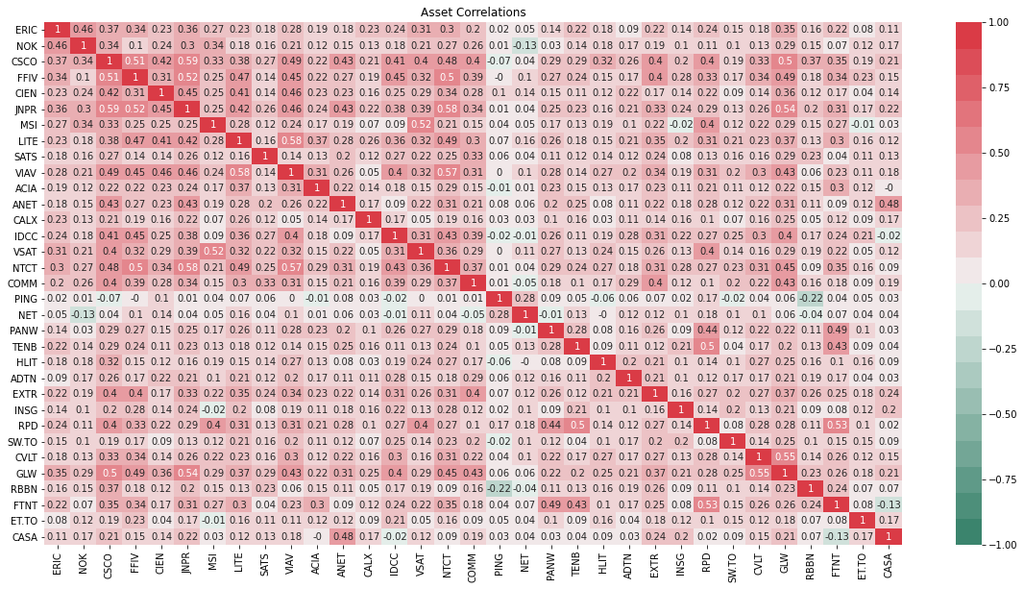

```python
plt.figure(figsize=(20, 10))
sns.heatmap(round(returns_df_test.corr(), 2), cmap=sns.diverging_palette(160, 10, n = 20), annot=True, vmin=-1, vmax=1)
plt.title("Asset Correlations")
```

```python
#replace PING with ET.TO and NET with FTNT and replace RXT with RBBN
tickers = ["ERIC", "NOK", "CSCO", "FFIV", "CIEN", "JNPR", "MSI", "LITE", "SATS", "VIAV", "ACIA", "ANET", "CALX", "IDCC",
           "VSAT", "NTCT", "COMM", "ET.TO", "FTNT", "PANW", "TENB", "HLIT", "ADTN", "EXTR",
           "INSG", "RPD", "SW.TO", "CVLT", "GLW", "RBBN"]
```

```python
len(tickers)
```

```
30
```

```python
returns_df = get_data_for_multiple_stocks(tickers, start_date = "2019-01-01", end_date = "2020-01-01")
```

```python
returns_df
```

| Date | ERIC | NOK | CSCO | FFIV | CIEN | JNPR | MSI | LITE | SATS | VIAV | ACIA | ANET | CALX | IDCC | VSAT | NTCT | COMM | ET.TO | FTNT | PANW | TENB | HLIT | ADTN | EXTR | INSG | RPD | SW.TO | CVLT | GLW | … |
| --- | --- | --- | --- | --- | --- | --- | --- | --- | --- | --- | --- | --- | --- | --- | --- | --- | --- | --- | --- | --- | --- | --- | --- | --- | --- | --- | --- | --- | --- | --- |
| 2019-01-03 | -0.040195 | -0.030064 | -0.037046 | -0.043558 | -0.032034 | -0.033658 | -0.035652 | -0.087802 | -0.004345 | -0.030677 | -0.043421 | -0.053408 | -0.030706 | -0.014860 | -0.012313 | -0.031340 | -0.015944 | -0.008133 | -0.030749 | -0.019344 | -0.042864 | -0.062185 | 0.002761 | -0.053435 | -0.004751 | -0.051514 | -0.028049 | -0.029326 | -0.063914 | … |
| 2019-01-04 | 0.047123 | 0.062629 | 0.044060 | 0.034897 | 0.050137 | 0.037740 | 0.042424 | 0.068839 | 0.038446 | 0.007243 | 0.045505 | 0.014276 | 0.045199 | 0.027572 | 0.042530 | 0.034715 | 0.037388 | 0.006262 | -0.009816 | 0.025764 | 0.029724 | 0.068403 | 0.034330 | 0.037041 | 0.160254 | 0.063670 | 0.029644 | 0.040062 | 0.041236 | … |
| 2019-01-07 | 0.012579 | 0.015063 | 0.006734 | 0.024908 | 0.029368 | 0.019076 | 0.004662 | 0.010474 | -0.013182 | 0.019398 | 0.018813 | 0.036135 | 0.004103 | 0.004153 | 0.004172 | 0.027831 | 0.024357 | -0.011931 | 0.046432 | 0.015925 | 0.077678 | 0.008230 | 0.024563 | 0.018018 | 0.045598 | 0.077962 | 0.005825 | 0.006866 | -0.000342 | … |
| 2019-01-08 | 0.018019 | 0.021365 | 0.008067 | 0.006086 | 0.029349 | 0.012638 | 0.028948 | 0.028710 | 0.021788 | 0.008056 | 0.061630 | 0.020557 | -0.008222 | 0.020322 | 0.007301 | 0.006940 | 0.010022 | -0.000632 | 0.020616 | 0.016306 | 0.022045 | 0.026291 | 0.024819 | 0.020884 | 0.009643 | 0.031556 | -0.010082 | 0.024834 | 0.009543 | … |
| 2019-01-09 | 0.024257 | 0.009709 | -0.005525 | 0.007375 | -0.002459 | 0.009996 | -0.028431 | 0.029250 | 0.001557 | 0.022807 | 0.007175 | 0.012383 | -0.009331 | 0.002620 | 0.000661 | 0.004060 | 0.017573 | 0.017544 | 0.021158 | 0.013975 | 0.027411 | 0.001994 | 0.009255 | 0.004758 | -0.025269 | 0.007382 | 0.012192 | 0.009466 | 0.006761 | … |
| ... | ... | ... | ... | ... | ... | ... | ... | ... | ... | ... | ... | ... | ... | ... | ... | ... | ... | ... | ... | ... | ... | ... | ... | ... | ... | ... | ... | ... | ... | … |
| 2019-12-24 | 0.002260 | -0.002751 | -0.006675 | -0.003242 | 0.002593 | -0.007383 | -0.003211 | -0.000127 | -0.006997 | 0.003929 | 0.000443 | -0.001123 | 0.000000 | -0.007967 | 0.011173 | 0.003303 | -0.009210 | 0.013652 | -0.000371 | 0.001986 | -0.008418 | 0.016425 | 0.009312 | -0.009265 | -0.016974 | -0.005240 | -0.008123 | 0.000223 | -0.010356 | … |
| 2019-12-26 | 0.002255 | -0.002759 | 0.001464 | 0.003529 | 0.005869 | 0.008200 | -0.001857 | 0.009600 | 0.000226 | -0.000654 | -0.001775 | 0.004729 | 0.005044 | 0.006342 | -0.000813 | -0.001237 | -0.001425 | 0.000000 | 0.004259 | 0.007522 | 0.010093 | -0.011342 | 0.009226 | -0.008011 | 0.028131 | 0.003147 | 0.000000 | -0.003579 | 0.007260 | … |
| 2019-12-27 | -0.002255 | 0.002759 | -0.001673 | 0.000647 | -0.001171 | -0.003272 | 0.000434 | -0.006811 | -0.003403 | -0.011181 | 0.000000 | -0.005756 | 0.011257 | -0.006524 | -0.009538 | -0.007872 | -0.005718 | 0.005072 | -0.007325 | -0.001157 | -0.017729 | -0.032199 | -0.006141 | -0.012138 | -0.013967 | 0.000000 | -0.003268 | 0.005587 | -0.008302 | … |
| 2019-12-30 | -0.011351 | 0.016394 | -0.003775 | 0.000862 | -0.000703 | 0.003680 | -0.003040 | 0.007440 | -0.010507 | 0.001322 | 0.002513 | -0.006379 | 0.019705 | -0.004921 | -0.000959 | 0.002078 | -0.007194 | -0.003379 | -0.004664 | -0.007919 | -0.002132 | -0.007884 | 0.009198 | -0.002717 | 0.050731 | -0.016014 | 0.005712 | -0.016403 | 0.007612 | … |
| 2019-12-31 | 0.002280 | 0.005405 | 0.007745 | 0.002581 | 0.001172 | 0.005292 | 0.001118 | -0.003776 | -0.005526 | -0.009290 | 0.001180 | 0.001328 | -0.024693 | -0.004395 | 0.003010 | -0.000831 | 0.024252 | 0.007306 | -0.001778 | -0.000778 | 0.022368 | 0.028611 | 0.006085 | 0.002717 | -0.020257 | -0.006228 | 0.008104 | 0.011264 | 0.003441 | … |

251 rows × 30 columns

```python
mean_stock_return = returns_df[["ERIC", "NOK", "CSCO", "FFIV", "CIEN", "JNPR", "MSI", "LITE", "SATS", "VIAV", "ACIA", "ANET", "CALX", "IDCC",
           "VSAT", "NTCT", "COMM", "ET.TO", "FTNT", "PANW", "TENB", "HLIT", "ADTN", "EXTR",
           "INSG", "RPD", "SW.TO", "CVLT", "GLW", "RBBN"]].mean()
```

```python
mean_stock_return
```

```
ERIC     0.000116
NOK     -0.001656
CSCO     0.000551
FFIV    -0.000571
CIEN     0.000914
JNPR    -0.000229
MSI      0.001411
LITE     0.002477
SATS     0.001476
VIAV     0.001643
ACIA     0.002270
ANET    -0.000138
CALX    -0.000722
IDCC    -0.000700
VSAT     0.000925
NTCT     0.000068
COMM    -0.000736
ET.TO    0.000756
FTNT     0.001700
PANW     0.000928
TENB     0.000441
HLIT     0.001926
ADTN    -0.000254
EXTR     0.000721
INSG     0.002200
RPD      0.002348
SW.TO   -0.001762
CVLT    -0.001004
GLW      0.000003
RBBN    -0.002038
dtype: float64
```

```python
mat_df = returns_df[["ERIC", "NOK", "CSCO", "FFIV", "CIEN", "JNPR", "MSI", "LITE", "SATS", "VIAV", "ACIA", "ANET", "CALX", "IDCC",
           "VSAT", "NTCT", "COMM", "ET.TO", "FTNT", "PANW", "TENB", "HLIT", "ADTN", "EXTR",
           "INSG", "RPD", "SW.TO", "CVLT", "GLW", "RBBN"]].values
vcv = np.cov(mat_df.T)
```

```python
#apply weights of PING and NET to replaced stocks
weights = [0.22594, 0.06223, 0.17408, 0.05005, 0.04825, 0.04799, 0.0489, 0.03498, 0.03071, 0.02975, 0.02903, 0.0293, 0.0228, 0.02217, 0.02046, 0.01930, 0.01332, 0.01116, 0.01017, 0.00998, 0.00854, 0.00645, 0.00606, 0.00591, 0.00580, 0.00570, 0.00536, 0.00518, 0.00312, 0.00288]
```

```python
sum(weights)
```

```
0.99557
```

```python
weights2 = [x/0.99557 for x in weights]
```

```python
sum(weights2)
```

```
1.0
```

```python
import math
from scipy.stats import norm

alpha = 0.05
z_alpha = norm.ppf(alpha, loc=0, scale=1)

variance = np.dot(weights2, np.dot(vcv, weights2))
volatility = math.sqrt(variance) #portfolio sigma
returns =  np.exp(mean_stock_return.values) -1
mean_return = np.dot(weights,returns)
weighted_mean_log_return = np.log(1 + mean_return) #portfolio meam
VaR_95_param = weighted_mean_log_return + volatility*z_alpha #log
VaR_95_param
```

```
-0.018769621715051223
```

## Worst Portfolio (FDMAX) - 5% ES Using Parametric

```python
confidence = 0.95
mu = weighted_mean_log_return
sigma = volatility
ES_95_param = mu+sigma*norm.pdf(norm.ppf(confidence, loc=0, scale=1), loc=0, scale=1)/(1-confidence)
ES_95_param
```

```
0.024380285819204834
```

## Our own optimal portfolio - 5% VaR Using HS

Based on the optimisation, the 14 stocks included in our portfolio are AAPL, MSFT, MA, V, FIS, LRCX, FB, QCOM, INTU, AMD, MELI, G, MDB, NXPI

```python
tickers_opt_string = ["AAPL", "MSFT", "MA", "V", "FIS", "LRCX", "FB", "QCOM", "INTU", "AMD", "MELI", "G", "MDB", "NXPI"]
stocks = get_data_for_multiple_stocks2(tickers_opt_string, start_date = "2019-01-01", end_date = "2020-01-01")

AAPL = stocks['AAPL'].reset_index()
MSFT = stocks['MSFT'].reset_index()
MA = stocks['MA'].reset_index()
V = stocks['V'].reset_index()
FIS = stocks['FIS'].reset_index()
LRCX = stocks['LRCX'].reset_index()
FB = stocks['FB'].reset_index()
QCOM = stocks['QCOM'].reset_index()
INTU = stocks['INTU'].reset_index()
AMD = stocks['AMD'].reset_index()
MELI = stocks['MELI'].reset_index()
G = stocks['G'].reset_index()
MDB = stocks['MDB'].reset_index()
NXPI = stocks['NXPI'].reset_index()

# Transform Date from integer to date type
AAPL['Date'] = AAPL['Date'].apply(str)
AAPL['Date'] = pd.to_datetime(AAPL['Date'], infer_datetime_format=True)

MSFT['Date'] = MSFT['Date'].apply(str)
MSFT['Date'] = pd.to_datetime(MSFT['Date'], infer_datetime_format=True)

MA['Date'] = MA['Date'].apply(str)
MA['Date'] = pd.to_datetime(MA['Date'], infer_datetime_format=True)

V['Date'] = V['Date'].apply(str)
V['Date'] = pd.to_datetime(V['Date'], infer_datetime_format=True)

FIS['Date'] = FIS['Date'].apply(str)
FIS['Date'] = pd.to_datetime(FIS['Date'], infer_datetime_format=True)

LRCX['Date'] = LRCX['Date'].apply(str)
LRCX['Date'] = pd.to_datetime(LRCX['Date'], infer_datetime_format=True)

FB['Date'] = FB['Date'].apply(str)
FB['Date'] = pd.to_datetime(FB['Date'], infer_datetime_format=True)

QCOM['Date'] = QCOM['Date'].apply(str)
QCOM['Date'] = pd.to_datetime(QCOM['Date'], infer_datetime_format=True)

INTU['Date'] = INTU['Date'].apply(str)
INTU['Date'] = pd.to_datetime(INTU['Date'], infer_datetime_format=True)

AMD['Date'] = AMD['Date'].apply(str)
AMD['Date'] = pd.to_datetime(AMD['Date'], infer_datetime_format=True)

MELI['Date'] = MELI['Date'].apply(str)
MELI['Date'] = pd.to_datetime(MELI['Date'], infer_datetime_format=True)

G['Date'] = G['Date'].apply(str)
G['Date'] = pd.to_datetime(G['Date'], infer_datetime_format=True)

MDB['Date'] = MDB['Date'].apply(str)
MDB['Date'] = pd.to_datetime(MDB['Date'], infer_datetime_format=True)

NXPI['Date'] = NXPI['Date'].apply(str)
NXPI['Date'] = pd.to_datetime(NXPI['Date'], infer_datetime_format=True)
```

```python
# Renaming adj_close column
AAPL.rename(columns={'Adj Close':'AAPL_Adj Close'}, inplace=True)
MSFT.rename(columns={'Adj Close':'MSFT_Adj Close'}, inplace=True)
MA.rename(columns={'Adj Close':'MA_Adj Close'}, inplace=True)
V.rename(columns={'Adj Close':'V_Adj Close'}, inplace=True)
FIS.rename(columns={'Adj Close':'FIS_Adj Close'}, inplace=True)
LRCX.rename(columns={'Adj Close':'LRCX_Adj Close'}, inplace=True)
FB.rename(columns={'Adj Close':'FB_Adj Close'}, inplace=True)
QCOM.rename(columns={'Adj Close':'QCOM_Adj Close'}, inplace=True)
INTU.rename(columns={'Adj Close':'INTU_Adj Close'}, inplace=True)
AMD.rename(columns={'Adj Close':'AMD_Adj Close'}, inplace=True)
MELI.rename(columns={'Adj Close':'MELI_Adj Close'}, inplace=True)
G.rename(columns={'Adj Close':'G_Adj Close'}, inplace=True)
MDB.rename(columns={'Adj Close':'MDB_Adj Close'}, inplace=True)
NXPI.rename(columns={'Adj Close':'NXPI_Adj Close'}, inplace=True)
```

```python
# Renaming log_return column
AAPL.rename(columns={'log_return':'AAPL_log_return'}, inplace=True)
MSFT.rename(columns={'log_return':'MSFT_log_return'}, inplace=True)
MA.rename(columns={'log_return':'MA_log_return'}, inplace=True)
V.rename(columns={'log_return':'V_log_return'}, inplace=True)
FIS.rename(columns={'log_return':'FIS_log_return'}, inplace=True)
LRCX.rename(columns={'log_return':'LRCX_log_return'}, inplace=True)
FB.rename(columns={'log_return':'FB_log_return'}, inplace=True)
QCOM.rename(columns={'log_return':'QCOM_log_return'}, inplace=True)
INTU.rename(columns={'log_return':'INTU_log_return'}, inplace=True)
AMD.rename(columns={'log_return':'AMD_log_return'}, inplace=True)
MELI.rename(columns={'log_return':'MELI_log_return'}, inplace=True)
G.rename(columns={'log_return':'G_log_return'}, inplace=True)
MDB.rename(columns={'log_return':'MDB_log_return'}, inplace=True)
NXPI.rename(columns={'log_return':'NXPI_log_return'}, inplace=True)
```

```python
# Create a new dataset for portfolio
dfs = [AAPL, MSFT, MA, V, FIS, LRCX, FB, QCOM, INTU, AMD, MELI, G, MDB, NXPI]
portfolio_opt = reduce(lambda left,right: pd.merge(left,right,on='Date'), dfs)
portfolio_opt = portfolio_opt[['Date', 'AAPL_Adj Close', 'MSFT_Adj Close','MA_Adj Close','V_Adj Close','FIS_Adj Close','LRCX_Adj Close','FB_Adj Close','QCOM_Adj Close','INTU_Adj Close','AMD_Adj Close','MELI_Adj Close','G_Adj Close','MDB_Adj Close','NXPI_Adj Close','AAPL_log_return','MSFT_log_return','MA_log_return','V_log_return','FIS_log_return','LRCX_log_return','FB_log_return','QCOM_log_return','INTU_log_return','AMD_log_return','MELI_log_return','G_log_return','MDB_log_return','NXPI_log_return']]

portfolio_opt.dropna(inplace=True)
portfolio_opt.head(n=10)
```

|  | Date | AAPL_Adj Close | MSFT_Adj Close | MA_Adj Close | V_Adj Close | FIS_Adj Close | LRCX_Adj Close | FB_Adj Close | QCOM_Adj Close | INTU_Adj Close | AMD_Adj Close | MELI_Adj Close | G_Adj Close | MDB_Adj Close | NXPI_Adj Close | AAPL_log_return | MSFT_log_return | MA_log_return | V_log_return | FIS_log_return | LRCX_log_return | FB_log_return | QCOM_log_return | INTU_log_return | AMD_log_return | MELI_log_return | G_log_return | MDB_log_return | NXPI_log_return |
| --- | --- | --- | --- | --- | --- | --- | --- | --- | --- | --- | --- | --- | --- | --- | --- | --- | --- | --- | --- | --- | --- | --- | --- | --- | --- | --- | --- | --- | --- |
| 1 | 2019-01-03 | 34.781353 | 95.223351 | 179.211197 | 126.724884 | 96.470459 | 127.101006 | 131.740005 | 52.599842 | 185.628830 | 17.049999 | 296.589996 | 25.991114 | 75.889999 | 70.363708 | -0.104924 | -0.037482 | -0.046164 | -0.036702 | -0.031243 | -0.049430 | -0.029469 | -0.030064 | -0.031074 | -0.099301 | -0.004776 | -0.013529 | -0.052116 | -0.041638 |
| 2 | 2019-01-04 | 36.266144 | 99.652115 | 187.697968 | 132.184341 | 99.875542 | 133.309784 | 137.949997 | 53.449738 | 192.994125 | 19.000000 | 315.329987 | 26.659824 | 81.730003 | 73.766022 | 0.041803 | 0.045460 | 0.046269 | 0.042179 | 0.034688 | 0.047694 | 0.046061 | 0.016029 | 0.038911 | 0.108289 | 0.061269 | 0.025403 | 0.074136 | 0.047221 |
| 3 | 2019-01-07 | 36.185429 | 99.779205 | 189.142090 | 134.567917 | 100.503555 | 134.497452 | 138.050003 | 53.298649 | 195.938248 | 20.570000 | 328.940002 | 26.866333 | 85.699997 | 74.313522 | -0.002228 | 0.001275 | 0.007664 | 0.017872 | 0.006268 | 0.008870 | 0.000725 | -0.002831 | 0.015140 | 0.079395 | 0.042256 | 0.007716 | 0.047432 | 0.007395 |
| 4 | 2019-01-08 | 36.875229 | 100.502670 | 190.519348 | 135.299805 | 101.259148 | 132.218643 | 142.529999 | 52.835922 | 200.635086 | 20.750000 | 328.489990 | 27.328531 | 89.989998 | 74.733925 | 0.018884 | 0.007224 | 0.007255 | 0.005424 | 0.007490 | -0.017088 | 0.031937 | -0.008720 | 0.023688 | 0.008713 | -0.001369 | 0.017057 | 0.048846 | 0.005641 |
| 5 | 2019-01-09 | 37.501434 | 101.939812 | 193.977417 | 136.892136 | 100.778313 | 139.045395 | 144.229996 | 53.459187 | 200.013336 | 20.190001 | 339.959991 | 27.358034 | 86.620003 | 78.155815 | 0.016839 | 0.014198 | 0.017988 | 0.011700 | -0.004760 | 0.050344 | 0.011857 | 0.011727 | -0.003104 | -0.027359 | 0.034322 | 0.001079 | -0.038168 | 0.044770 |
| 6 | 2019-01-10 | 37.621300 | 101.284798 | 195.146576 | 137.149277 | 101.887177 | 139.595779 | 144.199997 | 53.638611 | 203.368912 | 19.740000 | 339.589996 | 27.240025 | 75.199997 | 78.243805 | 0.003191 | -0.006446 | 0.006009 | 0.001877 | 0.010943 | 0.003950 | -0.000208 | 0.003351 | 0.016638 | -0.022540 | -0.001089 | -0.004323 | -0.141380 | 0.001125 |
| 7 | 2019-01-11 | 37.251930 | 100.502670 | 194.106201 | 136.545959 | 101.592781 | 139.151611 | 143.800003 | 54.299652 | 203.457733 | 20.270000 | 344.950012 | 27.525211 | 74.480003 | 77.706078 | -0.009867 | -0.007752 | -0.005346 | -0.004409 | -0.002894 | -0.003187 | -0.002778 | 0.012249 | 0.000437 | 0.026495 | 0.015661 | 0.010415 | -0.009621 | -0.006896 |
| 8 | 2019-01-14 | 36.691772 | 99.769432 | 193.640518 | 135.596512 | 101.720360 | 135.598221 | 145.389999 | 54.110783 | 202.470795 | 20.230000 | 339.769989 | 27.338364 | 73.739998 | 76.855492 | -0.015151 | -0.007322 | -0.002402 | -0.006978 | 0.001255 | -0.025868 | 0.010996 | -0.003484 | -0.004863 | -0.001975 | -0.015131 | -0.006811 | -0.009985 | -0.011007 |
| 9 | 2019-01-15 | 37.442734 | 102.663292 | 194.720535 | 135.833862 | 102.750717 | 135.182999 | 148.949997 | 52.628170 | 207.069946 | 20.379999 | 350.100006 | 27.839897 | 78.400002 | 76.327545 | 0.020260 | 0.028593 | 0.005562 | 0.001749 | 0.010078 | -0.003067 | 0.024191 | -0.027782 | 0.022461 | 0.007387 | 0.029950 | 0.018179 | 0.061279 | -0.006893 |
| 10 | 2019-01-16 | 37.900158 | 103.025009 | 195.959106 | 135.833862 | 101.730164 | 133.976028 | 147.539993 | 52.193775 | 207.247620 | 19.730000 | 344.920013 | 28.075912 | 74.050003 | 76.591522 | 0.012143 | 0.003517 | 0.006341 | 0.000000 | -0.009982 | -0.008969 | -0.009511 | -0.008288 | 0.000858 | -0.032414 | -0.014906 | 0.008442 | -0.057083 | 0.003453 |

```python
portfolio_opt['Portfolio_Value'] = portfolio_opt['AAPL_Adj Close']*0.052990 + portfolio_opt['MSFT_Adj Close']*0.092569 + portfolio_opt['MA_Adj Close']*0.156987 + portfolio_opt['V_Adj Close']*0.137560 + portfolio_opt['FIS_Adj Close']*0.074765 + portfolio_opt['LRCX_Adj Close']*0.050595 + portfolio_opt['FB_Adj Close']*0.000872 + portfolio_opt['QCOM_Adj Close']*0.040578 + portfolio_opt['INTU_Adj Close']*0.199530 + portfolio_opt['AMD_Adj Close']*0.045174 + portfolio_opt['MELI_Adj Close']*0.016148 + portfolio_opt['G_Adj Close']*0.044405 + portfolio_opt['MDB_Adj Close']*0.015470 + portfolio_opt['NXPI_Adj Close']*0.072358
portfolio_opt['log_return'] = np.log(portfolio_opt['Portfolio_Value']/portfolio_opt['Portfolio_Value'].shift(1))
portfolio_opt.head()
```

|  | Date | AAPL_Adj Close | MSFT_Adj Close | MA_Adj Close | V_Adj Close | FIS_Adj Close | LRCX_Adj Close | FB_Adj Close | QCOM_Adj Close | INTU_Adj Close | AMD_Adj Close | MELI_Adj Close | G_Adj Close | MDB_Adj Close | NXPI_Adj Close | AAPL_log_return | MSFT_log_return | MA_log_return | V_log_return | FIS_log_return | LRCX_log_return | FB_log_return | QCOM_log_return | INTU_log_return | AMD_log_return | MELI_log_return | G_log_return | MDB_log_return | NXPI_log_return | … |
| --- | --- | --- | --- | --- | --- | --- | --- | --- | --- | --- | --- | --- | --- | --- | --- | --- | --- | --- | --- | --- | --- | --- | --- | --- | --- | --- | --- | --- | --- | --- |
| 1 | 2019-01-03 | 34.781353 | 95.223351 | 179.211197 | 126.724884 | 96.470459 | 127.101006 | 131.740005 | 52.599842 | 185.628830 | 17.049999 | 296.589996 | 25.991114 | 75.889999 | 70.363708 | -0.104924 | -0.037482 | -0.046164 | -0.036702 | -0.031243 | -0.049430 | -0.029469 | -0.030064 | -0.031074 | -0.099301 | -0.004776 | -0.013529 | -0.052116 | -0.041638 | … |
| 2 | 2019-01-04 | 36.266144 | 99.652115 | 187.697968 | 132.184341 | 99.875542 | 133.309784 | 137.949997 | 53.449738 | 192.994125 | 19.000000 | 315.329987 | 26.659824 | 81.730003 | 73.766022 | 0.041803 | 0.045460 | 0.046269 | 0.042179 | 0.034688 | 0.047694 | 0.046061 | 0.016029 | 0.038911 | 0.108289 | 0.061269 | 0.025403 | 0.074136 | 0.047221 | … |
| 3 | 2019-01-07 | 36.185429 | 99.779205 | 189.142090 | 134.567917 | 100.503555 | 134.497452 | 138.050003 | 53.298649 | 195.938248 | 20.570000 | 328.940002 | 26.866333 | 85.699997 | 74.313522 | -0.002228 | 0.001275 | 0.007664 | 0.017872 | 0.006268 | 0.008870 | 0.000725 | -0.002831 | 0.015140 | 0.079395 | 0.042256 | 0.007716 | 0.047432 | 0.007395 | … |
| 4 | 2019-01-08 | 36.875229 | 100.502670 | 190.519348 | 135.299805 | 101.259148 | 132.218643 | 142.529999 | 52.835922 | 200.635086 | 20.750000 | 328.489990 | 27.328531 | 89.989998 | 74.733925 | 0.018884 | 0.007224 | 0.007255 | 0.005424 | 0.007490 | -0.017088 | 0.031937 | -0.008720 | 0.023688 | 0.008713 | -0.001369 | 0.017057 | 0.048846 | 0.005641 | … |
| 5 | 2019-01-09 | 37.501434 | 101.939812 | 193.977417 | 136.892136 | 100.778313 | 139.045395 | 144.229996 | 53.459187 | 200.013336 | 20.190001 | 339.959991 | 27.358034 | 86.620003 | 78.155815 | 0.016839 | 0.014198 | 0.017988 | 0.011700 | -0.004760 | 0.050344 | 0.011857 | 0.011727 | -0.003104 | -0.027359 | 0.034322 | 0.001079 | -0.038168 | 0.044770 | … |

```python
HS_VaR_95 = portfolio_opt['log_return'].quantile(0.05)
HS_VaR_95
```

```
-0.019225236417537792
```

## Our own optimal portfolio - 5% ES Using HS

```python
import math

significance = 0.05 # significance level
confidence = 0.95 # confidence level

log_returns_sorted = sorted(portfolio_opt['log_return'].dropna())
length = len(log_returns_sorted)
cutoff_rt1_index = math.floor(length*significance+1) - 1 # minus one due to index starting from 0
sum_rt1 = sum(log_returns_sorted[:cutoff_rt1_index])
HS_ES = sum_rt1/len(log_returns_sorted[:cutoff_rt1_index])
HS_ES
```

```
-0.027017204709454026
```

## Our own optimal portfolio - 5% VaR Using Parametric

```python
mean_log_returns = portfolio_opt[['AAPL_log_return','MSFT_log_return','MA_log_return','V_log_return','FIS_log_return','LRCX_log_return','FB_log_return','QCOM_log_return','INTU_log_return','AMD_log_return','MELI_log_return','G_log_return','MDB_log_return','NXPI_log_return']].mean()
mean_log_returns
```

```
AAPL_log_return    0.002531
MSFT_log_return    0.001829
MA_log_return      0.001829
V_log_return       0.001405
FIS_log_return     0.001303
LRCX_log_return    0.003067
FB_log_return      0.001649
QCOM_log_return    0.001857
INTU_log_return    0.001218
AMD_log_return     0.003546
MELI_log_return    0.002597
G_log_return       0.001844
MDB_log_return     0.001986
NXPI_log_return    0.002152
dtype: float64
```

```python
# optimized weights
weights = np.array([0.052990, 0.092569, 0.156987, 0.137560, 0.074765, 0.050595, 0.000872, 0.040578, 0.199530, 0.045174, 0.016148, 0.044405, 0.015470, 0.072358])
```

```python
alpha = 0.05
z_alpha = norm.ppf(alpha, loc=0, scale=1) # z-score

mean_log_returns = portfolio_opt[['AAPL_log_return','MSFT_log_return','MA_log_return','V_log_return','FIS_log_return','LRCX_log_return','FB_log_return','QCOM_log_return','INTU_log_return','AMD_log_return','MELI_log_return','G_log_return','MDB_log_return','NXPI_log_return']].mean()
mean_arith_returns =  np.exp(mean_log_returns.values) - 1 # convert to arithmetic to find weighted returns
weighted_arith_returns = np.dot(weights, mean_arith_returns)
weighted_log_returns = np.log(1 + weighted_arith_returns) # convert back to log
mu = weighted_log_returns

mat_df = portfolio_opt[['AAPL_log_return','MSFT_log_return','MA_log_return','V_log_return','FIS_log_return','LRCX_log_return','FB_log_return','QCOM_log_return','INTU_log_return','AMD_log_return','MELI_log_return','G_log_return','MDB_log_return','NXPI_log_return']].values
vcv = np.cov(mat_df.T)
variance = np.dot(weights, np.dot(vcv, weights))
sigma = sqrt(variance)

VaR_95 = mu + sigma*z_alpha
VaR_95
```

```
-0.017923891074136184
```

## Our own optimal portfolio - 5% ES Using Parametric

```python
confidence = 0.95
mu = weighted_log_returns
sigma = sqrt(variance)

ES_95 = mu+sigma*norm.pdf(norm.ppf(confidence, loc=0, scale=1), loc=0, scale=1)/(1-confidence)
ES_95
```

```
0.026594873371578533
```

# Q6

# Best Fund

**Daily Historical VaR**

```python
returns2020 = get_data_for_multiple_stocks2(tickers_new,start_date = "2019-01-01", end_date = "2020-07-01")
```

```python
AAPL = returns2020['AAPL']
MSFT = returns2020['MSFT']
ADBE = returns2020['ADBE']
CRM = returns2020['CRM']
NVDA = returns2020['NVDA']
MA = returns2020['MA']
PYPL = returns2020['PYPL']
V = returns2020['V']
MU = returns2020['MU']
FIS = returns2020['FIS']
LRCX = returns2020['LRCX']
FB = returns2020['FB']
AMAT = returns2020['AMAT']
QCOM = returns2020['QCOM']
TWLO = returns2020['TWLO']
WDAY = returns2020['WDAY']
AMZN = returns2020['AMZN']
INTU = returns2020['INTU']
ADSK = returns2020['ADSK']
AMD = returns2020['AMD']
HUBS = returns2020['HUBS']
MELI = returns2020['MELI']
ESTC = returns2020['ESTC']
G = returns2020['G']
GDDY = returns2020['GDDY']
FLEX = returns2020['FLEX']
MDB = returns2020['MDB']
NXPI = returns2020['NXPI']
FISV = returns2020['FISV']
MRVL = returns2020['MRVL']
```

```python
dfs = [AAPL, MSFT, ADBE, CRM, NVDA, MA, PYPL, V, MU, FIS, LRCX, FB, AMAT, QCOM, TWLO, WDAY, AMZN ,INTU, ADSK,AMD,HUBS,
       MELI, ESTC, G, GDDY, FLEX, MDB, NXPI, FISV, MRVL]
dfs_new = []

# Transform Date from integer to date type
for i in dfs:
    i = i.reset_index()
    i['Date'] = pd.to_datetime(i['Date'], infer_datetime_format=True)
    dfs_new.append(i)
```

```python
for i in range (len(dfs_new)):
    dfs_new[i].rename(columns={'Adj Close':tickers_new[i]+'_Adj Close'}, inplace=True)
fstpx_returns2020 = reduce(lambda left,right: pd.merge(left,right,on='Date'), dfs_new)
fstpx_returns2020
```

|  | Date | High_x | Low_x | Open_x | Close_x | Volume_x | AAPL_Adj Close | Prev Close_x | log_return_x | perc_return_x | High_y | Low_y | Open_y | Close_y | Volume_y | MSFT_Adj Close | Prev Close_y | log_return_y | perc_return_y | High_x | Low_x | Open_x | Close_x | Volume_x | ADBE_Adj Close | Prev Close_x | log_return_x | perc_return_x | High_y | … |
| --- | --- | --- | --- | --- | --- | --- | --- | --- | --- | --- | --- | --- | --- | --- | --- | --- | --- | --- | --- | --- | --- | --- | --- | --- | --- | --- | --- | --- | --- | --- |
| 0 | 2019-01-02 | 39.712502 | 38.557499 | 38.722500 | 39.480000 | 148158800.0 | 38.629097 | NaN | NaN | NaN | 101.750000 | 98.940002 | 99.550003 | 101.120003 | 35329300.0 | 98.860214 | NaN | NaN | NaN | 226.169998 | 219.000000 | 219.910004 | 224.570007 | 2784100 | 224.570007 | NaN | NaN | NaN | 136.830002 | … |
| 1 | 2019-01-03 | 36.430000 | 35.500000 | 35.994999 | 35.547501 | 365248800.0 | 34.781353 | 38.629097 | -0.104924 | 0.900393 | 100.190002 | 97.199997 | 100.099998 | 97.400002 | 42579100.0 | 95.223351 | 98.860214 | -0.037482 | 0.963212 | 223.630005 | 215.149994 | 220.880005 | 215.699997 | 3663500 | 215.699997 | 224.570007 | -0.040299 | 0.960502 | 134.779999 | … |
| 2 | 2019-01-04 | 37.137501 | 35.950001 | 36.132500 | 37.064999 | 234428400.0 | 36.266144 | 34.781353 | 0.041803 | 1.042689 | 102.510002 | 98.930000 | 99.720001 | 101.930000 | 44060600.0 | 99.652115 | 95.223351 | 0.045460 | 1.046509 | 227.649994 | 217.479996 | 219.839996 | 226.190002 | 4043400 | 226.190002 | 215.699997 | 0.047487 | 1.048632 | 139.320007 | … |
| 3 | 2019-01-07 | 37.207500 | 36.474998 | 37.174999 | 36.982498 | 219111200.0 | 36.185429 | 36.266144 | -0.002228 | 0.997774 | 103.269997 | 100.980003 | 101.639999 | 102.059998 | 35656100.0 | 99.779205 | 99.652115 | 0.001275 | 1.001275 | 232.600006 | 227.289993 | 229.949997 | 229.259995 | 3638500 | 229.259995 | 226.190002 | 0.013481 | 1.013573 | 143.389999 | … |
| 4 | 2019-01-08 | 37.955002 | 37.130001 | 37.389999 | 37.687500 | 164101200.0 | 36.875229 | 36.185429 | 0.018884 | 1.019063 | 103.970001 | 101.709999 | 103.040001 | 102.800003 | 31514400.0 | 100.502670 | 99.779205 | 0.007224 | 1.007251 | 233.770004 | 228.330002 | 232.649994 | 232.679993 | 3685900 | 232.679993 | 229.259995 | 0.014807 | 1.014918 | 146.460007 | … |
| ... | ... | ... | ... | ... | ... | ... | ... | ... | ... | ... | ... | ... | ... | ... | ... | ... | ... | ... | ... | ... | ... | ... | ... | ... | ... | ... | ... | ... | ... | … |
| 373 | 2020-06-25 | 91.250000 | 89.392502 | 90.175003 | 91.209999 | 137522400.0 | 91.045845 | 89.852997 | 0.013188 | 1.013276 | 200.610001 | 195.470001 | 197.800003 | 200.339996 | 27803900.0 | 199.856873 | 197.362915 | 0.012557 | 1.012636 | 437.989990 | 427.579987 | 430.010010 | 436.950012 | 2275200 | 436.950012 | 431.679993 | 0.012134 | 1.012208 | 188.770004 | … |
| 374 | 2020-06-26 | 91.330002 | 88.254997 | 91.102501 | 88.407501 | 205256800.0 | 88.248390 | 91.045845 | -0.031208 | 0.969274 | 199.889999 | 194.880005 | 199.729996 | 196.330002 | 54675800.0 | 195.856552 | 199.856873 | -0.020219 | 0.979984 | 438.179993 | 424.709991 | 436.000000 | 426.920013 | 3829700 | 426.920013 | 436.950012 | -0.023222 | 0.977045 | 188.220001 | … |
| 375 | 2020-06-29 | 90.542503 | 87.820000 | 88.312500 | 90.445000 | 130646000.0 | 90.282219 | 88.248390 | 0.022785 | 1.023047 | 198.529999 | 193.550003 | 195.779999 | 198.440002 | 26701600.0 | 197.961472 | 195.856552 | 0.010690 | 1.010747 | 428.480011 | 416.029999 | 427.109985 | 424.200012 | 2623900 | 424.200012 | 426.920013 | -0.006392 | 0.993629 | 183.710007 | … |
| 376 | 2020-06-30 | 91.495003 | 90.000000 | 90.019997 | 91.199997 | 140223200.0 | 91.035858 | 90.282219 | 0.008313 | 1.008348 | 204.399994 | 197.740005 | 197.880005 | 203.509995 | 34310300.0 | 203.019226 | 197.961472 | 0.025228 | 1.025549 | 436.910004 | 423.859985 | 426.679993 | 435.309998 | 2944700 | 435.309998 | 424.200012 | 0.025853 | 1.026190 | 187.889999 | … |
| 377 | 2020-07-01 | 91.839996 | 90.977501 | 91.279999 | 91.027496 | 110737200.0 | 90.863670 | 91.035858 | -0.001893 | 0.998109 | 206.350006 | 201.770004 | 203.139999 | 204.699997 | 32061200.0 | 204.206360 | 203.019226 | 0.005830 | 1.005847 | 442.049988 | 433.619995 | 434.799988 | 439.809998 | 2581700 | 439.809998 | 435.309998 | 0.010284 | 1.010337 | 192.820007 | … |

378 rows × 271 columns

```python
fstpx_returns2020 = fstpx_returns2020[['Date','AAPL_Adj Close','MSFT_Adj Close','ADBE_Adj Close', 'CRM_Adj Close','NVDA_Adj Close',
                           'MA_Adj Close', 'PYPL_Adj Close','V_Adj Close','MU_Adj Close', 'FIS_Adj Close', 'LRCX_Adj Close',
                           'FB_Adj Close','AMAT_Adj Close', 'QCOM_Adj Close', 'TWLO_Adj Close','WDAY_Adj Close', 'AMZN_Adj Close',
                           'INTU_Adj Close', 'ADSK_Adj Close','AMD_Adj Close', 'HUBS_Adj Close', 'MELI_Adj Close', 'ESTC_Adj Close',
                           'G_Adj Close', 'GDDY_Adj Close', 'FLEX_Adj Close','MDB_Adj Close', 'NXPI_Adj Close', 'FISV_Adj Close',
                           'MRVL_Adj Close']]
fstpx_returns2020.dropna(inplace=True)
```

```python
#Getting number of shares from annual report
dollarValueOfStock = [2051836821, 1624363933, 329525040, 291785537, 238343597, 219364830, 212343810, 186230240, 185088374, 179336117, 165346944, 162171231, 161982940, 145298238, 121981574, 119200951,116143756, 112774797, 108946944,108161967, 105879493, 99706579, 98161895, 88818510, 83373164, 76143081, 74428092, 69989115, 66668202, 61789443]
arrOfStocks = ['AAPL_Adj Close','MSFT_Adj Close','ADBE_Adj Close', 'CRM_Adj Close','NVDA_Adj Close',
               'MA_Adj Close', 'PYPL_Adj Close','V_Adj Close','MU_Adj Close', 'FIS_Adj Close', 'LRCX_Adj Close',
               'FB_Adj Close','AMAT_Adj Close', 'QCOM_Adj Close', 'TWLO_Adj Close','WDAY_Adj Close', 'AMZN_Adj Close',
               'INTU_Adj Close', 'ADSK_Adj Close','AMD_Adj Close', 'HUBS_Adj Close', 'MELI_Adj Close', 'ESTC_Adj Close',
               'G_Adj Close', 'GDDY_Adj Close', 'FLEX_Adj Close','MDB_Adj Close', 'NXPI_Adj Close', 'FISV_Adj Close',
               'MRVL_Adj Close']
stock_adj_close = [106.06875610351562,204.51560974121094, 444.32000732421875,194.85000610351562,424.4630126953125,308.171142578125,196.07000732421875,
 190.1125946044922,50.060001373291016,145.9651641845703,375.7033996582031,253.6699981689453,64.11695861816406,105.04737091064453,
 277.4200134277344,180.9199981689453,3164.679931640625,305.83026123046875,236.42999267578125,77.43000030517578,234.61000061035156,1124.6199951171875,
 96.19000244140625,39.71950149536133,70.27999877929688,11.489999771118164,229.0800018310547,117.17669677734375,
 99.79000091552734,36.41865921020508]


currPortValue = 0
for i in range(len(dollarValueOfStock)):
    shares = dollarValueOfStock[i]/stock_adj_close[i]
    currPortValue += float(shares)*fstpx_returns2020[arrOfStocks[i]]
currPortValue
```

```
0      3.717684e+09
1      3.525156e+09
2      3.694957e+09
3      3.743962e+09
4      3.780696e+09
           ...
373    7.049627e+09
374    6.885174e+09
375    6.951696e+09
376    7.096069e+09
377    7.135886e+09
Name: AAPL_Adj Close, Length: 378, dtype: float64
```

```python
fstpx_returns2020['port_value'] = currPortValue
fstpx_returns2020['log_return'] = np.log(fstpx_returns2020['port_value']/fstpx_returns2020['port_value'].shift(1))
fstpx_returns2020.dropna(inplace =True)
```

```python
from copy import deepcopy
HR_VaR2 = deepcopy(fstpx_returns2020)

for i in range(0, len(HR_VaR2)):
    past_250 = fstpx_returns2020.loc[(i-250):(i-1), 'log_return']
    if len(past_250) == 250:
        HR_VaR2.loc[i, 'VaR_95_log'] = past_250.quantile(0.05)
    else:
        HR_VaR2.loc[i, 'VaR_95_log'] = np.NaN
HR_VaR2.dropna(inplace = True)
HR_VaR2
```

|  | Date | AAPL_Adj Close | MSFT_Adj Close | ADBE_Adj Close | CRM_Adj Close | NVDA_Adj Close | MA_Adj Close | PYPL_Adj Close | V_Adj Close | MU_Adj Close | FIS_Adj Close | LRCX_Adj Close | FB_Adj Close | AMAT_Adj Close | QCOM_Adj Close | TWLO_Adj Close | WDAY_Adj Close | AMZN_Adj Close | INTU_Adj Close | ADSK_Adj Close | AMD_Adj Close | HUBS_Adj Close | MELI_Adj Close | ESTC_Adj Close | G_Adj Close | GDDY_Adj Close | FLEX_Adj Close | MDB_Adj Close | NXPI_Adj Close | … |
| --- | --- | --- | --- | --- | --- | --- | --- | --- | --- | --- | --- | --- | --- | --- | --- | --- | --- | --- | --- | --- | --- | --- | --- | --- | --- | --- | --- | --- | --- | --- |
| 251 | 2019-12-31 | 72.909500 | 156.455429 | 329.809998 | 162.639999 | 234.981781 | 296.988831 | 108.169998 | 187.031860 | 53.779999 | 138.053894 | 288.390167 | 205.250000 | 60.406212 | 86.398636 | 98.279999 | 164.449997 | 1847.839966 | 259.953674 | 183.460007 | 45.860001 | 158.500000 | 571.940002 | 64.300003 | 41.846481 | 67.919998 | 12.62 | 131.610001 | 125.897690 | … |
| 252 | 2020-01-02 | 74.573036 | 159.352386 | 334.429993 | 166.990005 | 239.585526 | 301.763092 | 110.750000 | 190.237000 | 55.389999 | 138.857864 | 293.804932 | 209.779999 | 61.554165 | 86.849091 | 103.150002 | 167.460007 | 1898.010010 | 264.151794 | 187.830002 | 49.099998 | 162.570007 | 610.190002 | 65.790001 | 42.332726 | 68.559998 | 12.78 | 134.330002 | 127.163986 | … |
| 253 | 2020-01-03 | 73.848030 | 157.368179 | 331.809998 | 166.169998 | 235.750748 | 298.818970 | 108.760002 | 188.724014 | 54.529999 | 137.984436 | 290.648773 | 208.669998 | 60.574444 | 85.213745 | 103.519997 | 168.440002 | 1874.969971 | 262.385193 | 184.949997 | 48.599998 | 164.000000 | 607.799988 | 66.080002 | 42.134258 | 68.760002 | 12.55 | 135.289993 | 125.937263 | … |
| 254 | 2020-01-06 | 74.436470 | 157.774948 | 333.709991 | 173.449997 | 236.739395 | 299.614655 | 110.169998 | 188.315918 | 53.570000 | 139.304504 | 285.224213 | 212.600006 | 59.268150 | 84.714340 | 107.459999 | 169.490005 | 1902.880005 | 264.399872 | 187.119995 | 48.389999 | 167.000000 | 606.549988 | 67.809998 | 42.293030 | 69.320000 | 12.32 | 140.500000 | 125.046890 | … |
| 255 | 2020-01-07 | 74.086395 | 156.336395 | 333.390015 | 176.000000 | 239.605499 | 298.600159 | 109.669998 | 187.818222 | 58.270000 | 137.160599 | 292.177490 | 213.059998 | 60.980186 | 87.123276 | 108.059998 | 172.949997 | 1906.859985 | 264.459442 | 187.500000 | 48.250000 | 168.500000 | 625.000000 | 69.400002 | 42.283112 | 69.029999 | 12.53 | 138.860001 | 126.669334 | … |
| ... | ... | ... | ... | ... | ... | ... | ... | ... | ... | ... | ... | ... | ... | ... | ... | ... | ... | ... | ... | ... | ... | ... | ... | ... | ... | ... | ... | ... | ... | … |
| 372 | 2020-06-24 | 89.852997 | 197.362915 | 431.679993 | 185.550003 | 369.309509 | 293.276367 | 168.000000 | 191.121078 | 48.290001 | 131.988190 | 304.599060 | 234.020004 | 59.771397 | 88.665115 | 212.169998 | 180.070007 | 2734.399902 | 285.138214 | 233.440002 | 52.389999 | 219.089996 | 953.770020 | 91.150002 | 35.151062 | 75.589996 | 10.27 | 217.839996 | 112.720131 | … |
| 373 | 2020-06-25 | 91.045845 | 199.856873 | 436.950012 | 188.339996 | 379.486481 | 297.266388 | 172.500000 | 193.687180 | 49.189999 | 132.965866 | 311.392731 | 235.679993 | 59.781361 | 88.486076 | 216.520004 | 186.259995 | 2754.580078 | 287.749115 | 234.470001 | 51.930000 | 221.750000 | 971.440002 | 92.970001 | 36.198410 | 74.790001 | 10.29 | 224.029999 | 113.029205 | … |
| 374 | 2020-06-26 | 88.248390 | 195.856552 | 426.920013 | 183.169998 | 366.090485 | 288.618011 | 170.869995 | 188.984299 | 48.490002 | 130.202393 | 301.351654 | 216.080002 | 58.186661 | 87.551079 | 221.149994 | 187.479996 | 2692.870117 | 285.526825 | 232.740005 | 50.099998 | 225.039993 | 973.169983 | 92.110001 | 36.058765 | 71.559998 | 9.93 | 224.509995 | 107.824898 | … |
| 375 | 2020-06-29 | 90.282219 | 197.961472 | 424.200012 | 183.330002 | 367.889923 | 292.199036 | 168.350006 | 191.091125 | 49.150002 | 130.860840 | 307.268707 | 220.639999 | 58.864410 | 88.535812 | 210.990005 | 186.179993 | 2680.379883 | 286.921997 | 232.169998 | 50.279999 | 217.660004 | 980.830017 | 91.760002 | 36.018864 | 72.589996 | 10.23 | 220.419998 | 111.244591 | … |
| 376 | 2020-06-30 | 91.035858 | 203.019226 | 435.309998 | 187.330002 | 379.796387 | 294.962158 | 174.229996 | 192.878418 | 51.520000 | 133.773956 | 322.210785 | 227.070007 | 60.249805 | 90.724083 | 219.419998 | 187.360001 | 2758.820068 | 295.163330 | 239.190002 | 52.610001 | 224.350006 | 985.770020 | 92.209999 | 36.427830 | 73.330002 | 10.25 | 226.339996 | 113.697189 | … |

126 rows × 34 columns

**Daily Historical ES**

```python
import math
from copy import deepcopy
HR_ES2 = deepcopy(fstpx_returns2020)

significance = 0.05 # Significance level
confidence = 0.95 # Confidence level

for i in range(0, len(HR_ES2)):
    past_250 = fstpx_returns2020.loc[(i-250):(i-1), 'log_return']
    T_days = len(past_250) # Number of past days
    if T_days == 250:

        VaR = past_250.quantile(0.01)
        log_returns_sorted = sorted(past_250.dropna())
        length = len(log_returns_sorted)
        cutoff_rt1_index = math.floor(length*significance +1) - 1

        sum_rt1 = sum(log_returns_sorted[:cutoff_rt1_index])
        HR_ES2.loc[i, 'sum_log_95'] = sum_rt1
        HR_ES2.loc[i, 'ES_95'] = sum_rt1/len(log_returns_sorted[:cutoff_rt1_index])

    else:
        HR_ES2.loc[i, 'ES_95'] = np.NaN
HR_ES2.dropna(inplace =True)
HR_ES2
```

|  | Date | AAPL_Adj Close | MSFT_Adj Close | ADBE_Adj Close | CRM_Adj Close | NVDA_Adj Close | MA_Adj Close | PYPL_Adj Close | V_Adj Close | MU_Adj Close | FIS_Adj Close | LRCX_Adj Close | FB_Adj Close | AMAT_Adj Close | QCOM_Adj Close | TWLO_Adj Close | WDAY_Adj Close | AMZN_Adj Close | INTU_Adj Close | ADSK_Adj Close | AMD_Adj Close | HUBS_Adj Close | MELI_Adj Close | ESTC_Adj Close | G_Adj Close | GDDY_Adj Close | FLEX_Adj Close | MDB_Adj Close | NXPI_Adj Close | … |
| --- | --- | --- | --- | --- | --- | --- | --- | --- | --- | --- | --- | --- | --- | --- | --- | --- | --- | --- | --- | --- | --- | --- | --- | --- | --- | --- | --- | --- | --- | --- |
| 251 | 2019-12-31 | 72.909500 | 156.455429 | 329.809998 | 162.639999 | 234.981781 | 296.988831 | 108.169998 | 187.031860 | 53.779999 | 138.053894 | 288.390167 | 205.250000 | 60.406212 | 86.398636 | 98.279999 | 164.449997 | 1847.839966 | 259.953674 | 183.460007 | 45.860001 | 158.500000 | 571.940002 | 64.300003 | 41.846481 | 67.919998 | 12.62 | 131.610001 | 125.897690 | … |
| 252 | 2020-01-02 | 74.573036 | 159.352386 | 334.429993 | 166.990005 | 239.585526 | 301.763092 | 110.750000 | 190.237000 | 55.389999 | 138.857864 | 293.804932 | 209.779999 | 61.554165 | 86.849091 | 103.150002 | 167.460007 | 1898.010010 | 264.151794 | 187.830002 | 49.099998 | 162.570007 | 610.190002 | 65.790001 | 42.332726 | 68.559998 | 12.78 | 134.330002 | 127.163986 | … |
| 253 | 2020-01-03 | 73.848030 | 157.368179 | 331.809998 | 166.169998 | 235.750748 | 298.818970 | 108.760002 | 188.724014 | 54.529999 | 137.984436 | 290.648773 | 208.669998 | 60.574444 | 85.213745 | 103.519997 | 168.440002 | 1874.969971 | 262.385193 | 184.949997 | 48.599998 | 164.000000 | 607.799988 | 66.080002 | 42.134258 | 68.760002 | 12.55 | 135.289993 | 125.937263 | … |
| 254 | 2020-01-06 | 74.436470 | 157.774948 | 333.709991 | 173.449997 | 236.739395 | 299.614655 | 110.169998 | 188.315918 | 53.570000 | 139.304504 | 285.224213 | 212.600006 | 59.268150 | 84.714340 | 107.459999 | 169.490005 | 1902.880005 | 264.399872 | 187.119995 | 48.389999 | 167.000000 | 606.549988 | 67.809998 | 42.293030 | 69.320000 | 12.32 | 140.500000 | 125.046890 | … |
| 255 | 2020-01-07 | 74.086395 | 156.336395 | 333.390015 | 176.000000 | 239.605499 | 298.600159 | 109.669998 | 187.818222 | 58.270000 | 137.160599 | 292.177490 | 213.059998 | 60.980186 | 87.123276 | 108.059998 | 172.949997 | 1906.859985 | 264.459442 | 187.500000 | 48.250000 | 168.500000 | 625.000000 | 69.400002 | 42.283112 | 69.029999 | 12.53 | 138.860001 | 126.669334 | … |
| ... | ... | ... | ... | ... | ... | ... | ... | ... | ... | ... | ... | ... | ... | ... | ... | ... | ... | ... | ... | ... | ... | ... | ... | ... | ... | ... | ... | ... | ... | … |
| 372 | 2020-06-24 | 89.852997 | 197.362915 | 431.679993 | 185.550003 | 369.309509 | 293.276367 | 168.000000 | 191.121078 | 48.290001 | 131.988190 | 304.599060 | 234.020004 | 59.771397 | 88.665115 | 212.169998 | 180.070007 | 2734.399902 | 285.138214 | 233.440002 | 52.389999 | 219.089996 | 953.770020 | 91.150002 | 35.151062 | 75.589996 | 10.27 | 217.839996 | 112.720131 | … |
| 373 | 2020-06-25 | 91.045845 | 199.856873 | 436.950012 | 188.339996 | 379.486481 | 297.266388 | 172.500000 | 193.687180 | 49.189999 | 132.965866 | 311.392731 | 235.679993 | 59.781361 | 88.486076 | 216.520004 | 186.259995 | 2754.580078 | 287.749115 | 234.470001 | 51.930000 | 221.750000 | 971.440002 | 92.970001 | 36.198410 | 74.790001 | 10.29 | 224.029999 | 113.029205 | … |
| 374 | 2020-06-26 | 88.248390 | 195.856552 | 426.920013 | 183.169998 | 366.090485 | 288.618011 | 170.869995 | 188.984299 | 48.490002 | 130.202393 | 301.351654 | 216.080002 | 58.186661 | 87.551079 | 221.149994 | 187.479996 | 2692.870117 | 285.526825 | 232.740005 | 50.099998 | 225.039993 | 973.169983 | 92.110001 | 36.058765 | 71.559998 | 9.93 | 224.509995 | 107.824898 | … |
| 375 | 2020-06-29 | 90.282219 | 197.961472 | 424.200012 | 183.330002 | 367.889923 | 292.199036 | 168.350006 | 191.091125 | 49.150002 | 130.860840 | 307.268707 | 220.639999 | 58.864410 | 88.535812 | 210.990005 | 186.179993 | 2680.379883 | 286.921997 | 232.169998 | 50.279999 | 217.660004 | 980.830017 | 91.760002 | 36.018864 | 72.589996 | 10.23 | 220.419998 | 111.244591 | … |
| 376 | 2020-06-30 | 91.035858 | 203.019226 | 435.309998 | 187.330002 | 379.796387 | 294.962158 | 174.229996 | 192.878418 | 51.520000 | 133.773956 | 322.210785 | 227.070007 | 60.249805 | 90.724083 | 219.419998 | 187.360001 | 2758.820068 | 295.163330 | 239.190002 | 52.610001 | 224.350006 | 985.770020 | 92.209999 | 36.427830 | 73.330002 | 10.25 | 226.339996 | 113.697189 | … |

126 rows × 35 columns

**Daily Parametric Var**

```python
tickers = ["AAPL", "MSFT", "ADBE", "CRM", "NVDA", "MA", "PYPL", "V", "MU", "FIS",
           "LRCX", "FB", "AMAT", "QCOM", "TWLO", "WDAY", "AMZN", "INTU", "ADSK", "AMD",
           "HUBS", "MELI", "ESTC", "G", "GDDY", "FLEX", "MDB", "NXPI", "FISV", "MRVL"]
returns_df2 = get_data_for_multiple_stocks2(tickers,start_date = "2019-01-01", end_date = "2020-07-31")
```

```python
for x in range(len(tickers)):
    returns_df2[tickers[x]]=returns_df2[tickers[x]].reset_index()
    returns_df2[tickers[x]].rename(columns={'log_return':tickers[x]+'_log_return'}, inplace=True)
    returns_df2[tickers[x]].rename(columns={'Adj Close':tickers[x]+'_Adj Close'}, inplace=True)
```

```python
array_of_values = [2051836821, 1624363933, 329525040, 291785537, 238343597, 219364830, 212343810, 186230240, 185088374, 179336117, 165346944, 162171231, 161982940, 145298238, 121981574, 119200951,116143756, 112774797, 108946944,108161967, 105879493, 99706579, 98161895, 88818510, 83373164, 76143081, 74428092, 69989115, 66668202, 61789443]

array_price=[]
for i in returns_df2:
    x=returns_df2[i].loc[returns_df2[i]['Date']=='2020-07-31'][i+'_Adj Close'].values
    array_price.append(x)
```

```python
shares=[]
for i in range(len(array_price)):
    shares.append(np.round(array_of_values[i]/array_price[i],0))


#values = total=sum of adj close price*num of shares  for all stocks


total=0
for y in range(len(shares)):
    total+=(returns_df2[tickers[y]]["Prev Close"]*shares[y])

for y in range(len(shares)):
    returns_df2[tickers[y]]["value"]=total

#weights is the weights of stocks in portfolio for each day

for x in range(len(shares)):
    returns_df2[tickers[x]][tickers[x]+"_weight"]=(returns_df2[tickers[x]]["Prev Close"]*shares[x])/total
```

```python
#initialise objects

AAPL =0
MSFT =0
ADBE = 0
CRM = 0
NVDA = 0
MA = 0
PYPL = 0
V = 0
MU = 0
FIS =0
LRCX = 0
FB =0
AMAT = 0
QCOM =0
TWLO =0
WDAY =0
AMZN = 0
INTU =0
ADSK = 0
AMD = 0
HUBS =0
MELI =0
ESTC = 0
G = 0
GDDY =0
FLEX =0
MDB = 0
NXPI =0
FISV =0
MRVL = 0

newtickers=[AAPL, MSFT, ADBE, CRM, NVDA, MA, PYPL, V, MU, FIS,LRCX, FB, AMAT, QCOM, TWLO, WDAY, AMZN, INTU, ADSK, AMD,HUBS, MELI, ESTC,G, GDDY, FLEX, MDB, NXPI, FISV, MRVL]
for x in range(len(tickers)):
    newtickers[x]=returns_df2[tickers[x]]
```

```python
array=[]
array.append('Date')
for i in tickers:
    array.append(i+'_log_return')
    array.append(i+'_weight')
```

```python
Stock_return = reduce(lambda left,right: pd.merge(left,right,on='Date'), newtickers)
Stock_return = Stock_return[array]
Stock_return['value']=returns_df2['AAPL']['value']
Stock_return
```

|  | Date | AAPL_log_return | AAPL_weight | MSFT_log_return | MSFT_weight | ADBE_log_return | ADBE_weight | CRM_log_return | CRM_weight | NVDA_log_return | NVDA_weight | MA_log_return | MA_weight | PYPL_log_return | PYPL_weight | V_log_return | V_weight | MU_log_return | MU_weight | FIS_log_return | FIS_weight | LRCX_log_return | LRCX_weight | FB_log_return | FB_weight | AMAT_log_return | AMAT_weight | QCOM_log_return | QCOM_weight | … |
| --- | --- | --- | --- | --- | --- | --- | --- | --- | --- | --- | --- | --- | --- | --- | --- | --- | --- | --- | --- | --- | --- | --- | --- | --- | --- | --- | --- | --- | --- | --- |
| 0 | 2019-01-02 | NaN | NaN | NaN | NaN | NaN | NaN | NaN | NaN | NaN | NaN | NaN | NaN | NaN | NaN | NaN | NaN | NaN | NaN | NaN | NaN | NaN | NaN | NaN | NaN | NaN | NaN | NaN | NaN | … |
| 1 | 2019-01-03 | -0.104924 | 0.201001 | -0.037482 | 0.211206 | -0.040299 | 0.044799 | -0.038734 | 0.054600 | -0.062319 | 0.020467 | -0.046164 | 0.035935 | -0.043620 | 0.024980 | -0.036702 | 0.034639 | -0.054916 | 0.032571 | -0.031243 | 0.032893 | -0.049430 | 0.015809 | -0.029469 | 0.023332 | -0.059692 | 0.022110 | -0.030064 | 0.020167 | … |
| 2 | 2019-01-04 | 0.041803 | 0.190864 | 0.045460 | 0.214547 | 0.047487 | 0.045380 | 0.056357 | 0.055394 | 0.062099 | 0.020281 | 0.046269 | 0.036188 | 0.049666 | 0.025220 | 0.042179 | 0.035215 | 0.053388 | 0.032514 | 0.034688 | 0.033623 | 0.047694 | 0.015868 | 0.046061 | 0.023892 | 0.066241 | 0.021966 | 0.016029 | 0.020639 | … |
| 3 | 2019-01-07 | -0.002228 | 0.189866 | 0.001275 | 0.214207 | 0.013481 | 0.045400 | 0.030411 | 0.055912 | 0.051587 | 0.020588 | 0.007664 | 0.036160 | 0.007621 | 0.025286 | 0.017872 | 0.035044 | 0.038985 | 0.032721 | 0.006268 | 0.033210 | 0.008870 | 0.015878 | 0.000725 | 0.023868 | 0.017648 | 0.022392 | -0.002831 | 0.020008 | … |
| 4 | 2019-01-08 | 0.018884 | 0.186964 | 0.007224 | 0.211673 | 0.014807 | 0.045414 | 0.024312 | 0.056884 | -0.025210 | 0.021394 | 0.007255 | 0.035961 | 0.020157 | 0.025146 | 0.005424 | 0.035209 | -0.007676 | 0.033577 | 0.007490 | 0.032981 | -0.017088 | 0.015810 | 0.031937 | 0.023573 | -0.041369 | 0.022493 | -0.008720 | 0.019691 | … |
| ... | ... | ... | ... | ... | ... | ... | ... | ... | ... | ... | ... | ... | ... | ... | ... | ... | ... | ... | ... | ... | ... | ... | ... | ... | ... | ... | ... | ... | ... | … |
| 394 | 2020-07-27 | 0.023424 | 0.249242 | 0.012588 | 0.222290 | 0.015656 | 0.044478 | 0.013019 | 0.039339 | 0.022023 | 0.031903 | 0.006301 | 0.030413 | 0.030926 | 0.026046 | 0.008978 | 0.026602 | 0.030905 | 0.025775 | -0.001811 | 0.024548 | 0.035127 | 0.021123 | 0.012021 | 0.020556 | 0.038669 | 0.021274 | 0.041969 | 0.017044 | … |
| 395 | 2020-07-28 | -0.016564 | 0.250309 | -0.009018 | 0.220835 | -0.011135 | 0.044322 | -0.007675 | 0.039098 | -0.019965 | 0.031994 | -0.008225 | 0.030025 | -0.009654 | 0.026354 | -0.000864 | 0.026333 | -0.029506 | 0.026080 | -0.005663 | 0.024039 | -0.025885 | 0.021463 | -0.014581 | 0.020410 | -0.011332 | 0.021693 | -0.013576 | 0.017438 | … |
| 396 | 2020-07-29 | 0.018987 | 0.249670 | 0.010047 | 0.221940 | 0.009303 | 0.044450 | 0.021457 | 0.039346 | 0.024178 | 0.031804 | 0.009649 | 0.030199 | 0.046174 | 0.026469 | 0.009309 | 0.026681 | 0.005971 | 0.025679 | 0.014616 | 0.024240 | 0.033536 | 0.021210 | 0.013681 | 0.020398 | 0.015134 | 0.021751 | 0.017130 | 0.017445 | … |
| 397 | 2020-07-30 | 0.012028 | 0.249470 | -0.000784 | 0.219789 | 0.005896 | 0.043986 | -0.009914 | 0.039412 | 0.014090 | 0.031944 | -0.000970 | 0.029894 | 0.041957 | 0.027177 | -0.023025 | 0.026403 | 0.006922 | 0.025326 | 0.003242 | 0.024115 | 0.047915 | 0.021504 | 0.005173 | 0.020274 | 0.018329 | 0.021650 | 0.141681 | 0.017399 | … |
| 398 | 2020-07-31 | 0.099563 | 0.249955 | 0.005429 | 0.217412 | 0.012319 | 0.043802 | 0.016298 | 0.038632 | 0.000071 | 0.032072 | -0.001522 | 0.029566 | 0.018324 | 0.028057 | -0.019040 | 0.025543 | -0.013492 | 0.025246 | 0.007616 | 0.023951 | -0.003652 | 0.022333 | 0.078579 | 0.020175 | -0.001398 | 0.021829 | -0.014850 | 0.019846 | … |

399 rows × 62 columns

```python
Stock_return.dropna(inplace=True)
arr_weight=[]
arr_log_return=[]
for i in tickers:
    arr_log_return.append(i+'_log_return')

for i in tickers:
    arr_weight.append(i+'_weight')
```

```python
# For each row, use previous 250 rows' (return series) to calculate VaR.
##PARAMETRIC METHOD to calculate VaR##

# Set complement of the VaR level: 95%
pVaR = np.array([0.05])
from copy import deepcopy
portfolio_VaR = deepcopy(Stock_return)

z_alpha = norm.ppf(pVaR, loc=0, scale=1) # z-score
#initialize mu and sigma =0
sigma_arr=[]
mean_arr=[]
for i in range(1, len(portfolio_VaR)):
    past_250 = portfolio_VaR.loc[(i-250):(i-1), :]


    if len(past_250) == 250:
        mean_stock_return= past_250[arr_log_return].mean()
        #var-cov matrix
        mat_df=past_250[arr_log_return].values
        vcv=np.cov(mat_df.T)
        weights=portfolio_VaR.loc[i,arr_weight].values

        var=np.dot(weights,np.dot(vcv,weights))
        sigma = sqrt(var)
        sigma_arr.append(sigma)

        returns=np.exp(mean_stock_return.values) -1
        mean=np.dot(weights,returns)
        mean_log_return = np.log(1 + mean)
        weighted_mean = mean_log_return
        mean_arr.append(weighted_mean)



        portfolio_VaR.loc[i, 'VaR_95'] =(1-exp(weighted_mean+sigma*z_alpha[0]))
    else:
        portfolio_VaR.loc[i, 'VaR_95'] = np.NaN
```

```python
portfolio_VaR.dropna(inplace=True)
portfolio_VaR['SD'] = sigma_arr
portfolio_VaR
```

|  | Date | AAPL_log_return | AAPL_weight | MSFT_log_return | MSFT_weight | ADBE_log_return | ADBE_weight | CRM_log_return | CRM_weight | NVDA_log_return | NVDA_weight | MA_log_return | MA_weight | PYPL_log_return | PYPL_weight | V_log_return | V_weight | MU_log_return | MU_weight | FIS_log_return | FIS_weight | LRCX_log_return | LRCX_weight | FB_log_return | FB_weight | AMAT_log_return | AMAT_weight | QCOM_log_return | QCOM_weight | … |
| --- | --- | --- | --- | --- | --- | --- | --- | --- | --- | --- | --- | --- | --- | --- | --- | --- | --- | --- | --- | --- | --- | --- | --- | --- | --- | --- | --- | --- | --- | --- |
| 251 | 2019-12-31 | 0.007280 | 0.240866 | 0.000698 | 0.213620 | 0.004467 | 0.041890 | 0.001230 | 0.041846 | 0.012746 | 0.022411 | 0.002918 | 0.036261 | 0.001851 | 0.020115 | 0.000372 | 0.031506 | 0.010655 | 0.033844 | 0.003529 | 0.029076 | -0.000479 | 0.021844 | 0.004101 | 0.022480 | 0.001804 | 0.026205 | -0.002264 | 0.020605 | … |
| 252 | 2020-01-02 | 0.022560 | 0.241791 | 0.018347 | 0.213034 | 0.013911 | 0.041933 | 0.026395 | 0.041753 | 0.019402 | 0.022620 | 0.015948 | 0.036242 | 0.023571 | 0.020083 | 0.016992 | 0.031409 | 0.029497 | 0.034089 | 0.005807 | 0.029078 | 0.018602 | 0.021759 | 0.021831 | 0.022495 | 0.018826 | 0.026162 | 0.005200 | 0.020487 | … |
| 253 | 2020-01-03 | -0.009770 | 0.242345 | -0.012530 | 0.212624 | -0.007865 | 0.041667 | -0.004923 | 0.042010 | -0.016135 | 0.022601 | -0.009804 | 0.036086 | -0.018132 | 0.020150 | -0.007985 | 0.031306 | -0.015648 | 0.034405 | -0.006310 | 0.028661 | -0.010800 | 0.021722 | -0.005305 | 0.022530 | -0.016044 | 0.026125 | -0.019009 | 0.020181 | … |
| 254 | 2020-01-06 | 0.007937 | 0.242297 | 0.002581 | 0.211996 | 0.005710 | 0.041738 | 0.042878 | 0.042206 | 0.004185 | 0.022453 | 0.002659 | 0.036078 | 0.012881 | 0.019978 | -0.002165 | 0.031356 | -0.017762 | 0.034196 | 0.009521 | 0.028754 | -0.018840 | 0.021696 | 0.018658 | 0.022627 | -0.021801 | 0.025956 | -0.005878 | 0.019991 | … |
| 255 | 2020-01-07 | -0.004714 | 0.242965 | -0.009160 | 0.211445 | -0.000959 | 0.041760 | 0.014595 | 0.043827 | 0.012034 | 0.022430 | -0.003392 | 0.035987 | -0.004549 | 0.020132 | -0.002646 | 0.031126 | 0.084098 | 0.033420 | -0.015510 | 0.028879 | 0.024086 | 0.021181 | 0.002161 | 0.022933 | 0.028477 | 0.025265 | 0.028039 | 0.019771 | … |
| ... | ... | ... | ... | ... | ... | ... | ... | ... | ... | ... | ... | ... | ... | ... | ... | ... | ... | ... | ... | ... | ... | ... | ... | ... | ... | ... | ... | ... | ... | … |
| 393 | 2020-07-24 | -0.002480 | 0.248240 | -0.006141 | 0.222208 | -0.003318 | 0.044336 | -0.000265 | 0.039094 | 0.006372 | 0.031494 | -0.009663 | 0.030509 | -0.007505 | 0.026072 | -0.011616 | 0.026739 | -0.051053 | 0.026949 | -0.008937 | 0.024608 | -0.025981 | 0.021539 | -0.008159 | 0.020590 | -0.048460 | 0.022185 | -0.008737 | 0.017082 | … |
| 394 | 2020-07-27 | 0.023424 | 0.249242 | 0.012588 | 0.222290 | 0.015656 | 0.044478 | 0.013019 | 0.039339 | 0.022023 | 0.031903 | 0.006301 | 0.030413 | 0.030926 | 0.026046 | 0.008978 | 0.026602 | 0.030905 | 0.025775 | -0.001811 | 0.024548 | 0.035127 | 0.021123 | 0.012021 | 0.020556 | 0.038669 | 0.021274 | 0.041969 | 0.017044 | … |
| 395 | 2020-07-28 | -0.016564 | 0.250309 | -0.009018 | 0.220835 | -0.011135 | 0.044322 | -0.007675 | 0.039098 | -0.019965 | 0.031994 | -0.008225 | 0.030025 | -0.009654 | 0.026354 | -0.000864 | 0.026333 | -0.029506 | 0.026080 | -0.005663 | 0.024039 | -0.025885 | 0.021463 | -0.014581 | 0.020410 | -0.011332 | 0.021693 | -0.013576 | 0.017438 | … |
| 396 | 2020-07-29 | 0.018987 | 0.249670 | 0.010047 | 0.221940 | 0.009303 | 0.044450 | 0.021457 | 0.039346 | 0.024178 | 0.031804 | 0.009649 | 0.030199 | 0.046174 | 0.026469 | 0.009309 | 0.026681 | 0.005971 | 0.025679 | 0.014616 | 0.024240 | 0.033536 | 0.021210 | 0.013681 | 0.020398 | 0.015134 | 0.021751 | 0.017130 | 0.017445 | … |
| 397 | 2020-07-30 | 0.012028 | 0.249470 | -0.000784 | 0.219789 | 0.005896 | 0.043986 | -0.009914 | 0.039412 | 0.014090 | 0.031944 | -0.000970 | 0.029894 | 0.041957 | 0.027177 | -0.023025 | 0.026403 | 0.006922 | 0.025326 | 0.003242 | 0.024115 | 0.047915 | 0.021504 | 0.005173 | 0.020274 | 0.018329 | 0.021650 | 0.141681 | 0.017399 | … |

147 rows × 64 columns

Daily paramatric ES

```python
##PARAMETRIC ES##
from copy import deepcopy
para_ES = deepcopy(Stock_return)

alpha = np.array([ 0.05]) # Significance level
confidence = np.array([ 0.95]) # Confidence level

for i in range(1, len(para_ES)):
    past_250 = para_ES.loc[(i-250):(i-1), ]
    if len(past_250) == 250:
        mu=mean_arr[i-251]
        sigma=sigma_arr[i-251]

        para_ES.loc[i, 'ES_95'] =(mu+sigma*norm.pdf(norm.ppf(confidence[0], loc=0, scale=1), loc=0, scale=1)/(1-confidence[0]))
    else:
         para_ES.loc[i, 'ES_95'] = np.NaN
```

```python
para_ES.dropna(inplace=True)
```

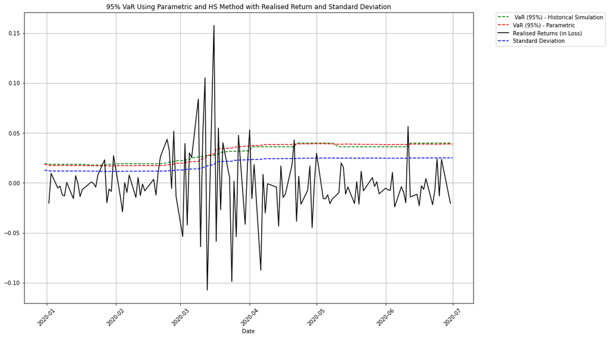

```python
plt.figure(figsize=(15,10))
plt.plot(HR_VaR2['Date'], -HR_VaR2['VaR_95_log'], 'g--', label=' VaR (95%) - Historical Simulation')
plt.plot(portfolio_VaR['Date'][portfolio_VaR['Date'] <= '2020-07-01'], portfolio_VaR['VaR_95'][portfolio_VaR['Date'] <= '2020-07-01'], 'r--', label='VaR (95%) - Parametric')
plt.plot(HR_ES2.loc[HR_ES2['Date'] > '2020-01-01']['Date'], -HR_ES2.loc[HR_ES2['Date'] > '2020-01-01']['log_return'], 'black', label='Realised Returns (in Loss)')
plt.plot(portfolio_VaR['Date'][portfolio_VaR['Date'] <= '2020-07-01'], portfolio_VaR['SD'][portfolio_VaR['Date'] <= '2020-07-01'], 'b--', label='Standard Deviation')
plt.grid(True)
plt.xlabel('Date')
plt.legend(bbox_to_anchor=(1.05, 1), loc=2, borderaxespad=0.)
locs, labels = plt.xticks()
plt.setp(labels, rotation=45)
plt.title('95% VaR Using Parametric and HS Method with Realised Return and Standard Deviation')
plt.show()
```

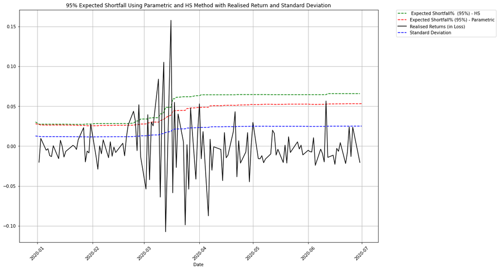

```python
plt.figure(figsize=(15,10))
plt.plot(HR_ES2['Date'], -HR_ES2['ES_95'], 'g--', label=' Expected Shortfall%  (95%) - HS')
plt.plot(para_ES['Date'][para_ES['Date'] <= '2020-07-01'], para_ES['ES_95'][para_ES['Date'] <= '2020-07-01'], 'r--', label='Expected Shortfall% (95%) - Parametric')
plt.plot(HR_ES2.loc[HR_ES2['Date'] > '2020-01-01']['Date'], -HR_ES2.loc[HR_ES2['Date'] > '2020-01-01']['log_return'], 'black', label='Realised Returns (in Loss)')
plt.plot(portfolio_VaR['Date'][portfolio_VaR['Date'] <= '2020-07-01'], portfolio_VaR['SD'][portfolio_VaR['Date'] <= '2020-07-01'], 'b--', label='Standard Deviation')
plt.grid(True)
plt.xlabel('Date')
plt.legend(bbox_to_anchor=(1.05, 1), loc=2, borderaxespad=0.)
locs, labels = plt.xticks()
plt.setp(labels, rotation=45)
plt.title('95% Expected Shortfall Using Parametric and HS Method with Realised Return and Standard Deviation')
plt.show()
```

# Worst Fund

## Daily Historical VaR using HS

```python
def get_data_for_multiple_stocks_daily_param(tickers, start_date, end_date):
    '''
    Obtain stocks information (Date, OHLC, Volume and Adjusted Close).
    Uses Pandas DataReader to make an API Call to Yahoo Finance and download the data directly.
    Computes other values - Log Return and Arithmetic Return.

    Input: List of Stock Tickers
    Output: A dictionary of dataframes for each stock
    '''
    # read in stock data
    s = DataReader(tickers[0], 'yahoo', start_date, end_date)[["Adj Close"]]
    # get log returns
    s[tickers[0]+" adj_close"] = s['Adj Close']
    s[tickers[0]+" log_returns"] = np.log(s['Adj Close']/s['Adj Close'].shift(1))
    stocks = s[[tickers[0]+" adj_close"]]
    stocks[tickers[0]+" log_returns"] = s[tickers[0]+" log_returns"]

    for ticker in tickers[1:]:
        s = DataReader(ticker, 'yahoo', start_date, end_date)

        s[ticker+" adj_close"] = s['Adj Close'] # adj close price
        s[ticker+" log_returns"] = np.log(s['Adj Close']/s['Adj Close'].shift(1))
        stocks[ticker+" adj_close"] = s[ticker+" adj_close"]
        stocks[ticker+" log_returns"] = s[ticker+" log_returns"]

    # skip first row that will be na, and fillna by 0 incase there are trading halts on specific days
    return stocks.fillna(0)
```

```python
fdmax_df_2020 = get_data_for_multiple_stocks_daily_param(tickers_worst, start_date = "2018-12-31", end_date = "2020-07-01")
```

```python
fdmax_df_2020
```

| Date | ERIC adj_close | ERIC log_returns | NOK adj_close | NOK log_returns | CSCO adj_close | CSCO log_returns | FFIV adj_close | FFIV log_returns | CIEN adj_close | CIEN log_returns | JNPR adj_close | JNPR log_returns | MSI adj_close | MSI log_returns | LITE adj_close | LITE log_returns | SATS adj_close | SATS log_returns | VIAV adj_close | VIAV log_returns | ACIA adj_close | ACIA log_returns | ANET adj_close | ANET log_returns | CALX adj_close | CALX log_returns | IDCC adj_close | IDCC log_returns | VSAT adj_close | … |
| --- | --- | --- | --- | --- | --- | --- | --- | --- | --- | --- | --- | --- | --- | --- | --- | --- | --- | --- | --- | --- | --- | --- | --- | --- | --- | --- | --- | --- | --- | --- |
| 2018-12-31 | 8.612761 | 0.000000 | 5.699741 | 0.000000 | 40.739376 | 0.000000 | 162.029999 | 0.000000 | 33.910000 | 0.000000 | 25.435932 | 0.000000 | 111.878273 | 0.000000 | 42.009998 | 0.000000 | 29.756887 | 0.000000 | 10.05 | 0.000000 | 38.000000 | 0.000000 | 210.699997 | 0.000000 | 9.75 | 0.000000 | 63.292057 | 0.000000 | 58.950001 | … |
| 2019-01-02 | 8.379722 | -0.027430 | 5.621394 | -0.013841 | 40.382099 | -0.008808 | 161.179993 | -0.005260 | 33.939999 | 0.000884 | 25.417028 | -0.000743 | 111.625420 | -0.002263 | 42.590000 | 0.013712 | 29.902756 | 0.004890 | 9.93 | -0.012012 | 38.360001 | 0.009429 | 210.550003 | -0.000712 | 9.59 | -0.016546 | 63.301594 | 0.000151 | 58.020000 | … |
| 2019-01-03 | 8.049582 | -0.040195 | 5.454907 | -0.030064 | 38.913486 | -0.037046 | 154.309998 | -0.043558 | 32.869999 | -0.032034 | 24.575781 | -0.033658 | 107.715904 | -0.035652 | 39.009998 | -0.087802 | 29.773096 | -0.004345 | 9.63 | -0.030677 | 36.730000 | -0.043421 | 199.600006 | -0.053408 | 9.30 | -0.030706 | 62.367874 | -0.014860 | 57.310001 | … |
| 2019-01-04 | 8.437981 | 0.047123 | 5.807468 | 0.062629 | 40.666344 | 0.044060 | 159.789993 | 0.034897 | 34.560001 | 0.050137 | 25.521002 | 0.037740 | 112.383972 | 0.042424 | 41.790001 | 0.068839 | 30.940033 | 0.038446 | 9.70 | 0.007243 | 38.439999 | 0.045505 | 202.470001 | 0.014276 | 9.73 | 0.045199 | 64.111420 | 0.027572 | 59.799999 | … |
| 2019-01-07 | 8.544791 | 0.012579 | 5.895608 | 0.015063 | 40.941113 | 0.006734 | 163.820007 | 0.024908 | 35.590000 | 0.029368 | 26.012520 | 0.019076 | 112.909134 | 0.004662 | 42.230000 | 0.010474 | 30.534845 | -0.013182 | 9.89 | 0.019398 | 39.169998 | 0.018813 | 209.919998 | 0.036135 | 9.77 | 0.004103 | 64.378212 | 0.004153 | 60.049999 | … |
| ... | ... | ... | ... | ... | ... | ... | ... | ... | ... | ... | ... | ... | ... | ... | ... | ... | ... | ... | ... | ... | ... | ... | ... | ... | ... | ... | ... | ... | ... | … |
| 2020-06-25 | 9.435771 | 0.051792 | 4.450000 | 0.057820 | 44.456512 | 0.010448 | 134.860001 | -0.001112 | 53.360001 | 0.002627 | 22.074963 | -0.005376 | 139.905624 | 0.008506 | 75.620003 | 0.037456 | 27.629999 | 0.010551 | 12.38 | 0.004047 | 68.349998 | -0.000878 | 211.979996 | 0.012962 | 13.72 | -0.002184 | 54.717083 | 0.023208 | 38.580002 | … |
| 2020-06-26 | 9.197645 | -0.025560 | 4.340000 | -0.025030 | 45.528111 | 0.023818 | 140.119995 | 0.038262 | 53.470001 | 0.002059 | 21.985712 | -0.004051 | 138.202728 | -0.012246 | 76.129997 | 0.006722 | 27.190001 | -0.016053 | 12.50 | 0.009646 | 68.300003 | -0.000732 | 210.630005 | -0.006389 | 13.74 | 0.001457 | 54.786270 | 0.001264 | 36.799999 | … |
| 2020-06-29 | 9.167878 | -0.003242 | 4.350000 | 0.002301 | 45.370815 | -0.003461 | 137.410004 | -0.019530 | 53.150002 | -0.006003 | 22.362553 | 0.016995 | 137.565384 | -0.004622 | 78.410004 | 0.029509 | 27.950001 | 0.027568 | 12.66 | 0.012719 | 67.949997 | -0.005138 | 206.910004 | -0.017819 | 14.77 | 0.072287 | 56.565365 | 0.031957 | 39.330002 | … |
| 2020-06-30 | 9.227410 | 0.006473 | 4.400000 | 0.011429 | 45.852539 | 0.010562 | 139.479996 | 0.014952 | 54.160000 | 0.018824 | 22.669977 | 0.013654 | 139.547119 | 0.014303 | 81.430000 | 0.037792 | 27.959999 | 0.000358 | 12.74 | 0.006299 | 67.190002 | -0.011248 | 210.029999 | 0.014966 | 14.90 | 0.008763 | 55.972336 | -0.010539 | 38.369999 | … |
| 2020-07-01 | 9.217488 | -0.001076 | 4.350000 | -0.011429 | 45.282333 | -0.012514 | 137.309998 | -0.015680 | 53.590000 | -0.010580 | 22.362553 | -0.013654 | 135.404419 | -0.030136 | 80.180000 | -0.015470 | 27.280001 | -0.024621 | 12.32 | -0.033523 | 67.230003 | 0.000595 | 209.440002 | -0.002813 | 14.52 | -0.025834 | 54.796150 | -0.021238 | 36.770000 | … |

379 rows × 60 columns

```python
fdmax_df_2020['Portfolio_Value'] = fdmax_df_2020['ERIC adj_close']*stock_shares[0] + fdmax_df_2020["NOK adj_close"]*stock_shares[1] + fdmax_df_2020["CSCO adj_close"]*stock_shares[2]+ fdmax_df_2020["FFIV adj_close"]*stock_shares[3] + fdmax_df_2020["CIEN adj_close"]*stock_shares[4] + fdmax_df_2020["JNPR adj_close"]*stock_shares[5] + fdmax_df_2020["MSI adj_close"]*stock_shares[6] + fdmax_df_2020["LITE adj_close"]*stock_shares[7] + fdmax_df_2020["SATS adj_close"]*stock_shares[8] + fdmax_df_2020["VIAV adj_close"]*stock_shares[9] + fdmax_df_2020["ACIA adj_close"]*stock_shares[10] + fdmax_df_2020["ANET adj_close"]*stock_shares[11] + fdmax_df_2020["CALX adj_close"]*stock_shares[12] + fdmax_df_2020["IDCC adj_close"]*stock_shares[13] + fdmax_df_2020["VSAT adj_close"]*stock_shares[14] + fdmax_df_2020["NTCT adj_close"]*stock_shares[15] +fdmax_df_2020["COMM adj_close"]*stock_shares[16] + fdmax_df_2020["ET.TO adj_close"]*stock_shares[17] + fdmax_df_2020["FTNT adj_close"]*stock_shares[18] + fdmax_df_2020["PANW adj_close"]*stock_shares[19] + fdmax_df_2020["TENB adj_close"]*stock_shares[20] + fdmax_df_2020["HLIT adj_close"]*stock_shares[21] + fdmax_df_2020["ADTN adj_close"]*stock_shares[22] + fdmax_df_2020["EXTR adj_close"]*stock_shares[23] + fdmax_df_2020["INSG adj_close"]*stock_shares[24] + fdmax_df_2020["RPD adj_close"]*stock_shares[25] + fdmax_df_2020["SW.TO adj_close"]*stock_shares[26]+ fdmax_df_2020["CVLT adj_close"]*stock_shares[27] + fdmax_df_2020["GLW adj_close"]*stock_shares[28] + fdmax_df_2020["RBBN adj_close"]*stock_shares[29]
```

```python
fdmax_df_2020
```

| Date | ERIC adj_close | ERIC log_returns | NOK adj_close | NOK log_returns | CSCO adj_close | CSCO log_returns | FFIV adj_close | FFIV log_returns | CIEN adj_close | CIEN log_returns | JNPR adj_close | JNPR log_returns | MSI adj_close | MSI log_returns | LITE adj_close | LITE log_returns | SATS adj_close | SATS log_returns | VIAV adj_close | VIAV log_returns | ACIA adj_close | ACIA log_returns | ANET adj_close | ANET log_returns | CALX adj_close | CALX log_returns | IDCC adj_close | IDCC log_returns | VSAT adj_close | … |
| --- | --- | --- | --- | --- | --- | --- | --- | --- | --- | --- | --- | --- | --- | --- | --- | --- | --- | --- | --- | --- | --- | --- | --- | --- | --- | --- | --- | --- | --- | --- |
| 2018-12-31 | 8.612761 | 0.000000 | 5.699741 | 0.000000 | 40.739376 | 0.000000 | 162.029999 | 0.000000 | 33.910000 | 0.000000 | 25.435932 | 0.000000 | 111.878273 | 0.000000 | 42.009998 | 0.000000 | 29.756887 | 0.000000 | 10.05 | 0.000000 | 38.000000 | 0.000000 | 210.699997 | 0.000000 | 9.75 | 0.000000 | 63.292057 | 0.000000 | 58.950001 | … |
| 2019-01-02 | 8.379722 | -0.027430 | 5.621394 | -0.013841 | 40.382099 | -0.008808 | 161.179993 | -0.005260 | 33.939999 | 0.000884 | 25.417028 | -0.000743 | 111.625420 | -0.002263 | 42.590000 | 0.013712 | 29.902756 | 0.004890 | 9.93 | -0.012012 | 38.360001 | 0.009429 | 210.550003 | -0.000712 | 9.59 | -0.016546 | 63.301594 | 0.000151 | 58.020000 | … |
| 2019-01-03 | 8.049582 | -0.040195 | 5.454907 | -0.030064 | 38.913486 | -0.037046 | 154.309998 | -0.043558 | 32.869999 | -0.032034 | 24.575781 | -0.033658 | 107.715904 | -0.035652 | 39.009998 | -0.087802 | 29.773096 | -0.004345 | 9.63 | -0.030677 | 36.730000 | -0.043421 | 199.600006 | -0.053408 | 9.30 | -0.030706 | 62.367874 | -0.014860 | 57.310001 | … |
| 2019-01-04 | 8.437981 | 0.047123 | 5.807468 | 0.062629 | 40.666344 | 0.044060 | 159.789993 | 0.034897 | 34.560001 | 0.050137 | 25.521002 | 0.037740 | 112.383972 | 0.042424 | 41.790001 | 0.068839 | 30.940033 | 0.038446 | 9.70 | 0.007243 | 38.439999 | 0.045505 | 202.470001 | 0.014276 | 9.73 | 0.045199 | 64.111420 | 0.027572 | 59.799999 | … |
| 2019-01-07 | 8.544791 | 0.012579 | 5.895608 | 0.015063 | 40.941113 | 0.006734 | 163.820007 | 0.024908 | 35.590000 | 0.029368 | 26.012520 | 0.019076 | 112.909134 | 0.004662 | 42.230000 | 0.010474 | 30.534845 | -0.013182 | 9.89 | 0.019398 | 39.169998 | 0.018813 | 209.919998 | 0.036135 | 9.77 | 0.004103 | 64.378212 | 0.004153 | 60.049999 | … |
| ... | ... | ... | ... | ... | ... | ... | ... | ... | ... | ... | ... | ... | ... | ... | ... | ... | ... | ... | ... | ... | ... | ... | ... | ... | ... | ... | ... | ... | ... | … |
| 2020-06-25 | 9.435771 | 0.051792 | 4.450000 | 0.057820 | 44.456512 | 0.010448 | 134.860001 | -0.001112 | 53.360001 | 0.002627 | 22.074963 | -0.005376 | 139.905624 | 0.008506 | 75.620003 | 0.037456 | 27.629999 | 0.010551 | 12.38 | 0.004047 | 68.349998 | -0.000878 | 211.979996 | 0.012962 | 13.72 | -0.002184 | 54.717083 | 0.023208 | 38.580002 | … |
| 2020-06-26 | 9.197645 | -0.025560 | 4.340000 | -0.025030 | 45.528111 | 0.023818 | 140.119995 | 0.038262 | 53.470001 | 0.002059 | 21.985712 | -0.004051 | 138.202728 | -0.012246 | 76.129997 | 0.006722 | 27.190001 | -0.016053 | 12.50 | 0.009646 | 68.300003 | -0.000732 | 210.630005 | -0.006389 | 13.74 | 0.001457 | 54.786270 | 0.001264 | 36.799999 | … |
| 2020-06-29 | 9.167878 | -0.003242 | 4.350000 | 0.002301 | 45.370815 | -0.003461 | 137.410004 | -0.019530 | 53.150002 | -0.006003 | 22.362553 | 0.016995 | 137.565384 | -0.004622 | 78.410004 | 0.029509 | 27.950001 | 0.027568 | 12.66 | 0.012719 | 67.949997 | -0.005138 | 206.910004 | -0.017819 | 14.77 | 0.072287 | 56.565365 | 0.031957 | 39.330002 | … |
| 2020-06-30 | 9.227410 | 0.006473 | 4.400000 | 0.011429 | 45.852539 | 0.010562 | 139.479996 | 0.014952 | 54.160000 | 0.018824 | 22.669977 | 0.013654 | 139.547119 | 0.014303 | 81.430000 | 0.037792 | 27.959999 | 0.000358 | 12.74 | 0.006299 | 67.190002 | -0.011248 | 210.029999 | 0.014966 | 14.90 | 0.008763 | 55.972336 | -0.010539 | 38.369999 | … |
| 2020-07-01 | 9.217488 | -0.001076 | 4.350000 | -0.011429 | 45.282333 | -0.012514 | 137.309998 | -0.015680 | 53.590000 | -0.010580 | 22.362553 | -0.013654 | 135.404419 | -0.030136 | 80.180000 | -0.015470 | 27.280001 | -0.024621 | 12.32 | -0.033523 | 67.230003 | 0.000595 | 209.440002 | -0.002813 | 14.52 | -0.025834 | 54.796150 | -0.021238 | 36.770000 | … |

379 rows × 61 columns

```python
fdmax_df_2020['lag_index'] = fdmax_df_2020['Portfolio_Value'].shift(1)
fdmax_df_2020['log_returns'] = np.log(fdmax_df_2020['Portfolio_Value']/fdmax_df_2020['lag_index'])
```

```python
fdmax_df_2020.reset_index(inplace=True)
```

```python
# For each row, use previous 250 rows' (return series) to calculate log% VaR.
from copy import deepcopy
fdmax_VaR_HS = deepcopy(fdmax_df_2020)

for i in range(0, len(fdmax_VaR_HS)):
    past_250 = fdmax_VaR_HS.loc[(i-250):(i-1), 'log_returns']
    if len(past_250) == 250:
        fdmax_VaR_HS.loc[i, 'log_VaR_95'] = past_250.quantile(0.05)
    else:
        fdmax_VaR_HS.loc[i, 'log_VaR_95'] = np.NaN
```

```python
fdmax_VaR_HS.dropna(inplace = True)
```

```python
fdmax_VaR_HS
```

|  | Date | ERIC adj_close | ERIC log_returns | NOK adj_close | NOK log_returns | CSCO adj_close | CSCO log_returns | FFIV adj_close | FFIV log_returns | CIEN adj_close | CIEN log_returns | JNPR adj_close | JNPR log_returns | MSI adj_close | MSI log_returns | LITE adj_close | LITE log_returns | SATS adj_close | SATS log_returns | VIAV adj_close | VIAV log_returns | ACIA adj_close | ACIA log_returns | ANET adj_close | ANET log_returns | CALX adj_close | CALX log_returns | IDCC adj_close | IDCC log_returns | … |
| --- | --- | --- | --- | --- | --- | --- | --- | --- | --- | --- | --- | --- | --- | --- | --- | --- | --- | --- | --- | --- | --- | --- | --- | --- | --- | --- | --- | --- | --- | --- |
| 250 | 2019-12-27 | 8.706087 | -0.002255 | 3.63 | 0.002759 | 46.182861 | -0.001673 | 139.169998 | 0.000647 | 42.669998 | -0.001171 | 23.782164 | -0.003272 | 159.386978 | 0.000434 | 79.010002 | -0.006811 | 44.009998 | -0.003403 | 15.12 | -0.011181 | 67.559998 | 0.000000 | 204.429993 | -0.005756 | 8.04 | 0.011257 | 53.595173 | -0.006524 | … |
| 251 | 2019-12-30 | 8.607824 | -0.011351 | 3.69 | 0.016394 | 46.008842 | -0.003775 | 139.289993 | 0.000862 | 42.639999 | -0.000703 | 23.869848 | 0.003680 | 158.903244 | -0.003040 | 79.599998 | 0.007440 | 43.549999 | -0.010507 | 15.14 | 0.001322 | 67.730003 | 0.002513 | 203.130005 | -0.006379 | 8.20 | 0.019705 | 53.332066 | -0.004921 | … |
| 252 | 2019-12-31 | 8.627477 | 0.002280 | 3.71 | 0.005405 | 46.366550 | 0.007745 | 139.649994 | 0.002581 | 42.689999 | 0.001172 | 23.996506 | 0.005292 | 159.080948 | 0.001118 | 79.300003 | -0.003776 | 43.310001 | -0.005526 | 15.00 | -0.009290 | 67.809998 | 0.001180 | 203.399994 | 0.001328 | 8.00 | -0.024693 | 53.098202 | -0.004395 | … |
| 253 | 2020-01-02 | 8.853482 | 0.025859 | 3.87 | 0.042223 | 47.155396 | 0.016870 | 140.759995 | 0.007917 | 42.860001 | 0.003974 | 24.074448 | 0.003243 | 159.564697 | 0.003036 | 82.699997 | 0.041981 | 43.209999 | -0.002312 | 15.31 | 0.020456 | 68.089996 | 0.004121 | 204.720001 | 0.006469 | 7.99 | -0.001251 | 54.121384 | 0.019086 | … |
| 254 | 2020-01-03 | 8.696262 | -0.017918 | 3.81 | -0.015625 | 46.386028 | -0.016450 | 140.000000 | -0.005414 | 41.869999 | -0.023369 | 23.713964 | -0.015087 | 162.279541 | 0.016871 | 81.900002 | -0.009721 | 43.080002 | -0.003013 | 15.07 | -0.015800 | 68.099998 | 0.000147 | 200.850006 | -0.019085 | 7.93 | -0.007538 | 52.961773 | -0.021659 | … |
| ... | ... | ... | ... | ... | ... | ... | ... | ... | ... | ... | ... | ... | ... | ... | ... | ... | ... | ... | ... | ... | ... | ... | ... | ... | ... | ... | ... | ... | ... | … |
| 374 | 2020-06-25 | 9.435771 | 0.051792 | 4.45 | 0.057820 | 44.456512 | 0.010448 | 134.860001 | -0.001112 | 53.360001 | 0.002627 | 22.074963 | -0.005376 | 139.905624 | 0.008506 | 75.620003 | 0.037456 | 27.629999 | 0.010551 | 12.38 | 0.004047 | 68.349998 | -0.000878 | 211.979996 | 0.012962 | 13.72 | -0.002184 | 54.717083 | 0.023208 | … |
| 375 | 2020-06-26 | 9.197645 | -0.025560 | 4.34 | -0.025030 | 45.528111 | 0.023818 | 140.119995 | 0.038262 | 53.470001 | 0.002059 | 21.985712 | -0.004051 | 138.202728 | -0.012246 | 76.129997 | 0.006722 | 27.190001 | -0.016053 | 12.50 | 0.009646 | 68.300003 | -0.000732 | 210.630005 | -0.006389 | 13.74 | 0.001457 | 54.786270 | 0.001264 | … |
| 376 | 2020-06-29 | 9.167878 | -0.003242 | 4.35 | 0.002301 | 45.370815 | -0.003461 | 137.410004 | -0.019530 | 53.150002 | -0.006003 | 22.362553 | 0.016995 | 137.565384 | -0.004622 | 78.410004 | 0.029509 | 27.950001 | 0.027568 | 12.66 | 0.012719 | 67.949997 | -0.005138 | 206.910004 | -0.017819 | 14.77 | 0.072287 | 56.565365 | 0.031957 | … |
| 377 | 2020-06-30 | 9.227410 | 0.006473 | 4.40 | 0.011429 | 45.852539 | 0.010562 | 139.479996 | 0.014952 | 54.160000 | 0.018824 | 22.669977 | 0.013654 | 139.547119 | 0.014303 | 81.430000 | 0.037792 | 27.959999 | 0.000358 | 12.74 | 0.006299 | 67.190002 | -0.011248 | 210.029999 | 0.014966 | 14.90 | 0.008763 | 55.972336 | -0.010539 | … |
| 378 | 2020-07-01 | 9.217488 | -0.001076 | 4.35 | -0.011429 | 45.282333 | -0.012514 | 137.309998 | -0.015680 | 53.590000 | -0.010580 | 22.362553 | -0.013654 | 135.404419 | -0.030136 | 80.180000 | -0.015470 | 27.280001 | -0.024621 | 12.32 | -0.033523 | 67.230003 | 0.000595 | 209.440002 | -0.002813 | 14.52 | -0.025834 | 54.796150 | -0.021238 | … |

129 rows × 65 columns

## Daily Historical ES using HS

```python
# For each row, use previous 250 rows' (return series) to calculate Expected Shortfall ES%.
import math
fdmax_HS_ES = deepcopy(fdmax_df_2020)

significance = 0.05 # Significance level
confidence = 0.95 # Confidence level

for i in range(0, len(fdmax_HS_ES)):
    past_250 = fdmax_HS_ES.loc[(i-250):(i-1), 'log_returns']
    T_days = len(past_250) # Number of past days
    if T_days == 250:

        VaR = past_250.quantile(significance) # VaR of 95%
        log_returns_sorted = sorted(past_250.dropna())
        length = len(log_returns_sorted)

        cutoff_rt_index = math.floor(length*significance +1) - 1 #minus one due to index starting from 0

        sum_rt = sum(log_returns_sorted[:cutoff_rt_index])

        fdmax_HS_ES.loc[i, 'sum_log_95'] = sum_rt

        fdmax_HS_ES.loc[i, 'log_ES_95'] = sum_rt/len(log_returns_sorted[:cutoff_rt_index])

    else:
        fdmax_HS_ES.loc[i, 'log_ES_95'] = np.NaN
```

## Daily VaR using Parametric

```python
tickers_daily_param = ["ERIC", "NOK", "CSCO", "FFIV", "CIEN", "JNPR", "MSI", "LITE", "SATS", "VIAV", "ACIA", "ANET", "CALX", "IDCC",
            "VSAT", "NTCT", "COMM", "ET.TO", "FTNT", "PANW", "TENB", "HLIT", "ADTN", "EXTR",
            "INSG", "RPD", "SW.TO", "CVLT", "GLW", "RBBN"]
```

```python
#getting stock prices of 31 aug 2020
stock_prices = DataReader(tickers_daily_param, 'yahoo', '2020-08-31', '2020-08-31')[['Adj Close']]
```

```python
stock_prices
```

| Attributes Symbols Date | Adj Close ERIC | Adj Close NOK | Adj Close CSCO | Adj Close FFIV | Adj Close CIEN | Adj Close JNPR | Adj Close MSI | Adj Close LITE | Adj Close SATS | Adj Close VIAV | Adj Close ACIA | Adj Close ANET | Adj Close CALX | Adj Close IDCC | Adj Close VSAT | Adj Close NTCT | Adj Close COMM | Adj Close ET.TO | Adj Close FTNT | Adj Close PANW | Adj Close TENB | Adj Close HLIT | Adj Close ADTN | Adj Close EXTR | Adj Close INSG | Adj Close RPD | Adj Close SW.TO | Adj Close CVLT | Adj Close GLW | … |
| --- | --- | --- | --- | --- | --- | --- | --- | --- | --- | --- | --- | --- | --- | --- | --- | --- | --- | --- | --- | --- | --- | --- | --- | --- | --- | --- | --- | --- | --- | --- |
| 2020-08-31 | 11.559068 | 4.9 | 41.834137 | 132.330002 | 56.77 | 25.0 | 154.106293 | 86.0 | 29.379999 | 13.34 | 67.480003 | 223.449997 | 19.450001 | 60.803627 | 39.759998 | 23.139999 | 10.3 | 11.800452 | 132.009995 | 257.410004 | 37.639999 | 5.9 | 11.09 | 4.37 | 11.48 | 64.57 | 16.190001 | 43.23 | 32.459999 | … |

```python
stock_prices_list_nested = stock_prices.values.tolist()
```

```python
stock_prices_list_nested
```

```
[[11.559067726135254,
  4.900000095367432,
  41.834136962890625,
  132.3300018310547,
  56.77000045776367,
  25.0,
  154.10629272460938,
  86.0,
  29.3799991607666,
  13.34000015258789,
  67.4800033569336,
  223.4499969482422,
  19.450000762939453,
  60.803627014160156,
  39.7599983215332,
  23.139999389648438,
  10.300000190734863,
  11.80045223236084,
  132.00999450683594,
  257.4100036621094,
  37.63999938964844,
  5.900000095367432,
  11.09000015258789,
  4.369999885559082,
  11.479999542236328,
  64.56999969482422,
  16.190000534057617,
  43.22999954223633,
  32.459999084472656,
  4.28000020980835]]
```

```python
stock_prices_list = []
for sublist in stock_prices_list_nested:
    for item in sublist:
        stock_prices_list.append(item)
```

```python
stock_prices_list
```

```
[11.559067726135254,
 4.900000095367432,
 41.834136962890625,
 132.3300018310547,
 56.77000045776367,
 25.0,
 154.10629272460938,
 86.0,
 29.3799991607666,
 13.34000015258789,
 67.4800033569336,
 223.4499969482422,
 19.450000762939453,
 60.803627014160156,
 39.7599983215332,
 23.139999389648438,
 10.300000190734863,
 11.80045223236084,
 132.00999450683594,
 257.4100036621094,
 37.63999938964844,
 5.900000095367432,
 11.09000015258789,
 4.369999885559082,
 11.479999542236328,
 64.56999969482422,
 16.190000534057617,
 43.22999954223633,
 32.459999084472656,
 4.28000020980835]
```

```python
#dollar values of each stock is the market value of each of the 30 stocks
dollar_val_each_stock = [4077954, 1123183, 3142012, 903417, 870909, 866150, 810271, 631412, 554312, 536947, 523982, 413829, 402207, 400227,
               369211, 348419, 240423, 49133, 50162, 180187, 154173, 116425, 109336, 106724,
               104755, 102925, 96791, 93550, 56253, 52006]
```

```python
shares = [a/b for a,b in zip(dollar_val_each_stock, stock_prices_list)]
```

```python
len(shares)
```

```
30
```

```python
shares
```

```
[352792.6383526307,
 229221.01594689395,
 75106.41375934568,
 6827.000585652449,
 15341.007450721228,
 34646.0,
 5257.870951759046,
 7342.0,
 18866.984882021916,
 40250.89908982011,
 7764.996649872879,
 1851.9982351839342,
 20679.0223250981,
 6582.288255712012,
 9285.991337681795,
 15057.001261454807,
 23342.038402704806,
 4163.653988214169,
 379.9863804812327,
 699.9999900412706,
 4095.988376726698,
 19733.05052849316,
 9858.97191123898,
 24421.968602945653,
 9125.000363858333,
 1594.0065121024033,
 5978.443286421669,
 2164.006499898301,
 1732.9945035922321,
 12150.933983792662]
```

```python
stocks = get_data_for_multiple_stocks_daily_param(tickers_daily_param,start_date='2019-01-01',end_date= '2020-07-01')
```

```python
stocks
```

| Date | ERIC adj_close | ERIC log_returns | NOK adj_close | NOK log_returns | CSCO adj_close | CSCO log_returns | FFIV adj_close | FFIV log_returns | CIEN adj_close | CIEN log_returns | JNPR adj_close | JNPR log_returns | MSI adj_close | MSI log_returns | LITE adj_close | LITE log_returns | SATS adj_close | SATS log_returns | VIAV adj_close | VIAV log_returns | ACIA adj_close | ACIA log_returns | ANET adj_close | ANET log_returns | CALX adj_close | CALX log_returns | IDCC adj_close | IDCC log_returns | VSAT adj_close | … |
| --- | --- | --- | --- | --- | --- | --- | --- | --- | --- | --- | --- | --- | --- | --- | --- | --- | --- | --- | --- | --- | --- | --- | --- | --- | --- | --- | --- | --- | --- | --- |
| 2019-01-02 | 8.379722 | 0.000000 | 5.621394 | 0.000000 | 40.382099 | 0.000000 | 161.179993 | 0.000000 | 33.939999 | 0.000000 | 25.417028 | 0.000000 | 111.625420 | 0.000000 | 42.590000 | 0.000000 | 29.902756 | 0.000000 | 9.93 | 0.000000 | 38.360001 | 0.000000 | 210.550003 | 0.000000 | 9.59 | 0.000000 | 63.301594 | 0.000000 | 58.020000 | … |
| 2019-01-03 | 8.049582 | -0.040195 | 5.454907 | -0.030064 | 38.913486 | -0.037046 | 154.309998 | -0.043558 | 32.869999 | -0.032034 | 24.575781 | -0.033658 | 107.715904 | -0.035652 | 39.009998 | -0.087802 | 29.773096 | -0.004345 | 9.63 | -0.030677 | 36.730000 | -0.043421 | 199.600006 | -0.053408 | 9.30 | -0.030706 | 62.367874 | -0.014860 | 57.310001 | … |
| 2019-01-04 | 8.437981 | 0.047123 | 5.807468 | 0.062629 | 40.666344 | 0.044060 | 159.789993 | 0.034897 | 34.560001 | 0.050137 | 25.521002 | 0.037740 | 112.383972 | 0.042424 | 41.790001 | 0.068839 | 30.940033 | 0.038446 | 9.70 | 0.007243 | 38.439999 | 0.045505 | 202.470001 | 0.014276 | 9.73 | 0.045199 | 64.111420 | 0.027572 | 59.799999 | … |
| 2019-01-07 | 8.544791 | 0.012579 | 5.895608 | 0.015063 | 40.941113 | 0.006734 | 163.820007 | 0.024908 | 35.590000 | 0.029368 | 26.012520 | 0.019076 | 112.909134 | 0.004662 | 42.230000 | 0.010474 | 30.534845 | -0.013182 | 9.89 | 0.019398 | 39.169998 | 0.018813 | 209.919998 | 0.036135 | 9.77 | 0.004103 | 64.378212 | 0.004153 | 60.049999 | … |
| 2019-01-08 | 8.700151 | 0.018019 | 6.022922 | 0.021365 | 41.272739 | 0.008067 | 164.820007 | 0.006086 | 36.650002 | 0.029349 | 26.343348 | 0.012638 | 116.225418 | 0.028948 | 43.459999 | 0.028710 | 31.207455 | 0.021788 | 9.97 | 0.008056 | 41.660000 | 0.061630 | 214.279999 | 0.020557 | 9.69 | -0.008222 | 65.699867 | 0.020322 | 60.490002 | … |
| ... | ... | ... | ... | ... | ... | ... | ... | ... | ... | ... | ... | ... | ... | ... | ... | ... | ... | ... | ... | ... | ... | ... | ... | ... | ... | ... | ... | ... | ... | … |
| 2020-06-25 | 9.435771 | 0.051792 | 4.450000 | 0.057820 | 44.456512 | 0.010448 | 134.860001 | -0.001112 | 53.360001 | 0.002627 | 22.074963 | -0.005376 | 139.905624 | 0.008506 | 75.620003 | 0.037456 | 27.629999 | 0.010551 | 12.38 | 0.004047 | 68.349998 | -0.000878 | 211.979996 | 0.012962 | 13.72 | -0.002184 | 54.717083 | 0.023208 | 38.580002 | … |
| 2020-06-26 | 9.197645 | -0.025560 | 4.340000 | -0.025030 | 45.528111 | 0.023818 | 140.119995 | 0.038262 | 53.470001 | 0.002059 | 21.985712 | -0.004051 | 138.202728 | -0.012246 | 76.129997 | 0.006722 | 27.190001 | -0.016053 | 12.50 | 0.009646 | 68.300003 | -0.000732 | 210.630005 | -0.006389 | 13.74 | 0.001457 | 54.786270 | 0.001264 | 36.799999 | … |
| 2020-06-29 | 9.167878 | -0.003242 | 4.350000 | 0.002301 | 45.370815 | -0.003461 | 137.410004 | -0.019530 | 53.150002 | -0.006003 | 22.362553 | 0.016995 | 137.565384 | -0.004622 | 78.410004 | 0.029509 | 27.950001 | 0.027568 | 12.66 | 0.012719 | 67.949997 | -0.005138 | 206.910004 | -0.017819 | 14.77 | 0.072287 | 56.565365 | 0.031957 | 39.330002 | … |
| 2020-06-30 | 9.227410 | 0.006473 | 4.400000 | 0.011429 | 45.852539 | 0.010562 | 139.479996 | 0.014952 | 54.160000 | 0.018824 | 22.669977 | 0.013654 | 139.547119 | 0.014303 | 81.430000 | 0.037792 | 27.959999 | 0.000358 | 12.74 | 0.006299 | 67.190002 | -0.011248 | 210.029999 | 0.014966 | 14.90 | 0.008763 | 55.972336 | -0.010539 | 38.369999 | … |
| 2020-07-01 | 9.217488 | -0.001076 | 4.350000 | -0.011429 | 45.282333 | -0.012514 | 137.309998 | -0.015680 | 53.590000 | -0.010580 | 22.362553 | -0.013654 | 135.404419 | -0.030136 | 80.180000 | -0.015470 | 27.280001 | -0.024621 | 12.32 | -0.033523 | 67.230003 | 0.000595 | 209.440002 | -0.002813 | 14.52 | -0.025834 | 54.796150 | -0.021238 | 36.770000 | … |

378 rows × 60 columns

```python
stocks.reset_index(inplace=True)
```

```python
stocks.head()
```

|  | Date | ERIC adj_close | ERIC log_returns | NOK adj_close | NOK log_returns | CSCO adj_close | CSCO log_returns | FFIV adj_close | FFIV log_returns | CIEN adj_close | CIEN log_returns | JNPR adj_close | JNPR log_returns | MSI adj_close | MSI log_returns | LITE adj_close | LITE log_returns | SATS adj_close | SATS log_returns | VIAV adj_close | VIAV log_returns | ACIA adj_close | ACIA log_returns | ANET adj_close | ANET log_returns | CALX adj_close | CALX log_returns | IDCC adj_close | IDCC log_returns | … |
| --- | --- | --- | --- | --- | --- | --- | --- | --- | --- | --- | --- | --- | --- | --- | --- | --- | --- | --- | --- | --- | --- | --- | --- | --- | --- | --- | --- | --- | --- | --- |
| 0 | 2019-01-02 | 8.379722 | 0.000000 | 5.621394 | 0.000000 | 40.382099 | 0.000000 | 161.179993 | 0.000000 | 33.939999 | 0.000000 | 25.417028 | 0.000000 | 111.625420 | 0.000000 | 42.590000 | 0.000000 | 29.902756 | 0.000000 | 9.93 | 0.000000 | 38.360001 | 0.000000 | 210.550003 | 0.000000 | 9.59 | 0.000000 | 63.301594 | 0.000000 | … |
| 1 | 2019-01-03 | 8.049582 | -0.040195 | 5.454907 | -0.030064 | 38.913486 | -0.037046 | 154.309998 | -0.043558 | 32.869999 | -0.032034 | 24.575781 | -0.033658 | 107.715904 | -0.035652 | 39.009998 | -0.087802 | 29.773096 | -0.004345 | 9.63 | -0.030677 | 36.730000 | -0.043421 | 199.600006 | -0.053408 | 9.30 | -0.030706 | 62.367874 | -0.014860 | … |
| 2 | 2019-01-04 | 8.437981 | 0.047123 | 5.807468 | 0.062629 | 40.666344 | 0.044060 | 159.789993 | 0.034897 | 34.560001 | 0.050137 | 25.521002 | 0.037740 | 112.383972 | 0.042424 | 41.790001 | 0.068839 | 30.940033 | 0.038446 | 9.70 | 0.007243 | 38.439999 | 0.045505 | 202.470001 | 0.014276 | 9.73 | 0.045199 | 64.111420 | 0.027572 | … |
| 3 | 2019-01-07 | 8.544791 | 0.012579 | 5.895608 | 0.015063 | 40.941113 | 0.006734 | 163.820007 | 0.024908 | 35.590000 | 0.029368 | 26.012520 | 0.019076 | 112.909134 | 0.004662 | 42.230000 | 0.010474 | 30.534845 | -0.013182 | 9.89 | 0.019398 | 39.169998 | 0.018813 | 209.919998 | 0.036135 | 9.77 | 0.004103 | 64.378212 | 0.004153 | … |
| 4 | 2019-01-08 | 8.700151 | 0.018019 | 6.022922 | 0.021365 | 41.272739 | 0.008067 | 164.820007 | 0.006086 | 36.650002 | 0.029349 | 26.343348 | 0.012638 | 116.225418 | 0.028948 | 43.459999 | 0.028710 | 31.207455 | 0.021788 | 9.97 | 0.008056 | 41.660000 | 0.061630 | 214.279999 | 0.020557 | 9.69 | -0.008222 | 65.699867 | 0.020322 | … |

```python
stocks['ERIC adj_close'] = stocks['ERIC adj_close'] * 352792.6383526307
stocks['NOK adj_close'] = stocks['NOK adj_close'] * 229221.01594689395
stocks['CSCO adj_close'] = stocks['CSCO adj_close'] * 75106.41375934568
stocks['FFIV adj_close'] = stocks['FFIV adj_close'] * 6827.000585652449
stocks['CIEN adj_close'] = stocks['CIEN adj_close'] * 15341.007450721228
stocks['JNPR adj_close'] = stocks['JNPR adj_close'] * 34646.0
stocks['MSI adj_close'] = stocks['MSI adj_close'] * 5257.870951759046
stocks['LITE adj_close'] = stocks['LITE adj_close'] * 7342.0
stocks['SATS adj_close'] = stocks['SATS adj_close'] * 18866.984882021916
stocks['VIAV adj_close'] = stocks['VIAV adj_close'] * 40250.89908982011
stocks['ACIA adj_close'] = stocks['ACIA adj_close'] * 7764.996649872879
stocks['ANET adj_close'] = stocks['ANET adj_close'] * 1851.9982351839342
stocks['CALX adj_close'] = stocks['CALX adj_close'] * 20679.0223250981
stocks['IDCC adj_close'] = stocks['IDCC adj_close'] * 6545.003924989642
stocks['VSAT adj_close'] = stocks['VSAT adj_close'] * 9285.991337681795
stocks['NTCT adj_close'] = stocks['NTCT adj_close'] * 15057.001261454807
stocks['COMM adj_close'] = stocks['COMM adj_close'] * 23342.038402704806
stocks['ET.TO adj_close'] = stocks['ET.TO adj_close'] * 4163.653988214169
stocks['FTNT adj_close'] = stocks['FTNT adj_close'] * 379.9863804812327
stocks['PANW adj_close'] = stocks['PANW adj_close'] * 699.9999900412706
stocks['TENB adj_close'] = stocks['TENB adj_close'] * 4095.988376726698
stocks['HLIT adj_close'] = stocks['HLIT adj_close'] * 19733.05052849316
stocks['ADTN adj_close'] = stocks['ADTN adj_close'] * 9858.97191123898
stocks['EXTR adj_close'] = stocks['EXTR adj_close'] * 24421.968602945653
stocks['INSG adj_close'] = stocks['INSG adj_close'] * 9125.000363858333
stocks['RPD adj_close'] = stocks['RPD adj_close'] * 1594.0065121024033
stocks['SW.TO adj_close'] = stocks['SW.TO adj_close'] * 5978.443286421669
stocks['CVLT adj_close'] = stocks['CVLT adj_close'] * 2164.006499898301
stocks['GLW adj_close'] = stocks['GLW adj_close'] * 1732.9945035922321
stocks['RBBN adj_close'] = stocks['RBBN adj_close'] * 12150.933983792662
```

```python
stocks.head()
```

|  | Date | ERIC adj_close | ERIC log_returns | NOK adj_close | NOK log_returns | CSCO adj_close | CSCO log_returns | FFIV adj_close | FFIV log_returns | CIEN adj_close | CIEN log_returns | JNPR adj_close | JNPR log_returns | MSI adj_close | MSI log_returns | LITE adj_close | LITE log_returns | SATS adj_close | SATS log_returns | VIAV adj_close | VIAV log_returns | ACIA adj_close | ACIA log_returns | ANET adj_close | ANET log_returns | CALX adj_close | CALX log_returns | IDCC adj_close | IDCC log_returns | … |
| --- | --- | --- | --- | --- | --- | --- | --- | --- | --- | --- | --- | --- | --- | --- | --- | --- | --- | --- | --- | --- | --- | --- | --- | --- | --- | --- | --- | --- | --- | --- |
| 0 | 2019-01-02 | 2.956304e+06 | 0.000000 | 1.288542e+06 | 0.000000 | 3.032955e+06 | 0.000000 | 1.100376e+06 | 0.000000 | 520673.771810 | 0.000000 | 880598.366886 | 0.000000 | 586912.051281 | 0.000000 | 312695.781120 | 0.000000 | 564174.840427 | 0.000000 | 399691.440246 | 0.000000 | 297865.276229 | 0.000000 | 389938.234070 | 0.000000 | 198311.827253 | 0.000000 | 414309.179752 | 0.000000 | … |
| 1 | 2019-01-03 | 2.839833e+06 | -0.040195 | 1.250379e+06 | -0.030064 | 2.922652e+06 | -0.037046 | 1.053474e+06 | -0.043558 | 504258.898519 | -0.032034 | 851452.503971 | -0.033658 | 566356.323924 | -0.035652 | 286411.407677 | -0.087802 | 561728.553719 | -0.004345 | 387616.162841 | -0.030677 | 285208.323395 | -0.043421 | 369658.859046 | -0.053408 | 192314.911568 | -0.030706 | 408197.981076 | -0.014860 | … |
| 2 | 2019-01-04 | 2.976857e+06 | 0.047123 | 1.331194e+06 | 0.062629 | 3.054303e+06 | 0.044060 | 1.090886e+06 | 0.034897 | 530185.238565 | 0.050137 | 884200.628910 | 0.037740 | 590900.422705 | 0.042424 | 306822.186722 | 0.068839 | 583745.134086 | 0.038446 | 390433.713494 | 0.007243 | 298486.460558 | 0.045505 | 374974.084938 | 0.014276 | 201206.877757 | 0.045199 | 419609.493427 | 0.027572 | … |
| 3 | 2019-01-07 | 3.014539e+06 | 0.012579 | 1.351397e+06 | 0.015063 | 3.074940e+06 | 0.006734 | 1.118399e+06 | 0.024908 | 545986.457512 | 0.029368 | 901229.762253 | 0.019076 | 593661.655380 | 0.004662 | 310052.656639 | 0.010474 | 576100.465634 | -0.013182 | 398081.405817 | 0.019398 | 304154.904557 | 0.018813 | 388771.466139 | 0.036135 | 202034.057582 | 0.004103 | 421355.650061 | 0.004153 | … |
| 4 | 2019-01-08 | 3.069349e+06 | 0.018019 | 1.380580e+06 | 0.021365 | 3.099847e+06 | 0.008067 | 1.125226e+06 | 0.006086 | 562247.946477 | 0.029349 | 912691.619198 | 0.012638 | 611098.249636 | 0.028948 | 319083.313278 | 0.028710 | 588790.575680 | 0.021788 | 401301.474674 | 0.008056 | 323489.759249 | 0.061630 | 396846.179574 | 0.020557 | 200379.717653 | -0.008222 | 430005.889013 | 0.020322 | … |

```python
columns = list(stocks)
```

```python
columns.remove('Date')
columns.remove('ERIC log_returns')
columns.remove('NOK log_returns')
columns.remove('CSCO log_returns')
columns.remove('FFIV log_returns')
columns.remove('CIEN log_returns')
columns.remove('JNPR log_returns')
columns.remove('MSI log_returns')
columns.remove('LITE log_returns')
columns.remove('SATS log_returns')
columns.remove('VIAV log_returns')
columns.remove('ACIA log_returns')
columns.remove('ANET log_returns')
columns.remove('CALX log_returns')
columns.remove('IDCC log_returns')
columns.remove('VSAT log_returns')
columns.remove('NTCT log_returns')
columns.remove('COMM log_returns')
columns.remove('ET.TO log_returns')
columns.remove('FTNT log_returns')
columns.remove('PANW log_returns')
columns.remove('TENB log_returns')
columns.remove('HLIT log_returns')
columns.remove('ADTN log_returns')
columns.remove('EXTR log_returns')
columns.remove('INSG log_returns')
columns.remove('RPD log_returns')
columns.remove('SW.TO log_returns')
columns.remove('CVLT log_returns')
columns.remove('GLW log_returns')
columns.remove('RBBN log_returns')
```

```python
len(columns)
```

```
30
```

```python
columns
```

```
['ERIC adj_close',
 'NOK adj_close',
 'CSCO adj_close',
 'FFIV adj_close',
 'CIEN adj_close',
 'JNPR adj_close',
 'MSI adj_close',
 'LITE adj_close',
 'SATS adj_close',
 'VIAV adj_close',
 'ACIA adj_close',
 'ANET adj_close',
 'CALX adj_close',
 'IDCC adj_close',
 'VSAT adj_close',
 'NTCT adj_close',
 'COMM adj_close',
 'ET.TO adj_close',
 'FTNT adj_close',
 'PANW adj_close',
 'TENB adj_close',
 'HLIT adj_close',
 'ADTN adj_close',
 'EXTR adj_close',
 'INSG adj_close',
 'RPD adj_close',
 'SW.TO adj_close',
 'CVLT adj_close',
 'GLW adj_close',
 'RBBN adj_close']
```

```python
stocks["Value of Portfolio"] = stocks[columns].sum(axis=1)
```

```python
stocks.head()
```

|  | Date | ERIC adj_close | ERIC log_returns | NOK adj_close | NOK log_returns | CSCO adj_close | CSCO log_returns | FFIV adj_close | FFIV log_returns | CIEN adj_close | CIEN log_returns | JNPR adj_close | JNPR log_returns | MSI adj_close | MSI log_returns | LITE adj_close | LITE log_returns | SATS adj_close | SATS log_returns | VIAV adj_close | VIAV log_returns | ACIA adj_close | ACIA log_returns | ANET adj_close | ANET log_returns | CALX adj_close | CALX log_returns | IDCC adj_close | IDCC log_returns | … |
| --- | --- | --- | --- | --- | --- | --- | --- | --- | --- | --- | --- | --- | --- | --- | --- | --- | --- | --- | --- | --- | --- | --- | --- | --- | --- | --- | --- | --- | --- | --- |
| 0 | 2019-01-02 | 2.956304e+06 | 0.000000 | 1.288542e+06 | 0.000000 | 3.032955e+06 | 0.000000 | 1.100376e+06 | 0.000000 | 520673.771810 | 0.000000 | 880598.366886 | 0.000000 | 586912.051281 | 0.000000 | 312695.781120 | 0.000000 | 564174.840427 | 0.000000 | 399691.440246 | 0.000000 | 297865.276229 | 0.000000 | 389938.234070 | 0.000000 | 198311.827253 | 0.000000 | 414309.179752 | 0.000000 | … |
| 1 | 2019-01-03 | 2.839833e+06 | -0.040195 | 1.250379e+06 | -0.030064 | 2.922652e+06 | -0.037046 | 1.053474e+06 | -0.043558 | 504258.898519 | -0.032034 | 851452.503971 | -0.033658 | 566356.323924 | -0.035652 | 286411.407677 | -0.087802 | 561728.553719 | -0.004345 | 387616.162841 | -0.030677 | 285208.323395 | -0.043421 | 369658.859046 | -0.053408 | 192314.911568 | -0.030706 | 408197.981076 | -0.014860 | … |
| 2 | 2019-01-04 | 2.976857e+06 | 0.047123 | 1.331194e+06 | 0.062629 | 3.054303e+06 | 0.044060 | 1.090886e+06 | 0.034897 | 530185.238565 | 0.050137 | 884200.628910 | 0.037740 | 590900.422705 | 0.042424 | 306822.186722 | 0.068839 | 583745.134086 | 0.038446 | 390433.713494 | 0.007243 | 298486.460558 | 0.045505 | 374974.084938 | 0.014276 | 201206.877757 | 0.045199 | 419609.493427 | 0.027572 | … |
| 3 | 2019-01-07 | 3.014539e+06 | 0.012579 | 1.351397e+06 | 0.015063 | 3.074940e+06 | 0.006734 | 1.118399e+06 | 0.024908 | 545986.457512 | 0.029368 | 901229.762253 | 0.019076 | 593661.655380 | 0.004662 | 310052.656639 | 0.010474 | 576100.465634 | -0.013182 | 398081.405817 | 0.019398 | 304154.904557 | 0.018813 | 388771.466139 | 0.036135 | 202034.057582 | 0.004103 | 421355.650061 | 0.004153 | … |
| 4 | 2019-01-08 | 3.069349e+06 | 0.018019 | 1.380580e+06 | 0.021365 | 3.099847e+06 | 0.008067 | 1.125226e+06 | 0.006086 | 562247.946477 | 0.029349 | 912691.619198 | 0.012638 | 611098.249636 | 0.028948 | 319083.313278 | 0.028710 | 588790.575680 | 0.021788 | 401301.474674 | 0.008056 | 323489.759249 | 0.061630 | 396846.179574 | 0.020557 | 200379.717653 | -0.008222 | 430005.889013 | 0.020322 | … |

```python
stocks['log_prev_return'] = np.log(stocks['Value of Portfolio']/(stocks['Value of Portfolio'].shift(1)))
```

```python
stocks.head()
```

|  | Date | ERIC adj_close | ERIC log_returns | NOK adj_close | NOK log_returns | CSCO adj_close | CSCO log_returns | FFIV adj_close | FFIV log_returns | CIEN adj_close | CIEN log_returns | JNPR adj_close | JNPR log_returns | MSI adj_close | MSI log_returns | LITE adj_close | LITE log_returns | SATS adj_close | SATS log_returns | VIAV adj_close | VIAV log_returns | ACIA adj_close | ACIA log_returns | ANET adj_close | ANET log_returns | CALX adj_close | CALX log_returns | IDCC adj_close | IDCC log_returns | … |
| --- | --- | --- | --- | --- | --- | --- | --- | --- | --- | --- | --- | --- | --- | --- | --- | --- | --- | --- | --- | --- | --- | --- | --- | --- | --- | --- | --- | --- | --- | --- |
| 0 | 2019-01-02 | 2.956304e+06 | 0.000000 | 1.288542e+06 | 0.000000 | 3.032955e+06 | 0.000000 | 1.100376e+06 | 0.000000 | 520673.771810 | 0.000000 | 880598.366886 | 0.000000 | 586912.051281 | 0.000000 | 312695.781120 | 0.000000 | 564174.840427 | 0.000000 | 399691.440246 | 0.000000 | 297865.276229 | 0.000000 | 389938.234070 | 0.000000 | 198311.827253 | 0.000000 | 414309.179752 | 0.000000 | … |
| 1 | 2019-01-03 | 2.839833e+06 | -0.040195 | 1.250379e+06 | -0.030064 | 2.922652e+06 | -0.037046 | 1.053474e+06 | -0.043558 | 504258.898519 | -0.032034 | 851452.503971 | -0.033658 | 566356.323924 | -0.035652 | 286411.407677 | -0.087802 | 561728.553719 | -0.004345 | 387616.162841 | -0.030677 | 285208.323395 | -0.043421 | 369658.859046 | -0.053408 | 192314.911568 | -0.030706 | 408197.981076 | -0.014860 | … |
| 2 | 2019-01-04 | 2.976857e+06 | 0.047123 | 1.331194e+06 | 0.062629 | 3.054303e+06 | 0.044060 | 1.090886e+06 | 0.034897 | 530185.238565 | 0.050137 | 884200.628910 | 0.037740 | 590900.422705 | 0.042424 | 306822.186722 | 0.068839 | 583745.134086 | 0.038446 | 390433.713494 | 0.007243 | 298486.460558 | 0.045505 | 374974.084938 | 0.014276 | 201206.877757 | 0.045199 | 419609.493427 | 0.027572 | … |
| 3 | 2019-01-07 | 3.014539e+06 | 0.012579 | 1.351397e+06 | 0.015063 | 3.074940e+06 | 0.006734 | 1.118399e+06 | 0.024908 | 545986.457512 | 0.029368 | 901229.762253 | 0.019076 | 593661.655380 | 0.004662 | 310052.656639 | 0.010474 | 576100.465634 | -0.013182 | 398081.405817 | 0.019398 | 304154.904557 | 0.018813 | 388771.466139 | 0.036135 | 202034.057582 | 0.004103 | 421355.650061 | 0.004153 | … |
| 4 | 2019-01-08 | 3.069349e+06 | 0.018019 | 1.380580e+06 | 0.021365 | 3.099847e+06 | 0.008067 | 1.125226e+06 | 0.006086 | 562247.946477 | 0.029349 | 912691.619198 | 0.012638 | 611098.249636 | 0.028948 | 319083.313278 | 0.028710 | 588790.575680 | 0.021788 | 401301.474674 | 0.008056 | 323489.759249 | 0.061630 | 396846.179574 | 0.020557 | 200379.717653 | -0.008222 | 430005.889013 | 0.020322 | … |

```python
stocks['ERIC weight'] = stocks['ERIC adj_close']/stocks['Value of Portfolio']
stocks['NOK weight'] = stocks['NOK adj_close']/stocks['Value of Portfolio']
stocks['CSCO weight'] = stocks['CSCO adj_close']/stocks['Value of Portfolio']
stocks['FFIV weight'] = stocks['FFIV adj_close']/stocks['Value of Portfolio']
stocks['CIEN weight'] = stocks['CIEN adj_close']/stocks['Value of Portfolio']
stocks['JNPR weight'] = stocks['JNPR adj_close']/stocks['Value of Portfolio']
stocks['MSI weight'] = stocks['MSI adj_close']/stocks['Value of Portfolio']
stocks['LITE weight'] = stocks['LITE adj_close']/stocks['Value of Portfolio']
stocks['SATS weight'] = stocks['SATS adj_close']/stocks['Value of Portfolio']
stocks['VIAV weight'] = stocks['VIAV adj_close']/stocks['Value of Portfolio']
stocks['ACIA weight'] = stocks['ACIA adj_close']/stocks['Value of Portfolio']
stocks['ANET weight'] = stocks['ANET adj_close']/stocks['Value of Portfolio']
stocks['CALX weight'] = stocks['CALX adj_close']/stocks['Value of Portfolio']
stocks['IDCC weight'] = stocks['IDCC adj_close']/stocks['Value of Portfolio']
stocks['VSAT weight'] = stocks['VSAT adj_close']/stocks['Value of Portfolio']
stocks['NTCT weight'] = stocks['NTCT adj_close']/stocks['Value of Portfolio']
stocks['COMM weight'] = stocks['COMM adj_close']/stocks['Value of Portfolio']
stocks['ET.TO weight'] = stocks['ET.TO adj_close']/stocks['Value of Portfolio']
stocks['FTNT weight'] = stocks['FTNT adj_close']/stocks['Value of Portfolio']
stocks['PANW weight'] = stocks['PANW adj_close']/stocks['Value of Portfolio']
stocks['TENB weight'] = stocks['TENB adj_close']/stocks['Value of Portfolio']
stocks['HLIT weight'] = stocks['HLIT adj_close']/stocks['Value of Portfolio']
stocks['ADTN weight'] = stocks['ADTN adj_close']/stocks['Value of Portfolio']
stocks['EXTR weight'] = stocks['EXTR adj_close']/stocks['Value of Portfolio']
stocks['INSG weight'] = stocks['INSG adj_close']/stocks['Value of Portfolio']
stocks['RPD weight'] = stocks['RPD adj_close']/stocks['Value of Portfolio']
stocks['SW.TO weight'] = stocks['SW.TO adj_close']/stocks['Value of Portfolio']
stocks['CVLT weight'] = stocks['CVLT adj_close']/stocks['Value of Portfolio']
stocks['GLW weight'] = stocks['GLW adj_close']/stocks['Value of Portfolio']
stocks['RBBN weight'] = stocks['RBBN adj_close']/stocks['Value of Portfolio']
```

```python
stocks
```

|  | Date | ERIC adj_close | ERIC log_returns | NOK adj_close | NOK log_returns | CSCO adj_close | CSCO log_returns | FFIV adj_close | FFIV log_returns | CIEN adj_close | CIEN log_returns | JNPR adj_close | JNPR log_returns | MSI adj_close | MSI log_returns | LITE adj_close | LITE log_returns | SATS adj_close | SATS log_returns | VIAV adj_close | VIAV log_returns | ACIA adj_close | ACIA log_returns | ANET adj_close | ANET log_returns | CALX adj_close | CALX log_returns | IDCC adj_close | IDCC log_returns | … |
| --- | --- | --- | --- | --- | --- | --- | --- | --- | --- | --- | --- | --- | --- | --- | --- | --- | --- | --- | --- | --- | --- | --- | --- | --- | --- | --- | --- | --- | --- | --- |
| 0 | 2019-01-02 | 2.956304e+06 | 0.000000 | 1.288542e+06 | 0.000000 | 3.032955e+06 | 0.000000 | 1.100376e+06 | 0.000000 | 520673.771810 | 0.000000 | 880598.366886 | 0.000000 | 586912.051281 | 0.000000 | 312695.781120 | 0.000000 | 564174.840427 | 0.000000 | 399691.440246 | 0.000000 | 297865.276229 | 0.000000 | 389938.234070 | 0.000000 | 198311.827253 | 0.000000 | 414309.179752 | 0.000000 | … |
| 1 | 2019-01-03 | 2.839833e+06 | -0.040195 | 1.250379e+06 | -0.030064 | 2.922652e+06 | -0.037046 | 1.053474e+06 | -0.043558 | 504258.898519 | -0.032034 | 851452.503971 | -0.033658 | 566356.323924 | -0.035652 | 286411.407677 | -0.087802 | 561728.553719 | -0.004345 | 387616.162841 | -0.030677 | 285208.323395 | -0.043421 | 369658.859046 | -0.053408 | 192314.911568 | -0.030706 | 408197.981076 | -0.014860 | … |
| 2 | 2019-01-04 | 2.976857e+06 | 0.047123 | 1.331194e+06 | 0.062629 | 3.054303e+06 | 0.044060 | 1.090886e+06 | 0.034897 | 530185.238565 | 0.050137 | 884200.628910 | 0.037740 | 590900.422705 | 0.042424 | 306822.186722 | 0.068839 | 583745.134086 | 0.038446 | 390433.713494 | 0.007243 | 298486.460558 | 0.045505 | 374974.084938 | 0.014276 | 201206.877757 | 0.045199 | 419609.493427 | 0.027572 | … |
| 3 | 2019-01-07 | 3.014539e+06 | 0.012579 | 1.351397e+06 | 0.015063 | 3.074940e+06 | 0.006734 | 1.118399e+06 | 0.024908 | 545986.457512 | 0.029368 | 901229.762253 | 0.019076 | 593661.655380 | 0.004662 | 310052.656639 | 0.010474 | 576100.465634 | -0.013182 | 398081.405817 | 0.019398 | 304154.904557 | 0.018813 | 388771.466139 | 0.036135 | 202034.057582 | 0.004103 | 421355.650061 | 0.004153 | … |
| 4 | 2019-01-08 | 3.069349e+06 | 0.018019 | 1.380580e+06 | 0.021365 | 3.099847e+06 | 0.008067 | 1.125226e+06 | 0.006086 | 562247.946477 | 0.029349 | 912691.619198 | 0.012638 | 611098.249636 | 0.028948 | 319083.313278 | 0.028710 | 588790.575680 | 0.021788 | 401301.474674 | 0.008056 | 323489.759249 | 0.061630 | 396846.179574 | 0.020557 | 200379.717653 | -0.008222 | 430005.889013 | 0.020322 | … |
| ... | ... | ... | ... | ... | ... | ... | ... | ... | ... | ... | ... | ... | ... | ... | ... | ... | ... | ... | ... | ... | ... | ... | ... | ... | ... | ... | ... | ... | ... | … |
| 373 | 2020-06-25 | 3.328871e+06 | 0.051792 | 1.020033e+06 | 0.057820 | 3.338969e+06 | 0.010448 | 9.206893e+05 | -0.001112 | 818596.166934 | 0.002627 | 764809.154793 | -0.005376 | 735605.718466 | 0.008506 | 555202.060165 | 0.037456 | 521294.776456 | 0.010551 | 498306.135338 | 0.004047 | 530737.509170 | -0.000878 | 392586.577982 | 0.012962 | 283716.191822 | -0.002184 | 358123.522850 | 0.023208 | … |
| 374 | 2020-06-26 | 3.244862e+06 | -0.025560 | 9.948192e+05 | -0.025030 | 3.419453e+06 | 0.023818 | 9.565993e+05 | 0.038262 | 820283.687117 | 0.002059 | 761716.979733 | -0.004051 | 726652.110432 | -0.012246 | 558946.439835 | 0.006722 | 512993.329018 | -0.016053 | 503136.238623 | 0.009646 | 530349.294883 | -0.000732 | 390086.397320 | -0.006389 | 284129.762014 | 0.001457 | 358576.353112 | 0.001264 | … |
| 375 | 2020-06-29 | 3.234360e+06 | -0.003242 | 9.971114e+05 | 0.002301 | 3.407639e+06 | -0.003461 | 9.380982e+05 | -0.019530 | 815374.569414 | -0.006003 | 774772.998863 | 0.016995 | 723301.036034 | -0.004622 | 575686.246887 | 0.029509 | 527332.241847 | 0.027568 | 509576.376335 | 0.012719 | 527631.498662 | -0.005138 | 383196.961624 | -0.017819 | 305429.169208 | 0.072287 | 370220.534881 | 0.031957 | … |
| 376 | 2020-06-30 | 3.255362e+06 | 0.006473 | 1.008572e+06 | 0.011429 | 3.443820e+06 | 0.010562 | 9.522300e+05 | 0.014952 | 830868.961190 | 0.018824 | 785424.029659 | 0.013654 | 733720.744131 | 0.014303 | 597859.062241 | 0.037792 | 527520.880028 | 0.000358 | 512796.445192 | 0.006299 | 521730.143862 | -0.011248 | 388975.187075 | 0.014966 | 308117.424756 | 0.008763 | 366339.157603 | -0.010539 | … |
| 377 | 2020-07-01 | 3.251862e+06 | -0.001076 | 9.971114e+05 | -0.011429 | 3.400994e+06 | -0.012514 | 9.374154e+05 | -0.015680 | 822124.591625 | -0.010580 | 774772.998863 | -0.013654 | 711938.961112 | -0.030136 | 588681.562241 | -0.015470 | 514691.360536 | -0.024621 | 495891.064503 | -0.033523 | 522040.750838 | 0.000595 | 387882.514898 | -0.002813 | 300259.413627 | -0.025834 | 358641.018183 | -0.021238 | … |

378 rows × 93 columns

```python
from copy import deepcopy
stocks_param = deepcopy(stocks)

pVaR = np.array([0.01])
z_alpha = norm.ppf(pVaR, loc=0, scale=1) # z-score
sd = []

for i in range(0, len(stocks_param)):
    past_250 = stocks_param.loc[(i-250):(i-1), 'log_prev_return']
    past_250_log_returns = stocks_param.loc[(i-250):(i-1), ["ERIC log_returns", "NOK log_returns", "CSCO log_returns", "FFIV log_returns", "CIEN log_returns", "JNPR log_returns", "MSI log_returns", "LITE log_returns", "SATS log_returns", "VIAV log_returns", "ACIA log_returns", "ANET log_returns", "CALX log_returns", "IDCC log_returns", "VSAT log_returns", "NTCT log_returns", "COMM log_returns", "ET.TO log_returns", "FTNT log_returns", "PANW log_returns", "TENB log_returns", "HLIT log_returns", "ADTN log_returns", "EXTR log_returns", "INSG log_returns", "RPD log_returns", "SW.TO log_returns", "CVLT log_returns", "GLW log_returns", "RBBN log_returns"]]
    if len(past_250) == 250:
        mu = past_250_log_returns.mean()

        #portfolio sigma
        weights = np.array(stocks_param.loc[(i-1), ["ERIC weight", "NOK weight", "CSCO weight", "FFIV weight", "CIEN weight", "JNPR weight", "MSI weight", "LITE weight", "SATS weight", "VIAV weight", "ACIA weight", "ANET weight", "CALX weight", "IDCC weight", "VSAT weight", "NTCT weight", "COMM weight", "ET.TO weight", "FTNT weight", "PANW weight", "TENB weight", "HLIT weight", "ADTN weight", "EXTR weight", "INSG weight", "RPD weight", "SW.TO weight", "CVLT weight", "GLW weight", "RBBN weight"]])
        vcv = np.cov(past_250_log_returns.T)
        variance = np.dot(weights, np.dot(vcv, weights))
        volatility = math.sqrt(variance)
        sd.append(volatility)

        #portfolio mean in log
        returns_arith =  np.exp(mu.values) -1
        weighted_mean_return = np.dot(weights,returns_arith)
        weighted_mean_log_return = np.log(1 + weighted_mean_return)
        stocks_param.loc[i, 'VaR_95_log'] = weighted_mean_log_return + volatility*z_alpha[0]
    else:
        stocks_param.loc[i, 'VaR_95_log'] = np.NaN
```

```python
stocks_param
```

|  | Date | ERIC adj_close | ERIC log_returns | NOK adj_close | NOK log_returns | CSCO adj_close | CSCO log_returns | FFIV adj_close | FFIV log_returns | CIEN adj_close | CIEN log_returns | JNPR adj_close | JNPR log_returns | MSI adj_close | MSI log_returns | LITE adj_close | LITE log_returns | SATS adj_close | SATS log_returns | VIAV adj_close | VIAV log_returns | ACIA adj_close | ACIA log_returns | ANET adj_close | ANET log_returns | CALX adj_close | CALX log_returns | IDCC adj_close | IDCC log_returns | … |
| --- | --- | --- | --- | --- | --- | --- | --- | --- | --- | --- | --- | --- | --- | --- | --- | --- | --- | --- | --- | --- | --- | --- | --- | --- | --- | --- | --- | --- | --- | --- |
| 0 | 2019-01-02 | 2.956304e+06 | 0.000000 | 1.288542e+06 | 0.000000 | 3.032955e+06 | 0.000000 | 1.100376e+06 | 0.000000 | 520673.771810 | 0.000000 | 880598.366886 | 0.000000 | 586912.051281 | 0.000000 | 312695.781120 | 0.000000 | 564174.840427 | 0.000000 | 399691.440246 | 0.000000 | 297865.276229 | 0.000000 | 389938.234070 | 0.000000 | 198311.827253 | 0.000000 | 414309.179752 | 0.000000 | … |
| 1 | 2019-01-03 | 2.839833e+06 | -0.040195 | 1.250379e+06 | -0.030064 | 2.922652e+06 | -0.037046 | 1.053474e+06 | -0.043558 | 504258.898519 | -0.032034 | 851452.503971 | -0.033658 | 566356.323924 | -0.035652 | 286411.407677 | -0.087802 | 561728.553719 | -0.004345 | 387616.162841 | -0.030677 | 285208.323395 | -0.043421 | 369658.859046 | -0.053408 | 192314.911568 | -0.030706 | 408197.981076 | -0.014860 | … |
| 2 | 2019-01-04 | 2.976857e+06 | 0.047123 | 1.331194e+06 | 0.062629 | 3.054303e+06 | 0.044060 | 1.090886e+06 | 0.034897 | 530185.238565 | 0.050137 | 884200.628910 | 0.037740 | 590900.422705 | 0.042424 | 306822.186722 | 0.068839 | 583745.134086 | 0.038446 | 390433.713494 | 0.007243 | 298486.460558 | 0.045505 | 374974.084938 | 0.014276 | 201206.877757 | 0.045199 | 419609.493427 | 0.027572 | … |
| 3 | 2019-01-07 | 3.014539e+06 | 0.012579 | 1.351397e+06 | 0.015063 | 3.074940e+06 | 0.006734 | 1.118399e+06 | 0.024908 | 545986.457512 | 0.029368 | 901229.762253 | 0.019076 | 593661.655380 | 0.004662 | 310052.656639 | 0.010474 | 576100.465634 | -0.013182 | 398081.405817 | 0.019398 | 304154.904557 | 0.018813 | 388771.466139 | 0.036135 | 202034.057582 | 0.004103 | 421355.650061 | 0.004153 | … |
| 4 | 2019-01-08 | 3.069349e+06 | 0.018019 | 1.380580e+06 | 0.021365 | 3.099847e+06 | 0.008067 | 1.125226e+06 | 0.006086 | 562247.946477 | 0.029349 | 912691.619198 | 0.012638 | 611098.249636 | 0.028948 | 319083.313278 | 0.028710 | 588790.575680 | 0.021788 | 401301.474674 | 0.008056 | 323489.759249 | 0.061630 | 396846.179574 | 0.020557 | 200379.717653 | -0.008222 | 430005.889013 | 0.020322 | … |
| ... | ... | ... | ... | ... | ... | ... | ... | ... | ... | ... | ... | ... | ... | ... | ... | ... | ... | ... | ... | ... | ... | ... | ... | ... | ... | ... | ... | ... | ... | … |
| 373 | 2020-06-25 | 3.328871e+06 | 0.051792 | 1.020033e+06 | 0.057820 | 3.338969e+06 | 0.010448 | 9.206893e+05 | -0.001112 | 818596.166934 | 0.002627 | 764809.154793 | -0.005376 | 735605.718466 | 0.008506 | 555202.060165 | 0.037456 | 521294.776456 | 0.010551 | 498306.135338 | 0.004047 | 530737.509170 | -0.000878 | 392586.577982 | 0.012962 | 283716.191822 | -0.002184 | 358123.522850 | 0.023208 | … |
| 374 | 2020-06-26 | 3.244862e+06 | -0.025560 | 9.948192e+05 | -0.025030 | 3.419453e+06 | 0.023818 | 9.565993e+05 | 0.038262 | 820283.687117 | 0.002059 | 761716.979733 | -0.004051 | 726652.110432 | -0.012246 | 558946.439835 | 0.006722 | 512993.329018 | -0.016053 | 503136.238623 | 0.009646 | 530349.294883 | -0.000732 | 390086.397320 | -0.006389 | 284129.762014 | 0.001457 | 358576.353112 | 0.001264 | … |
| 375 | 2020-06-29 | 3.234360e+06 | -0.003242 | 9.971114e+05 | 0.002301 | 3.407639e+06 | -0.003461 | 9.380982e+05 | -0.019530 | 815374.569414 | -0.006003 | 774772.998863 | 0.016995 | 723301.036034 | -0.004622 | 575686.246887 | 0.029509 | 527332.241847 | 0.027568 | 509576.376335 | 0.012719 | 527631.498662 | -0.005138 | 383196.961624 | -0.017819 | 305429.169208 | 0.072287 | 370220.534881 | 0.031957 | … |
| 376 | 2020-06-30 | 3.255362e+06 | 0.006473 | 1.008572e+06 | 0.011429 | 3.443820e+06 | 0.010562 | 9.522300e+05 | 0.014952 | 830868.961190 | 0.018824 | 785424.029659 | 0.013654 | 733720.744131 | 0.014303 | 597859.062241 | 0.037792 | 527520.880028 | 0.000358 | 512796.445192 | 0.006299 | 521730.143862 | -0.011248 | 388975.187075 | 0.014966 | 308117.424756 | 0.008763 | 366339.157603 | -0.010539 | … |
| 377 | 2020-07-01 | 3.251862e+06 | -0.001076 | 9.971114e+05 | -0.011429 | 3.400994e+06 | -0.012514 | 9.374154e+05 | -0.015680 | 822124.591625 | -0.010580 | 774772.998863 | -0.013654 | 711938.961112 | -0.030136 | 588681.562241 | -0.015470 | 514691.360536 | -0.024621 | 495891.064503 | -0.033523 | 522040.750838 | 0.000595 | 387882.514898 | -0.002813 | 300259.413627 | -0.025834 | 358641.018183 | -0.021238 | … |

378 rows × 94 columns

```python
stocks_param.dropna(inplace=True)
stocks_param
```

|  | Date | ERIC adj_close | ERIC log_returns | NOK adj_close | NOK log_returns | CSCO adj_close | CSCO log_returns | FFIV adj_close | FFIV log_returns | CIEN adj_close | CIEN log_returns | JNPR adj_close | JNPR log_returns | MSI adj_close | MSI log_returns | LITE adj_close | LITE log_returns | SATS adj_close | SATS log_returns | VIAV adj_close | VIAV log_returns | ACIA adj_close | ACIA log_returns | ANET adj_close | ANET log_returns | CALX adj_close | CALX log_returns | IDCC adj_close | IDCC log_returns | … |
| --- | --- | --- | --- | --- | --- | --- | --- | --- | --- | --- | --- | --- | --- | --- | --- | --- | --- | --- | --- | --- | --- | --- | --- | --- | --- | --- | --- | --- | --- | --- |
| 250 | 2019-12-30 | 3.036777e+06 | -0.011351 | 8.458256e+05 | 0.016394 | 3.455559e+06 | -0.003775 | 950932.865740 | 0.000862 | 654140.548335 | -0.000703 | 826994.762516 | 0.003680 | 835492.750865 | -0.003040 | 584423.188797 | 0.007440 | 821657.177218 | -0.010507 | 609398.626039 | 0.001322 | 525923.249162 | 0.002513 | 376196.410556 | -0.006379 | 169567.979122 | 0.019705 | 349058.578564 | -0.004921 | … |
| 251 | 2019-12-31 | 3.043710e+06 | 0.002280 | 8.504100e+05 | 0.005405 | 3.482425e+06 | 0.007745 | 953390.590118 | 0.002581 | 654907.587004 | 0.001172 | 831382.937775 | 0.005292 | 836427.094815 | 0.001118 | 582220.622406 | -0.003776 | 817129.141150 | -0.005526 | 603763.486347 | -0.009290 | 526544.403870 | 0.001180 | 376696.429733 | 0.001328 | 165432.178601 | -0.024693 | 347527.938875 | -0.004395 | … |
| 252 | 2020-01-02 | 3.123443e+06 | 0.025859 | 8.870853e+05 | 0.042223 | 3.541673e+06 | 0.016870 | 960968.564935 | 0.007917 | 657515.588701 | 0.003974 | 834083.312653 | 0.003243 | 838970.586679 | 0.003036 | 607183.377594 | 0.041981 | 815242.399479 | -0.002312 | 616241.281955 | 0.020456 | 528718.593454 | 0.004121 | 379141.080968 | 0.006469 | 165225.383644 | -0.001251 | 354224.668526 | 0.019086 | … |
| 253 | 2020-01-03 | 3.067977e+06 | -0.017918 | 8.733321e+05 | -0.015625 | 3.483888e+06 | -0.016450 | 955780.081991 | -0.005414 | 642327.965576 | -0.023369 | 821594.012760 | -0.015087 | 853244.884771 | 0.016871 | 601309.811203 | -0.009721 | 812789.743264 | -0.003013 | 606581.037000 | -0.015800 | 528796.260008 | 0.000147 | 371973.856840 | -0.019085 | 163984.643488 | -0.007538 | 346635.011627 | -0.021659 | … |
| 254 | 2020-01-06 | 3.088777e+06 | 0.006757 | 9.031308e+05 | 0.033552 | 3.496323e+06 | 0.003563 | 943832.830966 | -0.012579 | 642634.792747 | 0.000478 | 819906.278461 | -0.002056 | 866429.275378 | 0.015334 | 591691.753113 | -0.016124 | 814110.426448 | 0.001624 | 602958.449940 | -0.005990 | 528873.926562 | 0.000147 | 375696.363120 | 0.009958 | 167706.863957 | 0.022445 | 345997.249251 | -0.001842 | … |
| ... | ... | ... | ... | ... | ... | ... | ... | ... | ... | ... | ... | ... | ... | ... | ... | ... | ... | ... | ... | ... | ... | ... | ... | ... | ... | ... | ... | ... | ... | … |
| 373 | 2020-06-25 | 3.328871e+06 | 0.051792 | 1.020033e+06 | 0.057820 | 3.338969e+06 | 0.010448 | 920689.303148 | -0.001112 | 818596.166934 | 0.002627 | 764809.154793 | -0.005376 | 735605.718466 | 0.008506 | 555202.060165 | 0.037456 | 521294.776456 | 0.010551 | 498306.135338 | 0.004047 | 530737.509170 | -0.000878 | 392586.577982 | 0.012962 | 283716.191822 | -0.002184 | 358123.522850 | 0.023208 | … |
| 374 | 2020-06-26 | 3.244862e+06 | -0.025560 | 9.948192e+05 | -0.025030 | 3.419453e+06 | 0.023818 | 956599.288727 | 0.038262 | 820283.687117 | 0.002059 | 761716.979733 | -0.004051 | 726652.110432 | -0.012246 | 558946.439835 | 0.006722 | 512993.329018 | -0.016053 | 503136.238623 | 0.009646 | 530349.294883 | -0.000732 | 390086.397320 | -0.006389 | 284129.762014 | 0.001457 | 358576.353112 | 0.001264 | … |
| 375 | 2020-06-29 | 3.234360e+06 | -0.003242 | 9.971114e+05 | 0.002301 | 3.407639e+06 | -0.003461 | 938098.175476 | -0.019530 | 815374.569414 | -0.006003 | 774772.998863 | 0.016995 | 723301.036034 | -0.004622 | 575686.246887 | 0.029509 | 527332.241847 | 0.027568 | 509576.376335 | 0.012719 | 527631.498662 | -0.005138 | 383196.961624 | -0.017819 | 305429.169208 | 0.072287 | 370220.534881 | 0.031957 | … |
| 376 | 2020-06-30 | 3.255362e+06 | 0.006473 | 1.008572e+06 | 0.011429 | 3.443820e+06 | 0.010562 | 952230.012519 | 0.014952 | 830868.961190 | 0.018824 | 785424.029659 | 0.013654 | 733720.744131 | 0.014303 | 597859.062241 | 0.037792 | 527520.880028 | 0.000358 | 512796.445192 | 0.006299 | 521730.143862 | -0.011248 | 388975.187075 | 0.014966 | 308117.424756 | 0.008763 | 366339.157603 | -0.010539 | … |
| 377 | 2020-07-01 | 3.251862e+06 | -0.001076 | 9.971114e+05 | -0.011429 | 3.400994e+06 | -0.012514 | 937415.433748 | -0.015680 | 822124.591625 | -0.010580 | 774772.998863 | -0.013654 | 711938.961112 | -0.030136 | 588681.562241 | -0.015470 | 514691.360536 | -0.024621 | 495891.064503 | -0.033523 | 522040.750838 | 0.000595 | 387882.514898 | -0.002813 | 300259.413627 | -0.025834 | 358641.018183 | -0.021238 | … |

128 rows × 94 columns

```python
stocks_param2 = stocks_param[(stocks_param['Date'] > '2019-12-31')]
stocks_param2['SD'] = sd[2:] # we expect an error when running on jupyter notebook: change this line of code to stocks_param2['SD'] = sd[3:] instead
stocks_param2
```

|  | Date | ERIC adj_close | ERIC log_returns | NOK adj_close | NOK log_returns | CSCO adj_close | CSCO log_returns | FFIV adj_close | FFIV log_returns | CIEN adj_close | CIEN log_returns | JNPR adj_close | JNPR log_returns | MSI adj_close | MSI log_returns | LITE adj_close | LITE log_returns | SATS adj_close | SATS log_returns | VIAV adj_close | VIAV log_returns | ACIA adj_close | ACIA log_returns | ANET adj_close | ANET log_returns | CALX adj_close | CALX log_returns | IDCC adj_close | IDCC log_returns | … |
| --- | --- | --- | --- | --- | --- | --- | --- | --- | --- | --- | --- | --- | --- | --- | --- | --- | --- | --- | --- | --- | --- | --- | --- | --- | --- | --- | --- | --- | --- | --- |
| 252 | 2020-01-02 | 3.123443e+06 | 0.025859 | 8.870853e+05 | 0.042223 | 3.541673e+06 | 0.016870 | 960968.564935 | 0.007917 | 657515.588701 | 0.003974 | 834083.312653 | 0.003243 | 838970.586679 | 0.003036 | 607183.377594 | 0.041981 | 815242.399479 | -0.002312 | 616241.281955 | 0.020456 | 528718.593454 | 0.004121 | 379141.080968 | 0.006469 | 165225.383644 | -0.001251 | 354224.668526 | 0.019086 | … |
| 253 | 2020-01-03 | 3.067977e+06 | -0.017918 | 8.733321e+05 | -0.015625 | 3.483888e+06 | -0.016450 | 955780.081991 | -0.005414 | 642327.965576 | -0.023369 | 821594.012760 | -0.015087 | 853244.884771 | 0.016871 | 601309.811203 | -0.009721 | 812789.743264 | -0.003013 | 606581.037000 | -0.015800 | 528796.260008 | 0.000147 | 371973.856840 | -0.019085 | 163984.643488 | -0.007538 | 346635.011627 | -0.021659 | … |
| 254 | 2020-01-06 | 3.088777e+06 | 0.006757 | 9.031308e+05 | 0.033552 | 3.496323e+06 | 0.003563 | 943832.830966 | -0.012579 | 642634.792747 | 0.000478 | 819906.278461 | -0.002056 | 866429.275378 | 0.015334 | 591691.753113 | -0.016124 | 814110.426448 | 0.001624 | 602958.449940 | -0.005990 | 528873.926562 | 0.000147 | 375696.363120 | 0.009958 | 167706.863957 | 0.022445 | 345997.249251 | -0.001842 | … |
| 255 | 2020-01-07 | 3.057577e+06 | -0.010152 | 9.054230e+05 | 0.002535 | 3.473648e+06 | -0.006506 | 935230.847730 | -0.009156 | 637418.847873 | -0.008150 | 816530.875946 | -0.004125 | 860200.476170 | -0.007215 | 601823.748962 | 0.016979 | 818638.462515 | 0.005547 | 614631.247527 | 0.019174 | 530970.449591 | 0.003956 | 379381.849781 | 0.009762 | 166672.928618 | -0.006184 | 354213.857725 | 0.023470 | … |
| 256 | 2020-01-08 | 3.085310e+06 | 0.009029 | 9.214685e+05 | 0.017566 | 3.475843e+06 | 0.000632 | 931475.976574 | -0.004023 | 648617.776290 | 0.017417 | 813830.434986 | -0.003313 | 861082.831894 | 0.001025 | 609092.313278 | 0.012005 | 800337.464149 | -0.022609 | 625901.488524 | 0.018171 | 531048.116145 | 0.000146 | 383326.586806 | 0.010344 | 168740.819017 | 0.012331 | 356332.225504 | 0.005963 | … |
| ... | ... | ... | ... | ... | ... | ... | ... | ... | ... | ... | ... | ... | ... | ... | ... | ... | ... | ... | ... | ... | ... | ... | ... | ... | ... | ... | ... | ... | ... | … |
| 373 | 2020-06-25 | 3.328871e+06 | 0.051792 | 1.020033e+06 | 0.057820 | 3.338969e+06 | 0.010448 | 920689.303148 | -0.001112 | 818596.166934 | 0.002627 | 764809.154793 | -0.005376 | 735605.718466 | 0.008506 | 555202.060165 | 0.037456 | 521294.776456 | 0.010551 | 498306.135338 | 0.004047 | 530737.509170 | -0.000878 | 392586.577982 | 0.012962 | 283716.191822 | -0.002184 | 358123.522850 | 0.023208 | … |
| 374 | 2020-06-26 | 3.244862e+06 | -0.025560 | 9.948192e+05 | -0.025030 | 3.419453e+06 | 0.023818 | 956599.288727 | 0.038262 | 820283.687117 | 0.002059 | 761716.979733 | -0.004051 | 726652.110432 | -0.012246 | 558946.439835 | 0.006722 | 512993.329018 | -0.016053 | 503136.238623 | 0.009646 | 530349.294883 | -0.000732 | 390086.397320 | -0.006389 | 284129.762014 | 0.001457 | 358576.353112 | 0.001264 | … |
| 375 | 2020-06-29 | 3.234360e+06 | -0.003242 | 9.971114e+05 | 0.002301 | 3.407639e+06 | -0.003461 | 938098.175476 | -0.019530 | 815374.569414 | -0.006003 | 774772.998863 | 0.016995 | 723301.036034 | -0.004622 | 575686.246887 | 0.029509 | 527332.241847 | 0.027568 | 509576.376335 | 0.012719 | 527631.498662 | -0.005138 | 383196.961624 | -0.017819 | 305429.169208 | 0.072287 | 370220.534881 | 0.031957 | … |
| 376 | 2020-06-30 | 3.255362e+06 | 0.006473 | 1.008572e+06 | 0.011429 | 3.443820e+06 | 0.010562 | 952230.012519 | 0.014952 | 830868.961190 | 0.018824 | 785424.029659 | 0.013654 | 733720.744131 | 0.014303 | 597859.062241 | 0.037792 | 527520.880028 | 0.000358 | 512796.445192 | 0.006299 | 521730.143862 | -0.011248 | 388975.187075 | 0.014966 | 308117.424756 | 0.008763 | 366339.157603 | -0.010539 | … |
| 377 | 2020-07-01 | 3.251862e+06 | -0.001076 | 9.971114e+05 | -0.011429 | 3.400994e+06 | -0.012514 | 937415.433748 | -0.015680 | 822124.591625 | -0.010580 | 774772.998863 | -0.013654 | 711938.961112 | -0.030136 | 588681.562241 | -0.015470 | 514691.360536 | -0.024621 | 495891.064503 | -0.033523 | 522040.750838 | 0.000595 | 387882.514898 | -0.002813 | 300259.413627 | -0.025834 | 358641.018183 | -0.021238 | … |

126 rows × 95 columns

## Daily ES using parametric

```python
#ES_95
from copy import deepcopy
stocks_es = deepcopy(stocks)
alpha = np.array([0.01]) # Significance level
confidence = np.array([0.99]) # Confidence level

sd_ES = []
for i in range(0, len(stocks_es)):
    past_250 = stocks_es.loc[(i-250):(i-1), 'log_prev_return']
    past_250_log_returns = stocks_es.loc[(i-250):(i-1), ["ERIC log_returns", "NOK log_returns", "CSCO log_returns", "FFIV log_returns", "CIEN log_returns", "JNPR log_returns", "MSI log_returns", "LITE log_returns", "SATS log_returns", "VIAV log_returns", "ACIA log_returns", "ANET log_returns", "CALX log_returns", "IDCC log_returns", "VSAT log_returns", "NTCT log_returns", "COMM log_returns", "ET.TO log_returns", "FTNT log_returns", "PANW log_returns", "TENB log_returns", "HLIT log_returns", "ADTN log_returns", "EXTR log_returns", "INSG log_returns", "RPD log_returns", "SW.TO log_returns", "CVLT log_returns", "GLW log_returns", "RBBN log_returns"]]
    if len(past_250) == 250:
        mu = past_250_log_returns.mean()
        weights = np.array(stocks_es.loc[(i-1), ["ERIC weight", "NOK weight", "CSCO weight", "FFIV weight", "CIEN weight", "JNPR weight", "MSI weight", "LITE weight", "SATS weight", "VIAV weight", "ACIA weight", "ANET weight", "CALX weight", "IDCC weight", "VSAT weight", "NTCT weight", "COMM weight", "ET.TO weight", "FTNT weight", "PANW weight", "TENB weight", "HLIT weight", "ADTN weight", "EXTR weight", "INSG weight", "RPD weight", "SW.TO weight", "CVLT weight", "GLW weight", "RBBN weight"]])
        vcv = np.cov(past_250_log_returns.T)
        variance = np.dot(weights, np.dot(vcv, weights))
        volatility = math.sqrt(variance) #portfolio sigma
        sd_ES.append(volatility)
        returns_arith =  np.exp(mu.values) -1
        weighted_mean_return = np.dot(weights,returns_arith)
        weighted_mean_log_return = np.log(1 + weighted_mean_return) #portfolio mean in log
        stocks_es.loc[i, 'ES_95_log'] = (weighted_mean_log_return+volatility*norm.pdf(norm.ppf(confidence[0], loc=0, scale=1), loc=0, scale=1)/(1-confidence[0]))
    else:
        stocks_es.loc[i, 'ES_95_log'] = np.NaN
```

```python
stocks_es.dropna(inplace=True)
stocks_es
```

|  | Date | ERIC adj_close | ERIC log_returns | NOK adj_close | NOK log_returns | CSCO adj_close | CSCO log_returns | FFIV adj_close | FFIV log_returns | CIEN adj_close | CIEN log_returns | JNPR adj_close | JNPR log_returns | MSI adj_close | MSI log_returns | LITE adj_close | LITE log_returns | SATS adj_close | SATS log_returns | VIAV adj_close | VIAV log_returns | ACIA adj_close | ACIA log_returns | ANET adj_close | ANET log_returns | CALX adj_close | CALX log_returns | IDCC adj_close | IDCC log_returns | … |
| --- | --- | --- | --- | --- | --- | --- | --- | --- | --- | --- | --- | --- | --- | --- | --- | --- | --- | --- | --- | --- | --- | --- | --- | --- | --- | --- | --- | --- | --- | --- |
| 250 | 2019-12-30 | 3.036777e+06 | -0.011351 | 8.458256e+05 | 0.016394 | 3.455559e+06 | -0.003775 | 950932.865740 | 0.000862 | 654140.548335 | -0.000703 | 826994.762516 | 0.003680 | 835492.750865 | -0.003040 | 584423.188797 | 0.007440 | 821657.177218 | -0.010507 | 609398.626039 | 0.001322 | 525923.249162 | 0.002513 | 376196.410556 | -0.006379 | 169567.979122 | 0.019705 | 349058.578564 | -0.004921 | … |
| 251 | 2019-12-31 | 3.043710e+06 | 0.002280 | 8.504100e+05 | 0.005405 | 3.482425e+06 | 0.007745 | 953390.590118 | 0.002581 | 654907.587004 | 0.001172 | 831382.937775 | 0.005292 | 836427.094815 | 0.001118 | 582220.622406 | -0.003776 | 817129.141150 | -0.005526 | 603763.486347 | -0.009290 | 526544.403870 | 0.001180 | 376696.429733 | 0.001328 | 165432.178601 | -0.024693 | 347527.938875 | -0.004395 | … |
| 252 | 2020-01-02 | 3.123443e+06 | 0.025859 | 8.870853e+05 | 0.042223 | 3.541673e+06 | 0.016870 | 960968.564935 | 0.007917 | 657515.588701 | 0.003974 | 834083.312653 | 0.003243 | 838970.586679 | 0.003036 | 607183.377594 | 0.041981 | 815242.399479 | -0.002312 | 616241.281955 | 0.020456 | 528718.593454 | 0.004121 | 379141.080968 | 0.006469 | 165225.383644 | -0.001251 | 354224.668526 | 0.019086 | … |
| 253 | 2020-01-03 | 3.067977e+06 | -0.017918 | 8.733321e+05 | -0.015625 | 3.483888e+06 | -0.016450 | 955780.081991 | -0.005414 | 642327.965576 | -0.023369 | 821594.012760 | -0.015087 | 853244.884771 | 0.016871 | 601309.811203 | -0.009721 | 812789.743264 | -0.003013 | 606581.037000 | -0.015800 | 528796.260008 | 0.000147 | 371973.856840 | -0.019085 | 163984.643488 | -0.007538 | 346635.011627 | -0.021659 | … |
| 254 | 2020-01-06 | 3.088777e+06 | 0.006757 | 9.031308e+05 | 0.033552 | 3.496323e+06 | 0.003563 | 943832.830966 | -0.012579 | 642634.792747 | 0.000478 | 819906.278461 | -0.002056 | 866429.275378 | 0.015334 | 591691.753113 | -0.016124 | 814110.426448 | 0.001624 | 602958.449940 | -0.005990 | 528873.926562 | 0.000147 | 375696.363120 | 0.009958 | 167706.863957 | 0.022445 | 345997.249251 | -0.001842 | … |
| ... | ... | ... | ... | ... | ... | ... | ... | ... | ... | ... | ... | ... | ... | ... | ... | ... | ... | ... | ... | ... | ... | ... | ... | ... | ... | ... | ... | ... | ... | … |
| 373 | 2020-06-25 | 3.328871e+06 | 0.051792 | 1.020033e+06 | 0.057820 | 3.338969e+06 | 0.010448 | 920689.303148 | -0.001112 | 818596.166934 | 0.002627 | 764809.154793 | -0.005376 | 735605.718466 | 0.008506 | 555202.060165 | 0.037456 | 521294.776456 | 0.010551 | 498306.135338 | 0.004047 | 530737.509170 | -0.000878 | 392586.577982 | 0.012962 | 283716.191822 | -0.002184 | 358123.522850 | 0.023208 | … |
| 374 | 2020-06-26 | 3.244862e+06 | -0.025560 | 9.948192e+05 | -0.025030 | 3.419453e+06 | 0.023818 | 956599.288727 | 0.038262 | 820283.687117 | 0.002059 | 761716.979733 | -0.004051 | 726652.110432 | -0.012246 | 558946.439835 | 0.006722 | 512993.329018 | -0.016053 | 503136.238623 | 0.009646 | 530349.294883 | -0.000732 | 390086.397320 | -0.006389 | 284129.762014 | 0.001457 | 358576.353112 | 0.001264 | … |
| 375 | 2020-06-29 | 3.234360e+06 | -0.003242 | 9.971114e+05 | 0.002301 | 3.407639e+06 | -0.003461 | 938098.175476 | -0.019530 | 815374.569414 | -0.006003 | 774772.998863 | 0.016995 | 723301.036034 | -0.004622 | 575686.246887 | 0.029509 | 527332.241847 | 0.027568 | 509576.376335 | 0.012719 | 527631.498662 | -0.005138 | 383196.961624 | -0.017819 | 305429.169208 | 0.072287 | 370220.534881 | 0.031957 | … |
| 376 | 2020-06-30 | 3.255362e+06 | 0.006473 | 1.008572e+06 | 0.011429 | 3.443820e+06 | 0.010562 | 952230.012519 | 0.014952 | 830868.961190 | 0.018824 | 785424.029659 | 0.013654 | 733720.744131 | 0.014303 | 597859.062241 | 0.037792 | 527520.880028 | 0.000358 | 512796.445192 | 0.006299 | 521730.143862 | -0.011248 | 388975.187075 | 0.014966 | 308117.424756 | 0.008763 | 366339.157603 | -0.010539 | … |
| 377 | 2020-07-01 | 3.251862e+06 | -0.001076 | 9.971114e+05 | -0.011429 | 3.400994e+06 | -0.012514 | 937415.433748 | -0.015680 | 822124.591625 | -0.010580 | 774772.998863 | -0.013654 | 711938.961112 | -0.030136 | 588681.562241 | -0.015470 | 514691.360536 | -0.024621 | 495891.064503 | -0.033523 | 522040.750838 | 0.000595 | 387882.514898 | -0.002813 | 300259.413627 | -0.025834 | 358641.018183 | -0.021238 | … |

128 rows × 94 columns

```python
stocks_es2 = stocks_es[(stocks_es['Date'] > '2019-12-31')]
```

Plotting the graphs of Log VaR/ES with Realised Returns and Standard Deviation

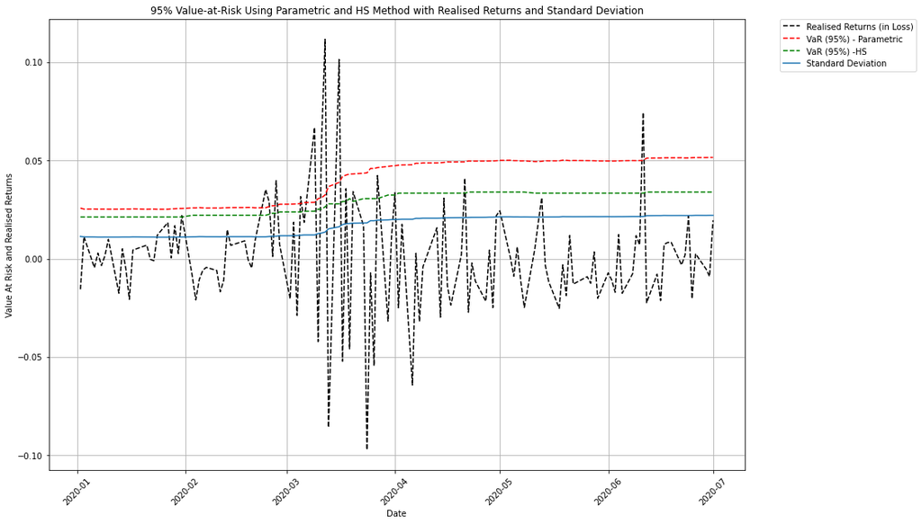

```python
# Plot log returns and SD with VaR
plt.figure(figsize=(15,10))
plt.plot(stocks_param2['Date'], -stocks_param2['log_prev_return'], 'r--', label='Realised Returns (in Loss)', color='black')
plt.plot(stocks_param2['Date'], -stocks_param2['VaR_95_log'], 'r--', label='VaR (95%) - Parametric')
plt.plot(fdmax_VaR_HS['Date'][fdmax_VaR_HS['Date'] >= "2020-01-01"], -fdmax_VaR_HS['log_VaR_95'][fdmax_VaR_HS['Date'] >= "2020-01-01"], 'g--', label='VaR (95%) -HS')
plt.plot(stocks_param2['Date'], stocks_param2['SD'], label='Standard Deviation')
plt.grid(True)
plt.xlabel('Date')
plt.ylabel('Value At Risk and Realised Returns')
plt.legend(bbox_to_anchor=(1.05, 1), loc=2, borderaxespad=0.)
locs, labels = plt.xticks()
plt.setp(labels, rotation=45)
plt.title('95% Value-at-Risk Using Parametric and HS Method with Realised Returns and Standard Deviation')
plt.show()
```

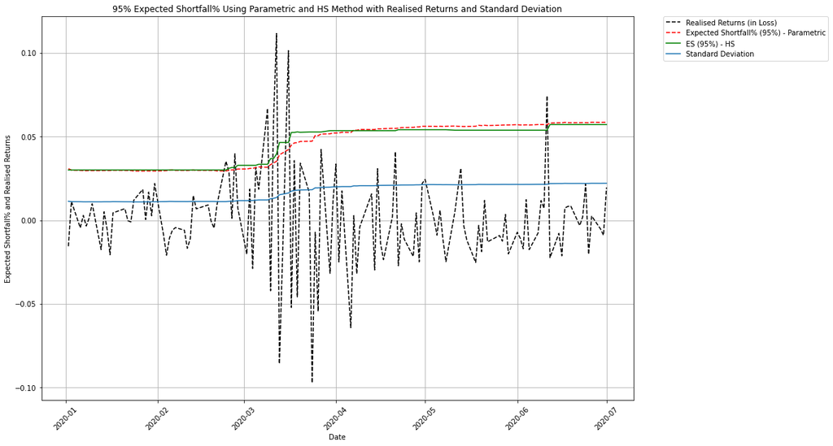

```python
# Plot log returns and SD with ES
plt.figure(figsize=(15,10))
plt.plot(stocks_param2['Date'], -stocks_param2['log_prev_return'], 'r--', label='Realised Returns (in Loss)', color='black')
plt.plot(stocks_es2['Date'], stocks_es2['ES_95_log'], 'r--', label='Expected Shortfall% (95%) - Parametric')
plt.plot(fdmax_HS_ES['Date'][fdmax_HS_ES['Date'] >= "2020-01-01"], -fdmax_HS_ES['log_ES_95'][fdmax_HS_ES['Date'] >= "2020-01-01"], 'g-', label='ES (95%) - HS')
plt.plot(stocks_param2['Date'], stocks_param2['SD'], label='Standard Deviation')
plt.grid(True)
plt.xlabel('Date')
plt.ylabel('Expected Shortfall% and Realised Returns')
plt.legend(bbox_to_anchor=(1.05, 1), loc=2, borderaxespad=0.)
locs, labels = plt.xticks()
plt.setp(labels, rotation=45)
plt.title('95% Expected Shortfall% Using Parametric and HS Method with Realised Returns and Standard Deviation')
plt.show()
```

# Our own portfolio

```python
tickers_opt_string = ["AAPL", "MSFT", "MA", "V", "FIS", "LRCX", "FB", "QCOM", "INTU", "AMD", "MELI", "G", "MDB", "NXPI"]
stocks = get_data_for_multiple_stocks2(tickers_opt_string, start_date = "2019-01-01", end_date = "2020-07-01")

AAPL = stocks['AAPL'].reset_index()
MSFT = stocks['MSFT'].reset_index()
MA = stocks['MA'].reset_index()
V = stocks['V'].reset_index()
FIS = stocks['FIS'].reset_index()
LRCX = stocks['LRCX'].reset_index()
FB = stocks['FB'].reset_index()
QCOM = stocks['QCOM'].reset_index()
INTU = stocks['INTU'].reset_index()
AMD = stocks['AMD'].reset_index()
MELI = stocks['MELI'].reset_index()
G = stocks['G'].reset_index()
MDB = stocks['MDB'].reset_index()
NXPI = stocks['NXPI'].reset_index()

# Transform Date from integer to date type
AAPL['Date'] = AAPL['Date'].apply(str)
AAPL['Date'] = pd.to_datetime(AAPL['Date'], infer_datetime_format=True)

MSFT['Date'] = MSFT['Date'].apply(str)
MSFT['Date'] = pd.to_datetime(MSFT['Date'], infer_datetime_format=True)

MA['Date'] = MA['Date'].apply(str)
MA['Date'] = pd.to_datetime(MA['Date'], infer_datetime_format=True)

V['Date'] = V['Date'].apply(str)
V['Date'] = pd.to_datetime(V['Date'], infer_datetime_format=True)

FIS['Date'] = FIS['Date'].apply(str)
FIS['Date'] = pd.to_datetime(FIS['Date'], infer_datetime_format=True)

LRCX['Date'] = LRCX['Date'].apply(str)
LRCX['Date'] = pd.to_datetime(LRCX['Date'], infer_datetime_format=True)

FB['Date'] = FB['Date'].apply(str)
FB['Date'] = pd.to_datetime(FB['Date'], infer_datetime_format=True)

QCOM['Date'] = QCOM['Date'].apply(str)
QCOM['Date'] = pd.to_datetime(QCOM['Date'], infer_datetime_format=True)

INTU['Date'] = INTU['Date'].apply(str)
INTU['Date'] = pd.to_datetime(INTU['Date'], infer_datetime_format=True)

AMD['Date'] = AMD['Date'].apply(str)
AMD['Date'] = pd.to_datetime(AMD['Date'], infer_datetime_format=True)

MELI['Date'] = MELI['Date'].apply(str)
MELI['Date'] = pd.to_datetime(MELI['Date'], infer_datetime_format=True)

G['Date'] = G['Date'].apply(str)
G['Date'] = pd.to_datetime(G['Date'], infer_datetime_format=True)

MDB['Date'] = MDB['Date'].apply(str)
MDB['Date'] = pd.to_datetime(MDB['Date'], infer_datetime_format=True)

NXPI['Date'] = NXPI['Date'].apply(str)
NXPI['Date'] = pd.to_datetime(NXPI['Date'], infer_datetime_format=True)
```

```python
# Renaming adj_close column
AAPL.rename(columns={'Adj Close':'AAPL_Adj Close'}, inplace=True)
MSFT.rename(columns={'Adj Close':'MSFT_Adj Close'}, inplace=True)
MA.rename(columns={'Adj Close':'MA_Adj Close'}, inplace=True)
V.rename(columns={'Adj Close':'V_Adj Close'}, inplace=True)
FIS.rename(columns={'Adj Close':'FIS_Adj Close'}, inplace=True)
LRCX.rename(columns={'Adj Close':'LRCX_Adj Close'}, inplace=True)
FB.rename(columns={'Adj Close':'FB_Adj Close'}, inplace=True)
QCOM.rename(columns={'Adj Close':'QCOM_Adj Close'}, inplace=True)
INTU.rename(columns={'Adj Close':'INTU_Adj Close'}, inplace=True)
AMD.rename(columns={'Adj Close':'AMD_Adj Close'}, inplace=True)
MELI.rename(columns={'Adj Close':'MELI_Adj Close'}, inplace=True)
G.rename(columns={'Adj Close':'G_Adj Close'}, inplace=True)
MDB.rename(columns={'Adj Close':'MDB_Adj Close'}, inplace=True)
NXPI.rename(columns={'Adj Close':'NXPI_Adj Close'}, inplace=True)
```

```python
# Renaming log_return column
AAPL.rename(columns={'log_return':'AAPL_log_return'}, inplace=True)
MSFT.rename(columns={'log_return':'MSFT_log_return'}, inplace=True)
MA.rename(columns={'log_return':'MA_log_return'}, inplace=True)
V.rename(columns={'log_return':'V_log_return'}, inplace=True)
FIS.rename(columns={'log_return':'FIS_log_return'}, inplace=True)
LRCX.rename(columns={'log_return':'LRCX_log_return'}, inplace=True)
FB.rename(columns={'log_return':'FB_log_return'}, inplace=True)
QCOM.rename(columns={'log_return':'QCOM_log_return'}, inplace=True)
INTU.rename(columns={'log_return':'INTU_log_return'}, inplace=True)
AMD.rename(columns={'log_return':'AMD_log_return'}, inplace=True)
MELI.rename(columns={'log_return':'MELI_log_return'}, inplace=True)
G.rename(columns={'log_return':'G_log_return'}, inplace=True)
MDB.rename(columns={'log_return':'MDB_log_return'}, inplace=True)
NXPI.rename(columns={'log_return':'NXPI_log_return'}, inplace=True)
```

```python
# Create a new dataset for portfolio
dfs = [AAPL, MSFT, MA, V, FIS, LRCX, FB, QCOM, INTU, AMD, MELI, G, MDB, NXPI]
portfolio_opt = reduce(lambda left,right: pd.merge(left,right,on='Date'), dfs)
portfolio_opt = portfolio_opt[['Date', 'AAPL_Adj Close', 'MSFT_Adj Close','MA_Adj Close','V_Adj Close','FIS_Adj Close','LRCX_Adj Close','FB_Adj Close','QCOM_Adj Close','INTU_Adj Close','AMD_Adj Close','MELI_Adj Close','G_Adj Close','MDB_Adj Close','NXPI_Adj Close','AAPL_log_return','MSFT_log_return','MA_log_return','V_log_return','FIS_log_return','LRCX_log_return','FB_log_return','QCOM_log_return','INTU_log_return','AMD_log_return','MELI_log_return','G_log_return','MDB_log_return','NXPI_log_return']]
portfolio_opt['Portfolio_Value'] = portfolio_opt['AAPL_Adj Close']*0.052990 + portfolio_opt['MSFT_Adj Close']*0.092569 + portfolio_opt['MA_Adj Close']*0.156987 + portfolio_opt['V_Adj Close']*0.137560 + portfolio_opt['FIS_Adj Close']*0.074765 + portfolio_opt['LRCX_Adj Close']*0.050595 + portfolio_opt['FB_Adj Close']*0.000872 + portfolio_opt['QCOM_Adj Close']*0.040578 + portfolio_opt['INTU_Adj Close']*0.199530 + portfolio_opt['AMD_Adj Close']*0.045174 + portfolio_opt['MELI_Adj Close']*0.016148 + portfolio_opt['G_Adj Close']*0.044405 + portfolio_opt['MDB_Adj Close']*0.015470 + portfolio_opt['NXPI_Adj Close']*0.072358
portfolio_opt['log_return'] = np.log(portfolio_opt['Portfolio_Value']/portfolio_opt['Portfolio_Value'].shift(1))
```

## Daily Historical VaR

```python
from copy import deepcopy
HS_VaR = deepcopy(portfolio_opt)

for i in range(0, len(HS_VaR)):
    past_250 = HS_VaR.loc[(i-250):(i-1), 'log_return']
    if len(past_250) == 250:
        HS_VaR.loc[i, 'VaR_95_log'] = past_250.quantile(0.05)
    else:
        HS_VaR.loc[i, 'VaR_95_log'] = np.NaN
```

## Daily Historical Simulation ES

```python
import math
from copy import deepcopy
HS_ES = deepcopy(portfolio_opt)

significance = 0.05 # significance level
confidence = 0.95 # confidence level

for i in range(0, len(HS_ES)):
    past_250 = HS_ES.loc[(i-250):(i-1), 'log_return']
    T_days = len(past_250) # Number of past days
    if T_days == 250:

        VaR = past_250.quantile(0.05)
        log_returns_sorted = sorted(past_250.dropna())
        length = len(log_returns_sorted)
        cutoff_rt1_index = math.floor(length*significance+1) - 1 # minus one due to index starting from 0

        sum_rt1 = sum(log_returns_sorted[:cutoff_rt1_index])
        HS_ES.loc[i, 'ES_95_log'] = sum_rt1/len(log_returns_sorted[:cutoff_rt1_index])
    else:
        HS_ES.loc[i, 'ES_95_log'] = np.NaN
```

## Daily Parametric VaR

```python
# optimized weights
weights = np.array([0.052990, 0.092569, 0.156987, 0.137560, 0.074765, 0.050595, 0.000872, 0.040578, 0.199530, 0.045174, 0.016148, 0.044405, 0.015470, 0.072358])
```

```python
from copy import deepcopy
Parametric_VaR = deepcopy(portfolio_opt)

z_alpha = norm.ppf(0.05, loc=0, scale=1) # z-score

for i in range(0, len(Parametric_VaR)):
    past_250_log_returns = Parametric_VaR.loc[(i-250):(i-1), ['AAPL_log_return','MSFT_log_return','MA_log_return','V_log_return','FIS_log_return','LRCX_log_return','FB_log_return','QCOM_log_return','INTU_log_return','AMD_log_return','MELI_log_return','G_log_return','MDB_log_return','NXPI_log_return']]

    if len(past_250_log_returns) == 250:

        # mean
        mean_log_returns = past_250_log_returns.mean()
        mean_arith_returns =  np.exp(mean_log_returns.values) - 1 # convert to arithmetic to find weighted returns
        weighted_arith_returns = np.dot(weights, mean_arith_returns)
        weighted_log_returns = np.log(1 + weighted_arith_returns) # convert back to log

        # sigma
        mat_df = past_250_log_returns.values
        vcv = np.cov(mat_df.T) # variance-covariance matrix
        variance = np.dot(weights, np.dot(vcv, weights))
        sigma = sqrt(variance)

        # Parametric VaR
        Parametric_VaR.loc[i, 'VaR_95_log'] = weighted_log_returns + sigma*z_alpha

    else:
        Parametric_VaR.loc[i, 'VaR_95_log'] = np.NaN
```

## Daily Parametric ES

```python
from copy import deepcopy
Parametric_ES = deepcopy(portfolio_opt)

alpha = 0.05 # significance level
confidence = 0.95 # confidence level

for i in range(0, len(Parametric_ES)):
    past_250_log_returns = Parametric_ES.loc[(i-250):(i-1), ['AAPL_log_return','MSFT_log_return','MA_log_return','V_log_return','FIS_log_return','LRCX_log_return','FB_log_return','QCOM_log_return','INTU_log_return','AMD_log_return','MELI_log_return','G_log_return','MDB_log_return','NXPI_log_return']]

    if len(past_250_log_returns) == 250:

        # mean
        mean_log_returns = past_250_log_returns.mean()
        mean_arith_returns =  np.exp(mean_log_returns.values) - 1 # convert to arithmetic to find weighted returns
        weighted_arith_returns = np.dot(weights, mean_arith_returns)
        weighted_log_returns = np.log(1 + weighted_arith_returns) # convert back to log
        mu = weighted_log_returns

        # sigma
        mat_df = past_250_log_returns.values
        vcv = np.cov(mat_df.T) # variance-covariance matrix
        variance = np.dot(weights, np.dot(vcv, weights))
        sigma = sqrt(variance)

        # Parametric ES
        Parametric_ES.loc[i, 'ES_95_log'] = mu+sigma*norm.pdf(norm.ppf(confidence, loc=0, scale=1), loc=0, scale=1)/(1-confidence)
    else:
        Parametric_ES.loc[i, 'ES_95_log'] = np.NaN
```

```python
portfolio_2020 = portfolio_opt.loc[portfolio_opt['Date'] >= "2020-01-01"]
```

## Standard Deviation

```python
from copy import deepcopy
sd = deepcopy(portfolio_opt)

z_alpha = norm.ppf(0.05, loc=0, scale=1) # z-score

# optimized weights
weights = np.array([0.052990, 0.092569, 0.156987, 0.137560, 0.074765, 0.050595, 0.000872, 0.040578, 0.199530, 0.045174, 0.016148, 0.044405, 0.015470, 0.072358])

for i in range(0, len(sd)):
    past_250_log_returns = sd.loc[(i-250):(i-1), ['AAPL_log_return','MSFT_log_return','MA_log_return','V_log_return','FIS_log_return','LRCX_log_return','FB_log_return','QCOM_log_return','INTU_log_return','AMD_log_return','MELI_log_return','G_log_return','MDB_log_return','NXPI_log_return']]

    if len(past_250_log_returns) == 250:

        mat_df = past_250_log_returns.values
        vcv = np.cov(mat_df.T)
        variance = np.dot(weights, np.dot(vcv, weights))
        sd.loc[i, 'Standard Deviation'] = sqrt(variance)
    else:
        sd.loc[i, 'Standard Deviation'] = np.NaN
```

Plotting the graphs of Log VaR/ES with Realised Returns and Standard Deviation

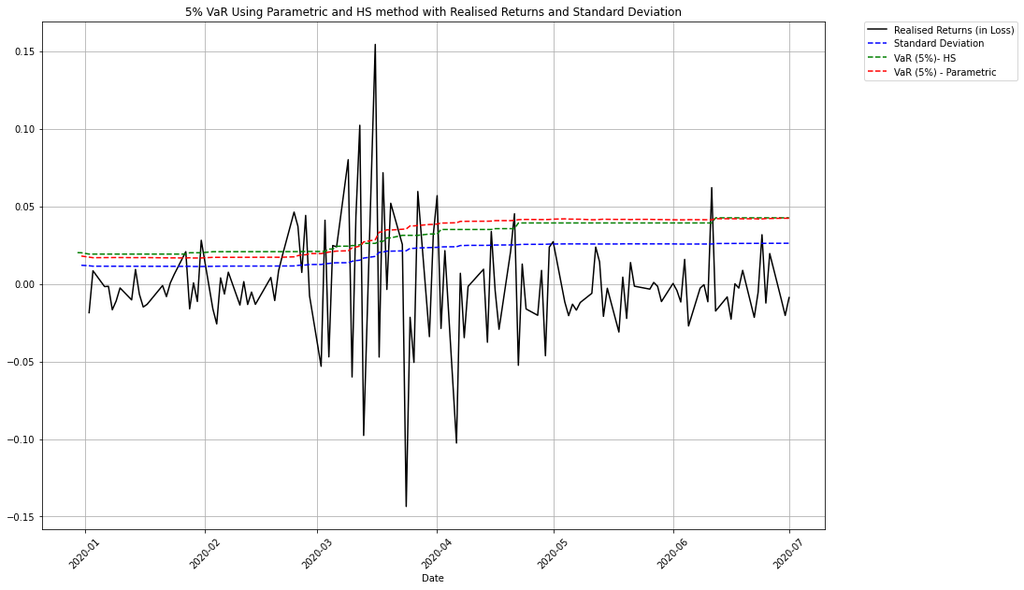

```python
plt.figure(figsize=(15,10))
plt.plot(portfolio_2020['Date'], -portfolio_2020['log_return'], 'black', label='Realised Returns (in Loss)')
plt.plot(sd['Date'], sd['Standard Deviation'], 'b--', label='Standard Deviation')
plt.plot(HS_VaR['Date'], -HS_VaR['VaR_95_log'], 'g--', label='VaR (5%)- HS')
plt.plot(Parametric_VaR['Date'], -Parametric_VaR['VaR_95_log'], 'r--', label='VaR (5%) - Parametric')
plt.grid(True)
plt.xlabel('Date')
plt.legend(bbox_to_anchor=(1.05, 1), loc=2, borderaxespad=0.)
locs, labels = plt.xticks()
plt.setp(labels, rotation=45)
plt.title('5% VaR Using Parametric and HS method with Realised Returns and Standard Deviation')
plt.show()
```

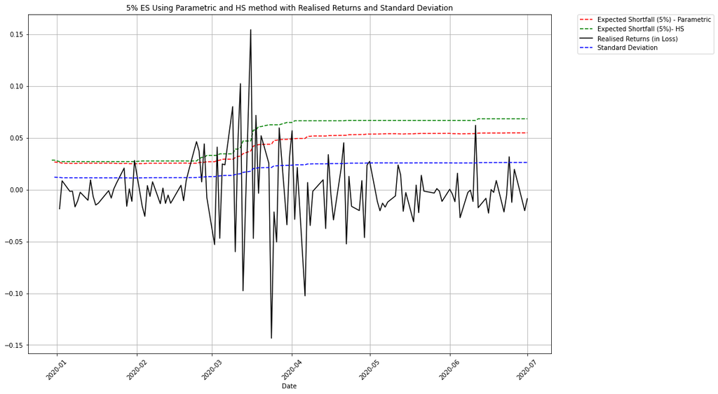

```python
plt.figure(figsize=(15,10))
plt.plot(Parametric_ES['Date'], Parametric_ES['ES_95_log'], 'r--', label='Expected Shortfall (5%) - Parametric')
plt.plot(HS_ES['Date'], -HS_ES['ES_95_log'], 'g--', label='Expected Shortfall (5%)- HS')
plt.plot(portfolio_2020['Date'], -portfolio_2020['log_return'], 'black', label='Realised Returns (in Loss)')
plt.plot(sd['Date'], sd['Standard Deviation'], 'b--', label='Standard Deviation')
plt.grid(True)
plt.xlabel('Date')
plt.legend(bbox_to_anchor=(1.05, 1), loc=2, borderaxespad=0.)
locs, labels = plt.xticks()
plt.setp(labels, rotation=45)
plt.title('5% ES Using Parametric and HS method with Realised Returns and Standard Deviation')
plt.show()
```

# Q7b

### 1-year optimisation (end Sep 2019 - end Sep 2020) for original weights

```python
returns_df_new = get_data_for_multiple_stocks(tickers_new,
                                          start_date = "2019-10-01", end_date = "2020-10-01")
```

```python
portfolio_1yr = (returns_df_new * optimal_weights_new).sum(axis = 1)
portfolio_1yr
```

```
Date
2019-10-02   -0.018508
2019-10-03    0.012176
2019-10-04    0.017101
2019-10-07   -0.005453
2019-10-08   -0.021096
                ...
2020-09-25    0.019229
2020-09-28    0.019472
2020-09-29   -0.003271
2020-09-30    0.004673
2020-10-01    0.016957
Length: 253, dtype: float64
```

Sharpe Ratio

```python
oos_results = portfolio_1yr.iloc[1:]
ax = round(oos_results.mean(axis = 0)/oos_results.std(axis = 0) * 252 ** 0.5, 2)
ax
```

```
0.82
```

Annualised Return in %

```python
portfolio_1yr_arith = sum(np.exp(portfolio_1yr) - 1)
portfolio_1yr_arith*100
```

```
41.07320782101166
```

Annualised Standard Deviation in %

```python
np.std(np.exp(portfolio_1yr) - 1)*np.sqrt(252)*100
```

```
41.463390078336985
```

### 1-year optimisation (end Sep 2019 - end Sep 2020) for adjusted weights

```python
# adjusted weights
weights = np.array([0.0609385, 0.1295966, 0, 0, 0, 0.133439, 0, 0.137560, 0, 0.074765, 0.070833, 0.055655, 0, 0.040578, 0, 0, 0, 0.119718, 0, 0.038398, 0, 0.016148, 0, 0.044405, 0, 0, 0.015470, 0.072358, 0, 0])
```

```python
returns_df_new_adj = get_data_for_multiple_stocks(tickers_new,
                                          start_date = "2019-10-01", end_date = "2020-10-01")
```

```python
weights_normalised = []
```

```python
# normalising weights
weights_sum = sum(weights)

for i in weights:
  i = i/weights_sum
  weights_normalised.append(i)
```

```python
portfolio_1yr = (returns_df_new_adj * weights_normalised).sum(axis = 1)
portfolio_1yr
```

```
Date
2019-10-02   -0.017935
2019-10-03    0.012931
2019-10-04    0.016539
2019-10-07   -0.005718
2019-10-08   -0.020039
                ...
2020-09-25    0.018539
2020-09-28    0.018246
2020-09-29   -0.002076
2020-09-30    0.004173
2020-10-01    0.016581
Length: 253, dtype: float64
```

Sharpe Ratio

```python
oos_results = portfolio_1yr.iloc[1:]
ax = round(oos_results.mean(axis = 0)/oos_results.std(axis = 0) * 252 ** 0.5, 2)
ax
```

```
0.87
```

Annualised Return in %

```python
portfolio_1yr_arith = sum(np.exp(portfolio_1yr) - 1)
portfolio_1yr_arith*100
```

```
42.76554233559852
```

Annualised Standard Deviation in %

```python
np.std(np.exp(portfolio_1yr) - 1)*np.sqrt(252)*100
```

```
41.10047132861822
```